# Household - Logit GLM

## Import Data, Packages

```python
import pandas as pd #Dataframes
import numpy as np #Operations
import matplotlib.pyplot as plt #Graphs
from matplotlib.pyplot import figure
pd.set_option('display.max_columns', None)
```

```python
df = pd.read_excel ("home_insurance.xlsx", sheet_name="home_insurance") #Directory to latest version of data
```

```python
df.head(5)
```

|  | QUOTE_DATE | COVER_START | CLAIM3YEARS | P1_EMP_STATUS | P1_PT_EMP_STATUS | BUS_USE | CLERICAL | AD_BUILDINGS | RISK_RATED_AREA_B | SUM_INSURED_BUILDINGS | NCD_GRANTED_YEARS_B | AD_CONTENTS | RISK_RATED_AREA_C | SUM_INSURED_CONTENTS | NCD_GRANTED_YEARS_C | CONTENTS_COVER | BUILDINGS_COVER | SPEC_SUM_INSURED | SPEC_ITEM_PREM | UNSPEC_HRP_PREM | P1_DOB | P1_MAR_STATUS | P1_POLICY_REFUSED | P1_SEX | APPR_ALARM | APPR_LOCKS | BEDROOMS | ROOF_CONSTRUCTION | WALL_CONSTRUCTION | … |
| --- | --- | --- | --- | --- | --- | --- | --- | --- | --- | --- | --- | --- | --- | --- | --- | --- | --- | --- | --- | --- | --- | --- | --- | --- | --- | --- | --- | --- | --- | --- |
| 0 | 11/22/2007 | 22/11/2007 | N | R | NaN | N | NaN | Y | 19.0 | 1000000.0 | 7.0 | Y | 6.0 | 50000.0 | 7.0 | Y | Y | 7500.0 | 44.42 | 12.45 | 15/06/1939 | O | N | M | N | Y | 3.0 | 11.0 | 15.0 | … |
| 1 | 11/22/2007 | 01/01/2008 | N | E | NaN | Y | N | Y | 25.0 | 1000000.0 | 6.0 | Y | 9.0 | 50000.0 | 7.0 | Y | Y | 0.0 | 0.00 | 44006.00 | 20/05/1970 | M | N | M | N | N | 3.0 | 11.0 | 15.0 | … |
| 2 | 11/23/2007 | 23/11/2007 | N | E | NaN | N | NaN | N | NaN | 0.0 | 0.0 | Y | 12.0 | 50000.0 | 7.0 | N | Y | 0.0 | 0.00 | 0.00 | 10/06/1947 | S | N | M | Y | Y | 2.0 | 11.0 | 15.0 | … |
| 3 | 11/23/2007 | 12/12/2007 | N | R | NaN | N | NaN | N | NaN | 0.0 | 0.0 | Y | 14.0 | 50000.0 | 7.0 | N | Y | 0.0 | 0.00 | 0.00 | 16/12/1925 | W | N | F | N | Y | 2.0 | 11.0 | 15.0 | … |
| 4 | 11/22/2007 | 15/12/2007 | N | R | NaN | N | NaN | Y | 5.0 | 1000000.0 | 7.0 | Y | 10.0 | 50000.0 | 7.0 | Y | Y | 0.0 | 0.00 | 19.82 | 11/02/1936 | M | N | M | Y | Y | 3.0 | 11.0 | 15.0 | … |

```python
df.shape
```

```
(256136, 66)
```

```python
df.isnull().sum().nlargest(60)
```

```
CAMPAIGN_DESC             256136
P1_PT_EMP_STATUS          254354
CLERICAL                  253192
MTA_DATE                  229561
MTA_FAP                   200416
MTA_APRP                  200416
PAYMENT_FREQUENCY         175582
QUOTE_DATE                126612
RISK_RATED_AREA_B         115260
RISK_RATED_AREA_C          75846
COVER_START                67115
P1_EMP_STATUS              67115
BUS_USE                    67115
AD_BUILDINGS               67115
SUM_INSURED_BUILDINGS      67115
NCD_GRANTED_YEARS_B        67115
AD_CONTENTS                67115
SUM_INSURED_CONTENTS       67115
NCD_GRANTED_YEARS_C        67115
CONTENTS_COVER             67115
BUILDINGS_COVER            67115
SPEC_SUM_INSURED           67115
SPEC_ITEM_PREM             67115
UNSPEC_HRP_PREM            67115
P1_DOB                     67115
P1_MAR_STATUS              67115
P1_POLICY_REFUSED          67115
P1_SEX                     67115
APPR_ALARM                 67115
APPR_LOCKS                 67115
BEDROOMS                   67115
ROOF_CONSTRUCTION          67115
WALL_CONSTRUCTION          67115
FLOODING                   67115
LISTED                     67115
MAX_DAYS_UNOCC             67115
NEIGH_WATCH                67115
OCC_STATUS                 67115
OWNERSHIP_TYPE             67115
PAYING_GUESTS              67115
PROP_TYPE                  67115
SAFE_INSTALLED             67115
SEC_DISC_REQ               67115
SUBSIDENCE                 67115
YEARBUILT                  67115
PAYMENT_METHOD             67115
LEGAL_ADDON_PRE_REN        67115
LEGAL_ADDON_POST_REN       67115
HOME_EM_ADDON_PRE_REN      67115
HOME_EM_ADDON_POST_REN     67115
GARDEN_ADDON_PRE_REN       67115
GARDEN_ADDON_POST_REN      67115
KEYCARE_ADDON_PRE_REN      67115
KEYCARE_ADDON_POST_REN     67115
HP1_ADDON_PRE_REN          67115
HP1_ADDON_POST_REN         67115
HP2_ADDON_PRE_REN          67115
HP2_ADDON_POST_REN         67115
HP3_ADDON_PRE_REN          67115
HP3_ADDON_POST_REN         67115
dtype: int64
```

```python
df['COVER_START'].describe()
```

```
count         189021
unique          2207
top       01/03/2011
freq            3510
Name: COVER_START, dtype: object
```

```python
df.PAYMENT_METHOD.unique()
```

```
array(['PureDD', 'NonDD', 'DD-Other', nan], dtype=object)
```

```python
df['MTA_DATE'] = pd.to_datetime(df['MTA_DATE'])
```

```python
df.head(3)
```

|  | QUOTE_DATE | COVER_START | CLAIM3YEARS | P1_EMP_STATUS | P1_PT_EMP_STATUS | BUS_USE | CLERICAL | AD_BUILDINGS | RISK_RATED_AREA_B | SUM_INSURED_BUILDINGS | NCD_GRANTED_YEARS_B | AD_CONTENTS | RISK_RATED_AREA_C | SUM_INSURED_CONTENTS | NCD_GRANTED_YEARS_C | CONTENTS_COVER | BUILDINGS_COVER | SPEC_SUM_INSURED | SPEC_ITEM_PREM | UNSPEC_HRP_PREM | P1_DOB | P1_MAR_STATUS | P1_POLICY_REFUSED | P1_SEX | APPR_ALARM | APPR_LOCKS | BEDROOMS | ROOF_CONSTRUCTION | WALL_CONSTRUCTION | … |
| --- | --- | --- | --- | --- | --- | --- | --- | --- | --- | --- | --- | --- | --- | --- | --- | --- | --- | --- | --- | --- | --- | --- | --- | --- | --- | --- | --- | --- | --- | --- |
| 0 | 11/22/2007 | 22/11/2007 | N | R | NaN | N | NaN | Y | 19.0 | 1000000.0 | 7.0 | Y | 6.0 | 50000.0 | 7.0 | Y | Y | 7500.0 | 44.42 | 12.45 | 15/06/1939 | O | N | M | N | Y | 3.0 | 11.0 | 15.0 | … |
| 1 | 11/22/2007 | 01/01/2008 | N | E | NaN | Y | N | Y | 25.0 | 1000000.0 | 6.0 | Y | 9.0 | 50000.0 | 7.0 | Y | Y | 0.0 | 0.00 | 44006.00 | 20/05/1970 | M | N | M | N | N | 3.0 | 11.0 | 15.0 | … |
| 2 | 11/23/2007 | 23/11/2007 | N | E | NaN | N | NaN | N | NaN | 0.0 | 0.0 | Y | 12.0 | 50000.0 | 7.0 | N | Y | 0.0 | 0.00 | 0.00 | 10/06/1947 | S | N | M | Y | Y | 2.0 | 11.0 | 15.0 | … |

```python
print(df['MTA_DATE'].min(), df['MTA_DATE'].max())
```

```
2006-12-17 00:00:00 2012-11-01 00:00:00
```

## Initial Data Check & Data Cleaning

#### Keep only desired variables

```python
# I just pick 32 variables of different datatypes (numerical, categorical, dates) for demonstrative purposes

data_0 = df[['COVER_START', 'CLAIM3YEARS', 'P1_EMP_STATUS', 'AD_BUILDINGS', 'RISK_RATED_AREA_B', 'NCD_GRANTED_YEARS_B', 'AD_CONTENTS', 'SUM_INSURED_CONTENTS', 'CONTENTS_COVER', 'BUILDINGS_COVER', 'SPEC_SUM_INSURED', 'SPEC_ITEM_PREM', 'P1_DOB', 'P1_MAR_STATUS', 'P1_SEX', 'APPR_ALARM', 'APPR_LOCKS', 'BEDROOMS', 'ROOF_CONSTRUCTION', 'WALL_CONSTRUCTION', 'FLOODING', 'LISTED', 'PROP_TYPE', 'SAFE_INSTALLED', 'YEARBUILT', 'PAYMENT_METHOD', 'HOME_EM_ADDON_PRE_REN', 'HOME_EM_ADDON_POST_REN', 'MTA_FLAG', 'LAST_ANN_PREM_GROSS', 'POL_STATUS', 'Police'
]]
```

```python
data_0.shape
```

```
(256136, 32)
```

```python
data_0.isnull().sum()
```

```
COVER_START                67115
CLAIM3YEARS                66097
P1_EMP_STATUS              67115
AD_BUILDINGS               67115
RISK_RATED_AREA_B         115260
NCD_GRANTED_YEARS_B        67115
AD_CONTENTS                67115
SUM_INSURED_CONTENTS       67115
CONTENTS_COVER             67115
BUILDINGS_COVER            67115
SPEC_SUM_INSURED           67115
SPEC_ITEM_PREM             67115
P1_DOB                     67115
P1_MAR_STATUS              67115
P1_SEX                     67115
APPR_ALARM                 67115
APPR_LOCKS                 67115
BEDROOMS                   67115
ROOF_CONSTRUCTION          67115
WALL_CONSTRUCTION          67115
FLOODING                   67115
LISTED                     67115
PROP_TYPE                  67115
SAFE_INSTALLED             67115
YEARBUILT                  67115
PAYMENT_METHOD             67115
HOME_EM_ADDON_PRE_REN      67115
HOME_EM_ADDON_POST_REN     67115
MTA_FLAG                   66097
LAST_ANN_PREM_GROSS        66097
POL_STATUS                 67115
Police                         0
dtype: int64
```

```python
data_0.dtypes
```

```
COVER_START                object
CLAIM3YEARS                object
P1_EMP_STATUS              object
AD_BUILDINGS               object
RISK_RATED_AREA_B         float64
NCD_GRANTED_YEARS_B       float64
AD_CONTENTS                object
SUM_INSURED_CONTENTS      float64
CONTENTS_COVER             object
BUILDINGS_COVER            object
SPEC_SUM_INSURED          float64
SPEC_ITEM_PREM            float64
P1_DOB                     object
P1_MAR_STATUS              object
P1_SEX                     object
APPR_ALARM                 object
APPR_LOCKS                 object
BEDROOMS                  float64
ROOF_CONSTRUCTION         float64
WALL_CONSTRUCTION         float64
FLOODING                   object
LISTED                    float64
PROP_TYPE                 float64
SAFE_INSTALLED             object
YEARBUILT                 float64
PAYMENT_METHOD             object
HOME_EM_ADDON_PRE_REN      object
HOME_EM_ADDON_POST_REN     object
MTA_FLAG                   object
LAST_ANN_PREM_GROSS       float64
POL_STATUS                 object
Police                     object
dtype: object
```

```python
#Changing the data type to object

data = data_0.copy()

data['RISK_RATED_AREA_B'] = data['RISK_RATED_AREA_B'].astype(object)
data['ROOF_CONSTRUCTION'] = data['ROOF_CONSTRUCTION'].astype(object)
data['WALL_CONSTRUCTION'] = data['WALL_CONSTRUCTION'].astype(object)
data['LISTED'] = data['LISTED'].astype(object)
data['PROP_TYPE'] = data['PROP_TYPE'].astype(object)

data.head(3)
```

|  | COVER_START | CLAIM3YEARS | P1_EMP_STATUS | AD_BUILDINGS | RISK_RATED_AREA_B | NCD_GRANTED_YEARS_B | AD_CONTENTS | SUM_INSURED_CONTENTS | CONTENTS_COVER | BUILDINGS_COVER | SPEC_SUM_INSURED | SPEC_ITEM_PREM | P1_DOB | P1_MAR_STATUS | P1_SEX | APPR_ALARM | APPR_LOCKS | BEDROOMS | ROOF_CONSTRUCTION | WALL_CONSTRUCTION | FLOODING | LISTED | PROP_TYPE | SAFE_INSTALLED | YEARBUILT | PAYMENT_METHOD | HOME_EM_ADDON_PRE_REN | HOME_EM_ADDON_POST_REN | MTA_FLAG | … |
| --- | --- | --- | --- | --- | --- | --- | --- | --- | --- | --- | --- | --- | --- | --- | --- | --- | --- | --- | --- | --- | --- | --- | --- | --- | --- | --- | --- | --- | --- | --- |
| 0 | 22/11/2007 | N | R | Y | 19 | 7.0 | Y | 50000.0 | Y | Y | 7500.0 | 44.42 | 15/06/1939 | O | M | N | Y | 3.0 | 11 | 15 | Y | 3 | 10 | Y | 1960.0 | PureDD | N | N | N | … |
| 1 | 01/01/2008 | N | E | Y | 25 | 6.0 | Y | 50000.0 | Y | Y | 0.0 | 0.00 | 20/05/1970 | M | M | N | N | 3.0 | 11 | 15 | Y | 3 | 2 | N | 1960.0 | PureDD | N | N | Y | … |
| 2 | 23/11/2007 | N | E | N | NaN | 0.0 | Y | 50000.0 | N | Y | 0.0 | 0.00 | 10/06/1947 | S | M | Y | Y | 2.0 | 11 | 15 | Y | 3 | 9 | N | 1946.0 | PureDD | N | N | Y | … |

```python
data.dtypes
```

```
COVER_START                object
CLAIM3YEARS                object
P1_EMP_STATUS              object
AD_BUILDINGS               object
RISK_RATED_AREA_B          object
NCD_GRANTED_YEARS_B       float64
AD_CONTENTS                object
SUM_INSURED_CONTENTS      float64
CONTENTS_COVER             object
BUILDINGS_COVER            object
SPEC_SUM_INSURED          float64
SPEC_ITEM_PREM            float64
P1_DOB                     object
P1_MAR_STATUS              object
P1_SEX                     object
APPR_ALARM                 object
APPR_LOCKS                 object
BEDROOMS                  float64
ROOF_CONSTRUCTION          object
WALL_CONSTRUCTION          object
FLOODING                   object
LISTED                     object
PROP_TYPE                  object
SAFE_INSTALLED             object
YEARBUILT                 float64
PAYMENT_METHOD             object
HOME_EM_ADDON_PRE_REN      object
HOME_EM_ADDON_POST_REN     object
MTA_FLAG                   object
LAST_ANN_PREM_GROSS       float64
POL_STATUS                 object
Police                     object
dtype: object
```

#### Restrictions on our Dataset

```python
# We filter out contracts that have been lapsed or unknown
data = data[(data['POL_STATUS'] == "Live") | (data['POL_STATUS'] == "Cancelled")]
```

```python
data.shape
```

```
(136471, 32)
```

#### Detecting missing values

```python
data.isnull().sum()
```

```
COVER_START                   0
CLAIM3YEARS                   0
P1_EMP_STATUS                 0
AD_BUILDINGS                  0
RISK_RATED_AREA_B         39148
NCD_GRANTED_YEARS_B           0
AD_CONTENTS                   0
SUM_INSURED_CONTENTS          0
CONTENTS_COVER                0
BUILDINGS_COVER               0
SPEC_SUM_INSURED              0
SPEC_ITEM_PREM                0
P1_DOB                        0
P1_MAR_STATUS                 0
P1_SEX                        0
APPR_ALARM                    0
APPR_LOCKS                    0
BEDROOMS                      0
ROOF_CONSTRUCTION             0
WALL_CONSTRUCTION             0
FLOODING                      0
LISTED                        0
PROP_TYPE                     0
SAFE_INSTALLED                0
YEARBUILT                     0
PAYMENT_METHOD                0
HOME_EM_ADDON_PRE_REN         0
HOME_EM_ADDON_POST_REN        0
MTA_FLAG                      0
LAST_ANN_PREM_GROSS           0
POL_STATUS                    0
Police                        0
dtype: int64
```

```python
data[data['RISK_RATED_AREA_B'].isnull()].head(5)
```

|  | COVER_START | CLAIM3YEARS | P1_EMP_STATUS | AD_BUILDINGS | RISK_RATED_AREA_B | NCD_GRANTED_YEARS_B | AD_CONTENTS | SUM_INSURED_CONTENTS | CONTENTS_COVER | BUILDINGS_COVER | SPEC_SUM_INSURED | SPEC_ITEM_PREM | P1_DOB | P1_MAR_STATUS | P1_SEX | APPR_ALARM | APPR_LOCKS | BEDROOMS | ROOF_CONSTRUCTION | WALL_CONSTRUCTION | FLOODING | LISTED | PROP_TYPE | SAFE_INSTALLED | YEARBUILT | PAYMENT_METHOD | HOME_EM_ADDON_PRE_REN | HOME_EM_ADDON_POST_REN | MTA_FLAG | … |
| --- | --- | --- | --- | --- | --- | --- | --- | --- | --- | --- | --- | --- | --- | --- | --- | --- | --- | --- | --- | --- | --- | --- | --- | --- | --- | --- | --- | --- | --- | --- |
| 2 | 23/11/2007 | N | E | N | NaN | 0.0 | Y | 50000.0 | N | Y | 0.0 | 0.0 | 10/06/1947 | S | M | Y | Y | 2.0 | 11 | 15 | Y | 3 | 9 | N | 1946.0 | PureDD | N | N | Y | … |
| 3 | 12/12/2007 | N | R | N | NaN | 0.0 | Y | 50000.0 | N | Y | 0.0 | 0.0 | 16/12/1925 | W | F | N | Y | 2.0 | 11 | 15 | Y | 3 | 19 | N | 1870.0 | NonDD | N | N | N | … |
| 5 | 01/12/2007 | N | R | N | NaN | 0.0 | Y | 50000.0 | N | Y | 0.0 | 0.0 | 03/09/1935 | M | M | N | N | 1.0 | 11 | 15 | Y | 3 | 7 | N | 1960.0 | PureDD | N | N | N | … |
| 7 | 01/12/2007 | N | R | N | NaN | 0.0 | Y | 50000.0 | N | Y | 0.0 | 0.0 | 24/05/1922 | M | M | N | Y | 2.0 | 11 | 15 | Y | 3 | 7 | N | 1990.0 | DD-Other | N | N | N | … |
| 12 | 30/12/2007 | N | E | N | NaN | 0.0 | Y | 50000.0 | N | Y | 0.0 | 0.0 | 29/09/1946 | M | F | N | Y | 3.0 | 11 | 15 | Y | 3 | 1 | N | 1960.0 | NonDD | N | N | N | … |

```python
# Evolution of the database

print(df.shape)
print(data_0.shape)
print(data.shape)
```

```
(256136, 66)
(256136, 32)
(136471, 32)
```

#### Check for duplicated rows

```python
print('# of rows in the database = ', len(data))
data[data.duplicated()]
#data.drop_duplicates(keep='first',inplace=True) #Getting rid of duplicates if they are present
```

```
# of rows in the database =  136471
```

|  | COVER_START | CLAIM3YEARS | P1_EMP_STATUS | AD_BUILDINGS | RISK_RATED_AREA_B | NCD_GRANTED_YEARS_B | AD_CONTENTS | SUM_INSURED_CONTENTS | CONTENTS_COVER | BUILDINGS_COVER | SPEC_SUM_INSURED | SPEC_ITEM_PREM | P1_DOB | P1_MAR_STATUS | P1_SEX | APPR_ALARM | APPR_LOCKS | BEDROOMS | ROOF_CONSTRUCTION | WALL_CONSTRUCTION | FLOODING | LISTED | PROP_TYPE | SAFE_INSTALLED | YEARBUILT | PAYMENT_METHOD | HOME_EM_ADDON_PRE_REN | HOME_EM_ADDON_POST_REN | MTA_FLAG | … |
| --- | --- | --- | --- | --- | --- | --- | --- | --- | --- | --- | --- | --- | --- | --- | --- | --- | --- | --- | --- | --- | --- | --- | --- | --- | --- | --- | --- | --- | --- | --- |

#### Define Target

```python
# Define targeted variable ("Cancelled" contracts) into 0/1 and convert to numerical var

data.loc[data['POL_STATUS'] == "Cancelled", 'label'] = 1
data.loc[data['POL_STATUS'] == "Live", 'label'] = 0
```

```python
data.head(10)
```

|  | COVER_START | CLAIM3YEARS | P1_EMP_STATUS | AD_BUILDINGS | RISK_RATED_AREA_B | NCD_GRANTED_YEARS_B | AD_CONTENTS | SUM_INSURED_CONTENTS | CONTENTS_COVER | BUILDINGS_COVER | SPEC_SUM_INSURED | SPEC_ITEM_PREM | P1_DOB | P1_MAR_STATUS | P1_SEX | APPR_ALARM | APPR_LOCKS | BEDROOMS | ROOF_CONSTRUCTION | WALL_CONSTRUCTION | FLOODING | LISTED | PROP_TYPE | SAFE_INSTALLED | YEARBUILT | PAYMENT_METHOD | HOME_EM_ADDON_PRE_REN | HOME_EM_ADDON_POST_REN | MTA_FLAG | … |
| --- | --- | --- | --- | --- | --- | --- | --- | --- | --- | --- | --- | --- | --- | --- | --- | --- | --- | --- | --- | --- | --- | --- | --- | --- | --- | --- | --- | --- | --- | --- |
| 1 | 01/01/2008 | N | E | Y | 25 | 6.0 | Y | 50000.0 | Y | Y | 0.0 | 0.0 | 20/05/1970 | M | M | N | N | 3.0 | 11 | 15 | Y | 3 | 2 | N | 1960.0 | PureDD | N | N | Y | … |
| 2 | 23/11/2007 | N | E | N | NaN | 0.0 | Y | 50000.0 | N | Y | 0.0 | 0.0 | 10/06/1947 | S | M | Y | Y | 2.0 | 11 | 15 | Y | 3 | 9 | N | 1946.0 | PureDD | N | N | Y | … |
| 3 | 12/12/2007 | N | R | N | NaN | 0.0 | Y | 50000.0 | N | Y | 0.0 | 0.0 | 16/12/1925 | W | F | N | Y | 2.0 | 11 | 15 | Y | 3 | 19 | N | 1870.0 | NonDD | N | N | N | … |
| 4 | 15/12/2007 | N | R | Y | 5 | 7.0 | Y | 50000.0 | Y | Y | 0.0 | 0.0 | 11/02/1936 | M | M | Y | Y | 3.0 | 11 | 15 | Y | 3 | 1 | N | 1960.0 | DD-Other | N | N | N | … |
| 5 | 01/12/2007 | N | R | N | NaN | 0.0 | Y | 50000.0 | N | Y | 0.0 | 0.0 | 03/09/1935 | M | M | N | N | 1.0 | 11 | 15 | Y | 3 | 7 | N | 1960.0 | PureDD | N | N | N | … |
| 6 | 12/12/2007 | N | R | Y | 1 | 7.0 | Y | 50000.0 | Y | Y | 0.0 | 0.0 | 06/01/1930 | D | F | N | Y | 2.0 | 11 | 15 | Y | 3 | 9 | N | 1980.0 | NonDD | N | N | Y | … |
| 7 | 01/12/2007 | N | R | N | NaN | 0.0 | Y | 50000.0 | N | Y | 0.0 | 0.0 | 24/05/1922 | M | M | N | Y | 2.0 | 11 | 15 | Y | 3 | 7 | N | 1990.0 | DD-Other | N | N | N | … |
| 8 | 01/02/2008 | N | E | Y | 0 | 3.0 | Y | 50000.0 | Y | Y | 0.0 | 0.0 | 06/10/1947 | P | M | N | Y | 3.0 | 11 | 15 | Y | 3 | 19 | N | 1960.0 | PureDD | Y | N | Y | … |
| 9 | 01/12/2007 | N | E | Y | 5 | 7.0 | Y | 50000.0 | Y | Y | 0.0 | 0.0 | 29/09/1953 | S | M | N | Y | 3.0 | 11 | 15 | Y | 3 | 10 | N | 1946.0 | PureDD | N | N | N | … |
| 10 | 07/12/2007 | N | R | Y | 1 | 7.0 | Y | 50000.0 | Y | Y | 0.0 | 0.0 | 04/03/1935 | M | M | N | N | 2.0 | 11 | 15 | Y | 3 | 10 | N | 2000.0 | PureDD | Y | N | Y | … |

#### Build new variables from existing columns

```python
import datetime
d1 = datetime.date(2012, 12, 31)
d2 = datetime.date(2000, 1, 1)
print(d1 - d2)
```

```
4748 days, 0:00:00
```

```python
from datetime import date
qd = date.fromisoformat('2012-12-31')
print(qd)
```

```
2012-12-31
```

```python
QueryDate = pd.to_datetime(qd)
display(QueryDate)
```

```
Timestamp('2012-12-31 00:00:00')
```

```python
data['COVER_START'] = pd.to_datetime(data['COVER_START'])
```

```python
data['P1_DOB'] = pd.to_datetime(data['P1_DOB'])
```

```python
data['YEARBUILT'] = pd.to_datetime(data['YEARBUILT'], format='%Y')

#df.index = pd.to_datetime(df.index, format='%Y')
```

```python
data.dtypes
```

```
COVER_START               datetime64[ns]
CLAIM3YEARS                       object
P1_EMP_STATUS                     object
AD_BUILDINGS                      object
RISK_RATED_AREA_B                 object
NCD_GRANTED_YEARS_B              float64
AD_CONTENTS                       object
SUM_INSURED_CONTENTS             float64
CONTENTS_COVER                    object
BUILDINGS_COVER                   object
SPEC_SUM_INSURED                 float64
SPEC_ITEM_PREM                   float64
P1_DOB                    datetime64[ns]
P1_MAR_STATUS                     object
P1_SEX                            object
APPR_ALARM                        object
APPR_LOCKS                        object
BEDROOMS                         float64
ROOF_CONSTRUCTION                 object
WALL_CONSTRUCTION                 object
FLOODING                          object
LISTED                            object
PROP_TYPE                         object
SAFE_INSTALLED                    object
YEARBUILT                 datetime64[ns]
PAYMENT_METHOD                    object
HOME_EM_ADDON_PRE_REN             object
HOME_EM_ADDON_POST_REN            object
MTA_FLAG                          object
LAST_ANN_PREM_GROSS              float64
POL_STATUS                        object
Police                            object
label                            float64
dtype: object
```

```python
# Calculating age of contract
from datetime import datetime, date

data['AgeOfContract']=(QueryDate-data['COVER_START'])/365
data['AgeOfContract']=data['AgeOfContract'].dt.days
```

```python
# Calculating age of insured person
from datetime import datetime, date

data['AgeOfInsured']=(QueryDate-data['P1_DOB'])/365
data['AgeOfInsured']=data['AgeOfInsured'].dt.days
```

```python
# Calculating age of building
from datetime import datetime, date

data['AgeOfBuilding']=(QueryDate-data['YEARBUILT'])/365
data['AgeOfBuilding']=data['AgeOfBuilding'].dt.days
```

```python
data.head(5)
```

|  | COVER_START | CLAIM3YEARS | P1_EMP_STATUS | AD_BUILDINGS | RISK_RATED_AREA_B | NCD_GRANTED_YEARS_B | AD_CONTENTS | SUM_INSURED_CONTENTS | CONTENTS_COVER | BUILDINGS_COVER | SPEC_SUM_INSURED | SPEC_ITEM_PREM | P1_DOB | P1_MAR_STATUS | P1_SEX | APPR_ALARM | APPR_LOCKS | BEDROOMS | ROOF_CONSTRUCTION | WALL_CONSTRUCTION | FLOODING | LISTED | PROP_TYPE | SAFE_INSTALLED | YEARBUILT | PAYMENT_METHOD | HOME_EM_ADDON_PRE_REN | HOME_EM_ADDON_POST_REN | MTA_FLAG | … |
| --- | --- | --- | --- | --- | --- | --- | --- | --- | --- | --- | --- | --- | --- | --- | --- | --- | --- | --- | --- | --- | --- | --- | --- | --- | --- | --- | --- | --- | --- | --- |
| 1 | 2008-01-01 | N | E | Y | 25 | 6.0 | Y | 50000.0 | Y | Y | 0.0 | 0.0 | 1970-05-20 | M | M | N | N | 3.0 | 11 | 15 | Y | 3 | 2 | N | 1960-01-01 | PureDD | N | N | Y | … |
| 2 | 2007-11-23 | N | E | N | NaN | 0.0 | Y | 50000.0 | N | Y | 0.0 | 0.0 | 1947-10-06 | S | M | Y | Y | 2.0 | 11 | 15 | Y | 3 | 9 | N | 1946-01-01 | PureDD | N | N | Y | … |
| 3 | 2007-12-12 | N | R | N | NaN | 0.0 | Y | 50000.0 | N | Y | 0.0 | 0.0 | 1925-12-16 | W | F | N | Y | 2.0 | 11 | 15 | Y | 3 | 19 | N | 1870-01-01 | NonDD | N | N | N | … |
| 4 | 2007-12-15 | N | R | Y | 5 | 7.0 | Y | 50000.0 | Y | Y | 0.0 | 0.0 | 1936-11-02 | M | M | Y | Y | 3.0 | 11 | 15 | Y | 3 | 1 | N | 1960-01-01 | DD-Other | N | N | N | … |
| 5 | 2007-01-12 | N | R | N | NaN | 0.0 | Y | 50000.0 | N | Y | 0.0 | 0.0 | 1935-03-09 | M | M | N | N | 1.0 | 11 | 15 | Y | 3 | 7 | N | 1960-01-01 | PureDD | N | N | N | … |

```python
data.AgeOfBuilding.describe()
```

```
count    136471.000000
mean         67.668977
std          28.253993
min          13.000000
25%          53.000000
50%          67.000000
75%          93.000000
max         264.000000
Name: AgeOfBuilding, dtype: float64
```

```python
data['AgeOfContract'].describe()
```

```
count    136471.000000
mean          5.500238
std           4.086894
min           0.000000
25%           2.000000
50%           4.000000
75%           8.000000
max          20.000000
Name: AgeOfContract, dtype: float64
```

```python
data.AgeOfContract.unique()
```

```
array([ 5,  4,  1,  7,  8,  9,  6, 11, 10, 12,  3, 13, 17, 14, 15,  2, 16,
       19, 18, 20,  0], dtype=int64)
```

```python
data['AgeOfInsured'].describe()
```

```
count    136471.000000
mean         73.065149
std          11.078016
min          21.000000
25%          65.000000
50%          74.000000
75%          81.000000
max         123.000000
Name: AgeOfInsured, dtype: float64
```

```python
data.AgeOfInsured.unique()
```

```
array([ 42,  65,  87,  76,  77,  82,  90,  59,  55,  66,  61,  78,  86,
        71,  91,  63,  83,  81,  75,  67,  80,  79,  68,  57,  62,  70,
        51,  73,  89,  85,  56,  50,  72,  88,  69,  47,  74,  60,  96,
        58,  84,  44,  64,  54,  92,  52,  45,  36,  34,  49,  41,  48,
        40,  43,  38,  53,  94,  33,  93,  35,  46, 102,  95,  39,  97,
        99,  37,  32,  98, 104,  31, 101,  22, 103, 105, 100,  28, 109,
        30,  21,  27,  29,  26,  24,  25, 108, 123], dtype=int64)
```

```python
# Check number of observations and targets
print('Number of observations in dataset: ', len(data))
print('Number of Cancellations (taget=1) in dataset: ', len(data[data['label']==1]))
print('Cancellation Rate on the whole dataset:', 100*round(len(data[data['label']==1])/len(data),4),'%')
```

```
Number of observations in dataset:  136471
Number of Cancellations (taget=1) in dataset:  4311
Cancellation Rate on the whole dataset: 3.16 %
```

```python
data['BEDROOMS'].describe()
```

```
count    136471.000000
mean          2.740905
std           0.799931
min           1.000000
25%           2.000000
50%           3.000000
75%           3.000000
max           7.000000
Name: BEDROOMS, dtype: float64
```

```python
data.BEDROOMS.unique()
```

```
array([3., 2., 1., 4., 5., 6., 7.])
```

```python
data.loc[data['BEDROOMS'] == 1, 'BEDROOMS_NEW'] = 1
data.loc[data['BEDROOMS'] == 2, 'BEDROOMS_NEW'] = 2
data.loc[data['BEDROOMS'] > 2, 'BEDROOMS_NEW'] = 3
```

```python
data['BEDROOMS_NEW'] = data['BEDROOMS_NEW'].astype(object)
```

## Variables Exploration

#### Categorical Variables (Nominal Scale)

Factor variables are categorical variables that can be either numeric or string variables.

```python
data['P1_EMP_STATUS'].describe()
```

```
count     136471
unique        11
top            R
freq      106630
Name: P1_EMP_STATUS, dtype: object
```

```
                label
            Contracts Targets Cancellation rate
CLAIM3YEARS
N              120365  3686.0          0.030624
Y               16106   625.0          0.038805
```

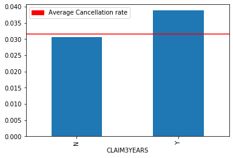

```python
#Basic aggregation can show which groups have higher rates, graphical ilustration or table

import matplotlib.patches as mpatches

print(data.groupby('CLAIM3YEARS').agg({'label':['count','sum','mean']}).rename(columns={'count':'Contracts','sum':'Targets','mean':'Cancellation rate'}))

Currency_Cancellation = data.pivot_table(index="CLAIM3YEARS",values="label")
Currency_Cancellation.plot.bar()
label = mpatches.Patch(color='red', label='Average Cancellation rate')
plt.legend(handles=[label])
plt.axhline(y=len(data[data['label']==1])/len(data), color='red')

plt.show()
```

```
                  label
              Contracts Targets Cancellation rate
P1_EMP_STATUS
A                    40     1.0          0.025000
C                    14     0.0          0.000000
E                 25858  1120.0          0.043313
F                    22     3.0          0.136364
H                   715    38.0          0.053147
I                    14     1.0          0.071429
N                   539    31.0          0.057514
R                106630  2993.0          0.028069
S                  1944    96.0          0.049383
U                   651    28.0          0.043011
V                    44     0.0          0.000000
```

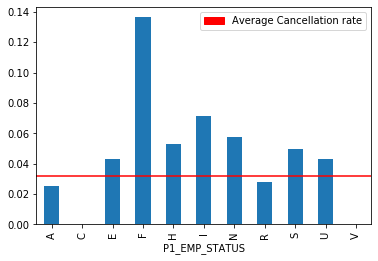

```python
#Basic aggregation can show which groups have higher rates, graphical ilustration or table

import matplotlib.patches as mpatches

print(data.groupby('P1_EMP_STATUS').agg({'label':['count','sum','mean']}).rename(columns={'count':'Contracts','sum':'Targets','mean':'Cancellation rate'}))

Currency_Cancellation = data.pivot_table(index="P1_EMP_STATUS",values="label")
Currency_Cancellation.plot.bar()
label = mpatches.Patch(color='red', label='Average Cancellation rate')
plt.legend(handles=[label])
plt.axhline(y=len(data[data['label']==1])/len(data), color='red')

plt.show()
```

```
                 label
             Contracts Targets Cancellation rate
AD_BUILDINGS
N                34532   914.0          0.026468
Y               101939  3397.0          0.033324
```

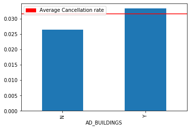

```python
#Basic aggregation can show which groups have higher rates, graphical ilustration or table

import matplotlib.patches as mpatches

print(data.groupby('AD_BUILDINGS').agg({'label':['count','sum','mean']}).rename(columns={'count':'Contracts','sum':'Targets','mean':'Cancellation rate'}))

Currency_Cancellation = data.pivot_table(index="AD_BUILDINGS",values="label")
Currency_Cancellation.plot.bar()
label = mpatches.Patch(color='red', label='Average Cancellation rate')
plt.legend(handles=[label])
plt.axhline(y=len(data[data['label']==1])/len(data), color='red')

plt.show()
```

#### Numerical Variables + Discrete Numerical Variables

##### NCD_GRANTED_YEARS_B

```python
# for numerical variables
print(data['NCD_GRANTED_YEARS_B'].describe())
print('\n')
print('# of Missing values in column = ',data['NCD_GRANTED_YEARS_B'].isnull().sum())
```

```
count    136471.000000
mean          4.295697
std           2.755647
min           0.000000
25%           0.000000
50%           6.000000
75%           6.000000
max           9.000000
Name: NCD_GRANTED_YEARS_B, dtype: float64


# of Missing values in column =  0
```

```python
data.NCD_GRANTED_YEARS_B.unique()
```

```
array([6., 0., 7., 3., 4., 2., 1., 5., 8., 9.])
```

```python
a = data['NCD_GRANTED_YEARS_B'].unique()
a.sort()
print(a)
```

```
[0. 1. 2. 3. 4. 5. 6. 7. 8. 9.]
```

```python
data[data['NCD_GRANTED_YEARS_B'].isnull()].head(5)
```

|  | COVER_START | CLAIM3YEARS | P1_EMP_STATUS | AD_BUILDINGS | RISK_RATED_AREA_B | NCD_GRANTED_YEARS_B | AD_CONTENTS | SUM_INSURED_CONTENTS | CONTENTS_COVER | BUILDINGS_COVER | SPEC_SUM_INSURED | SPEC_ITEM_PREM | P1_DOB | P1_MAR_STATUS | P1_SEX | APPR_ALARM | APPR_LOCKS | BEDROOMS | ROOF_CONSTRUCTION | WALL_CONSTRUCTION | FLOODING | LISTED | PROP_TYPE | SAFE_INSTALLED | YEARBUILT | PAYMENT_METHOD | HOME_EM_ADDON_PRE_REN | HOME_EM_ADDON_POST_REN | MTA_FLAG | … |
| --- | --- | --- | --- | --- | --- | --- | --- | --- | --- | --- | --- | --- | --- | --- | --- | --- | --- | --- | --- | --- | --- | --- | --- | --- | --- | --- | --- | --- | --- | --- |

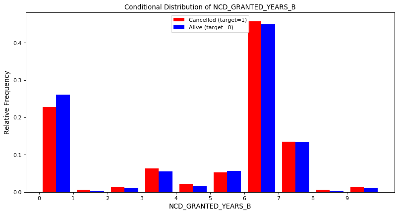

```python
# Distribution of NCD_GRANTED_YEARS_B conditional on Target

x1 = data.loc[data['label']==1, 'NCD_GRANTED_YEARS_B'] #Cancelled
x0 = data.loc[data['label']==0, 'NCD_GRANTED_YEARS_B'] #Alive

bins = np.linspace(0, 10, 11) # 31 spaces inbetween charts, could be 28 etc.
figure(num=None, figsize=(12, 6), dpi=80, facecolor='w', edgecolor='k')

x1_w = np.empty(x1.shape) #creating an array
x1_w.fill(1/x1.shape[0]) #creating weights for the array values
x0_w = np.empty(x0.shape)
x0_w.fill(1/x0.shape[0])

plt.hist([x1, x0], bins, weights=[x1_w, x0_w], label=['Cancelled (target=1)', 'Alive (target=0)'], color=['red','blue'])
plt.legend(loc='upper center')
plt.xlabel('NCD_GRANTED_YEARS_B', fontsize=12)
plt.ylabel('Relative Frequency', fontsize=12)
plt.xticks(np.arange(0, 10, step=1))
plt.title('Conditional Distribution of NCD_GRANTED_YEARS_B')

plt.show()
```

##### AgeOfContract

```python
print(data['AgeOfContract'].describe())
print('\n')
print('# of Missing values in column = ',data['AgeOfContract'].isnull().sum())
```

```
count    136471.000000
mean          5.500238
std           4.086894
min           0.000000
25%           2.000000
50%           4.000000
75%           8.000000
max          20.000000
Name: AgeOfContract, dtype: float64


# of Missing values in column =  0
```

```python
data.AgeOfContract.unique()
```

```
array([ 5,  4,  1,  7,  8,  9,  6, 11, 10, 12,  3, 13, 17, 14, 15,  2, 16,
       19, 18, 20,  0], dtype=int64)
```

```python
b = data['AgeOfContract'].unique()
b.sort()
print(b)
```

```
[ 0  1  2  3  4  5  6  7  8  9 10 11 12 13 14 15 16 17 18 19 20]
```

```python
data[data['AgeOfContract'].isnull()].head(5)
```

|  | COVER_START | CLAIM3YEARS | P1_EMP_STATUS | AD_BUILDINGS | RISK_RATED_AREA_B | NCD_GRANTED_YEARS_B | AD_CONTENTS | SUM_INSURED_CONTENTS | CONTENTS_COVER | BUILDINGS_COVER | SPEC_SUM_INSURED | SPEC_ITEM_PREM | P1_DOB | P1_MAR_STATUS | P1_SEX | APPR_ALARM | APPR_LOCKS | BEDROOMS | ROOF_CONSTRUCTION | WALL_CONSTRUCTION | FLOODING | LISTED | PROP_TYPE | SAFE_INSTALLED | YEARBUILT | PAYMENT_METHOD | HOME_EM_ADDON_PRE_REN | HOME_EM_ADDON_POST_REN | MTA_FLAG | … |
| --- | --- | --- | --- | --- | --- | --- | --- | --- | --- | --- | --- | --- | --- | --- | --- | --- | --- | --- | --- | --- | --- | --- | --- | --- | --- | --- | --- | --- | --- | --- |

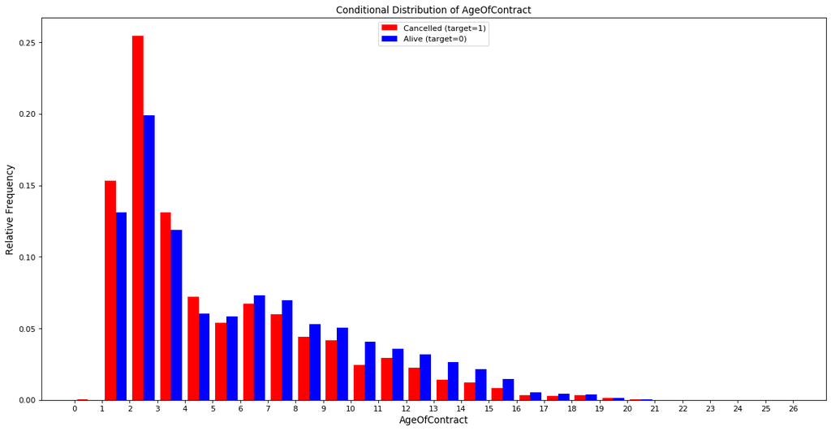

```python
# Distribution of AgeOfContract conditional on Target

x1 = data.loc[data['label']==1, 'AgeOfContract'] #Cancelled
x0 = data.loc[data['label']==0, 'AgeOfContract'] #Alive

bins = np.linspace(0, 26, 27) # 31 spaces inbetween charts, could be 28 etc.
figure(num=None, figsize=(18, 9), dpi=80, facecolor='w', edgecolor='k')

x1_w = np.empty(x1.shape) #creating an array
x1_w.fill(1/x1.shape[0]) #creating weights for the array values
x0_w = np.empty(x0.shape)
x0_w.fill(1/x0.shape[0])

plt.hist([x1, x0], bins, weights=[x1_w, x0_w], label=['Cancelled (target=1)', 'Alive (target=0)'], color=['red','blue'])
plt.legend(loc='upper center')
plt.xlabel('AgeOfContract', fontsize=12)
plt.ylabel('Relative Frequency', fontsize=12)
plt.xticks(np.arange(0, 27, step=1))
plt.title('Conditional Distribution of AgeOfContract')

plt.show()
```

#### Interaction of explanatory variables

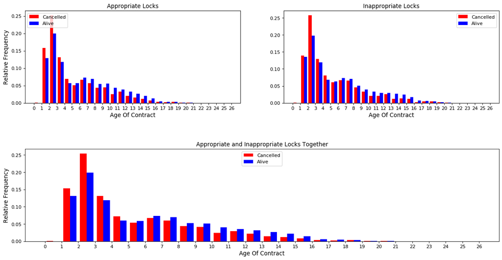

```python
#Can split data for "Building + Contents" vs. "Building Only" to check whether they behave similarly, if they don't, interactions are recommended

data_AL=data[data['APPR_LOCKS']=="Y"]
data_IL=data[data['APPR_LOCKS']=="N"]

x1 = data_AL.loc[data_AL['label']==1, 'AgeOfContract'] #Cancelled #data_AL vs data_IL vs data (all)
x0 = data_AL.loc[data_AL['label']==0, 'AgeOfContract'] #Alive

z1 = data_IL.loc[data_IL['label']==1, 'AgeOfContract'] #Cancelled #data_AL vs data_IL vs data (all)
z0 = data_IL.loc[data_IL['label']==0, 'AgeOfContract'] #Alive

y1 = data.loc[data['label']==1, 'AgeOfContract'] #Cancelled #data_AL vs data_IL vs data (all)
y0 = data.loc[data['label']==0, 'AgeOfContract'] #Alive

bins = np.linspace(0, 26, 27)
figure(num=None, figsize=(18, 9), dpi=80, facecolor='w', edgecolor='k')

x1_w = np.empty(x1.shape)
z1_w = np.empty(z1.shape)
y1_w = np.empty(y1.shape)

x1_w.fill(1/x1.shape[0])
z1_w.fill(1/z1.shape[0])
y1_w.fill(1/y1.shape[0])

x0_w = np.empty(x0.shape)
z0_w = np.empty(z0.shape)
y0_w = np.empty(y0.shape)

x0_w.fill(1/x0.shape[0])
z0_w.fill(1/z0.shape[0])
y0_w.fill(1/y0.shape[0])

plt.subplot(2, 2, 1)
plt.hist([x1, x0], bins, weights=[x1_w, x0_w], label=['Cancelled', 'Alive'], color=['red','blue'])
plt.legend(loc='upper left')
plt.title('Appropriate Locks')
plt.xlabel('Age Of Contract', fontsize=12)
plt.ylabel('Relative Frequency', fontsize=12)
plt.xticks(np.arange(0, 27, step=1))
plt.subplot(2, 2, 2)
plt.hist([z1, z0], bins, weights=[z1_w, z0_w], label=['Cancelled', 'Alive'], color=['red','blue'])
plt.xlabel('Age Of Contract', fontsize=12)
plt.legend(loc='upper right')
plt.title('Inappropriate Locks')
plt.xticks(np.arange(0, 27, step=1))
plt.subplot(2, 1, 2)
plt.hist([y1, y0], bins, weights=[y1_w, y0_w], label=['Cancelled', 'Alive'], color=['red','blue'])
plt.title('Appropriate and Inappropriate Locks Together')
plt.legend(loc='upper center')
plt.ylabel('Relative Frequency', fontsize=12)
plt.xlabel('Age Of Contract', fontsize=12)
plt.subplots_adjust(hspace=0.5)
plt.xticks(np.arange(0, 27, step=1))

plt.show()
```

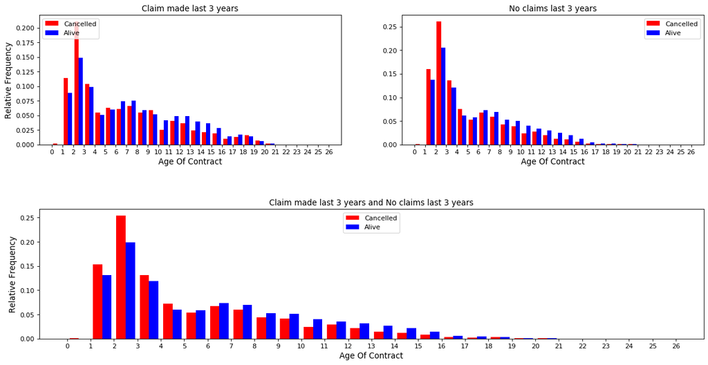

```python
#Can split data for "Building + Contents" vs. "Building Only" to check whether they behave similarly, if they don't, interactions are recommended

data_CM=data[data['CLAIM3YEARS']=="Y"]
data_NC=data[data['CLAIM3YEARS']=="N"]

x1 = data_CM.loc[data_CM['label']==1, 'AgeOfContract'] #Cancelled #data_AL vs data_IL vs data (all)
x0 = data_CM.loc[data_CM['label']==0, 'AgeOfContract'] #Alive

z1 = data_NC.loc[data_NC['label']==1, 'AgeOfContract'] #Cancelled #data_AL vs data_IL vs data (all)
z0 = data_NC.loc[data_NC['label']==0, 'AgeOfContract'] #Alive

y1 = data.loc[data['label']==1, 'AgeOfContract'] #Cancelled #data_AL vs data_IL vs data (all)
y0 = data.loc[data['label']==0, 'AgeOfContract'] #Alive

bins = np.linspace(0, 26, 27)
figure(num=None, figsize=(18, 9), dpi=80, facecolor='w', edgecolor='k')

x1_w = np.empty(x1.shape)
z1_w = np.empty(z1.shape)
y1_w = np.empty(y1.shape)

x1_w.fill(1/x1.shape[0])
z1_w.fill(1/z1.shape[0])
y1_w.fill(1/y1.shape[0])

x0_w = np.empty(x0.shape)
z0_w = np.empty(z0.shape)
y0_w = np.empty(y0.shape)

x0_w.fill(1/x0.shape[0])
z0_w.fill(1/z0.shape[0])
y0_w.fill(1/y0.shape[0])

plt.subplot(2, 2, 1)
plt.hist([x1, x0], bins, weights=[x1_w, x0_w], label=['Cancelled', 'Alive'], color=['red','blue'])
plt.legend(loc='upper left')
plt.title('Claim made last 3 years')
plt.xlabel('Age Of Contract', fontsize=12)
plt.ylabel('Relative Frequency', fontsize=12)
plt.xticks(np.arange(0, 27, step=1))
plt.subplot(2, 2, 2)
plt.hist([z1, z0], bins, weights=[z1_w, z0_w], label=['Cancelled', 'Alive'], color=['red','blue'])
plt.xlabel('Age Of Contract', fontsize=12)
plt.legend(loc='upper right')
plt.title('No claims last 3 years')
plt.xticks(np.arange(0, 27, step=1))
plt.subplot(2, 1, 2)
plt.hist([y1, y0], bins, weights=[y1_w, y0_w], label=['Cancelled', 'Alive'], color=['red','blue'])
plt.title('Claim made last 3 years and No claims last 3 years')
plt.legend(loc='upper center')
plt.ylabel('Relative Frequency', fontsize=12)
plt.xlabel('Age Of Contract', fontsize=12)
plt.subplots_adjust(hspace=0.5)
plt.xticks(np.arange(0, 27, step=1))

plt.show()
```

```python
print(max(y1))
print(max(y0))
```

```
20
20
```

## Train vs. Test Set

```python
# We are not allowed to use information from testing set to find the ideal bins (cheating) - We need to split train/test now and use training set only

from sklearn.model_selection import train_test_split

# create training and testing vars
train_set, test_set = train_test_split(data, test_size=0.3,random_state=12345)

print('Number of observations in train set = ',len(train_set))
print('Number of Cancellations (taget=1) in train_set: ', len(train_set[train_set['label']==1]))
print('\n')
print('Number of observations in test set = ',len(test_set))
print('Number of Cancellations (taget=1) in test_set: ', len(test_set[test_set['label']==1]))
```

```
Number of observations in train set =  95529
Number of Cancellations (taget=1) in train_set:  3021


Number of observations in test set =  40942
Number of Cancellations (taget=1) in test_set:  1290
```

```python
train_set.head()
```

|  | COVER_START | CLAIM3YEARS | P1_EMP_STATUS | AD_BUILDINGS | RISK_RATED_AREA_B | NCD_GRANTED_YEARS_B | AD_CONTENTS | SUM_INSURED_CONTENTS | CONTENTS_COVER | BUILDINGS_COVER | SPEC_SUM_INSURED | SPEC_ITEM_PREM | P1_DOB | P1_MAR_STATUS | P1_SEX | APPR_ALARM | APPR_LOCKS | BEDROOMS | ROOF_CONSTRUCTION | WALL_CONSTRUCTION | FLOODING | LISTED | PROP_TYPE | SAFE_INSTALLED | YEARBUILT | PAYMENT_METHOD | HOME_EM_ADDON_PRE_REN | HOME_EM_ADDON_POST_REN | MTA_FLAG | … |
| --- | --- | --- | --- | --- | --- | --- | --- | --- | --- | --- | --- | --- | --- | --- | --- | --- | --- | --- | --- | --- | --- | --- | --- | --- | --- | --- | --- | --- | --- | --- |
| 188331 | 1999-01-03 | Y | R | Y | 5 | 3.0 | Y | 50000.0 | Y | Y | 0.0 | 0.0 | 1944-06-25 | O | M | N | Y | 2.0 | 11 | 15 | Y | 3 | 9 | N | 1946-01-01 | PureDD | N | N | N | … |
| 58551 | 2000-10-12 | N | R | Y | 7 | 6.0 | N | 0.0 | Y | N | 0.0 | 0.0 | 1936-03-20 | M | F | N | N | 3.0 | 11 | 15 | Y | 3 | 1 | N | 2000-01-01 | NonDD | N | N | Y | … |
| 112870 | 2007-01-29 | N | R | Y | 10 | 6.0 | Y | 50000.0 | Y | Y | 0.0 | 0.0 | 1950-06-30 | O | M | Y | Y | 3.0 | 11 | 15 | Y | 3 | 1 | N | 1980-01-01 | NonDD | N | N | Y | … |
| 130441 | 2011-01-03 | N | R | Y | 9 | 6.0 | Y | 50000.0 | Y | Y | 800.0 | 43953.0 | 1945-05-28 | M | M | Y | Y | 3.0 | 11 | 15 | Y | 3 | 51 | N | 1960-01-01 | NonDD | N | N | N | … |
| 102081 | 2011-06-01 | N | R | Y | 17 | 7.0 | Y | 50000.0 | Y | Y | 0.0 | 0.0 | 1921-02-14 | O | F | N | N | 3.0 | 11 | 15 | Y | 3 | 2 | N | 1980-01-01 | NonDD | Y | N | N | … |

## Feature Selection

#### Preparation

```python
train_set_feature = train_set.copy()
```

```python
train_set_feature.head(3)
```

|  | COVER_START | CLAIM3YEARS | P1_EMP_STATUS | AD_BUILDINGS | RISK_RATED_AREA_B | NCD_GRANTED_YEARS_B | AD_CONTENTS | SUM_INSURED_CONTENTS | CONTENTS_COVER | BUILDINGS_COVER | SPEC_SUM_INSURED | SPEC_ITEM_PREM | P1_DOB | P1_MAR_STATUS | P1_SEX | APPR_ALARM | APPR_LOCKS | BEDROOMS | ROOF_CONSTRUCTION | WALL_CONSTRUCTION | FLOODING | LISTED | PROP_TYPE | SAFE_INSTALLED | YEARBUILT | PAYMENT_METHOD | HOME_EM_ADDON_PRE_REN | HOME_EM_ADDON_POST_REN | MTA_FLAG | … |
| --- | --- | --- | --- | --- | --- | --- | --- | --- | --- | --- | --- | --- | --- | --- | --- | --- | --- | --- | --- | --- | --- | --- | --- | --- | --- | --- | --- | --- | --- | --- |
| 188331 | 1999-01-03 | Y | R | Y | 5 | 3.0 | Y | 50000.0 | Y | Y | 0.0 | 0.0 | 1944-06-25 | O | M | N | Y | 2.0 | 11 | 15 | Y | 3 | 9 | N | 1946-01-01 | PureDD | N | N | N | … |
| 58551 | 2000-10-12 | N | R | Y | 7 | 6.0 | N | 0.0 | Y | N | 0.0 | 0.0 | 1936-03-20 | M | F | N | N | 3.0 | 11 | 15 | Y | 3 | 1 | N | 2000-01-01 | NonDD | N | N | Y | … |
| 112870 | 2007-01-29 | N | R | Y | 10 | 6.0 | Y | 50000.0 | Y | Y | 0.0 | 0.0 | 1950-06-30 | O | M | Y | Y | 3.0 | 11 | 15 | Y | 3 | 1 | N | 1980-01-01 | NonDD | N | N | Y | … |

```python
train_set_feature.P1_MAR_STATUS.unique()
```

```
array(['O', 'M', 'W', 'P', 'S', 'D', 'A', 'C', 'B', 'N'], dtype=object)
```

```python
train_set_feature.CLAIM3YEARS.unique()
```

```
array(['Y', 'N'], dtype=object)
```

```python
train_set_feature.loc[train_set_feature['CLAIM3YEARS'] == 'Y', 'CLAIM3YEARS'] = 1
train_set_feature.loc[train_set_feature['CLAIM3YEARS'] == 'N', 'CLAIM3YEARS'] = 2
```

```python
train_set_feature.head(3)
```

|  | COVER_START | CLAIM3YEARS | P1_EMP_STATUS | AD_BUILDINGS | RISK_RATED_AREA_B | NCD_GRANTED_YEARS_B | AD_CONTENTS | SUM_INSURED_CONTENTS | CONTENTS_COVER | BUILDINGS_COVER | SPEC_SUM_INSURED | SPEC_ITEM_PREM | P1_DOB | P1_MAR_STATUS | P1_SEX | APPR_ALARM | APPR_LOCKS | BEDROOMS | ROOF_CONSTRUCTION | WALL_CONSTRUCTION | FLOODING | LISTED | PROP_TYPE | SAFE_INSTALLED | YEARBUILT | PAYMENT_METHOD | HOME_EM_ADDON_PRE_REN | HOME_EM_ADDON_POST_REN | MTA_FLAG | … |
| --- | --- | --- | --- | --- | --- | --- | --- | --- | --- | --- | --- | --- | --- | --- | --- | --- | --- | --- | --- | --- | --- | --- | --- | --- | --- | --- | --- | --- | --- | --- |
| 188331 | 1999-01-03 | 1 | R | Y | 5 | 3.0 | Y | 50000.0 | Y | Y | 0.0 | 0.0 | 1944-06-25 | O | M | N | Y | 2.0 | 11 | 15 | Y | 3 | 9 | N | 1946-01-01 | PureDD | N | N | N | … |
| 58551 | 2000-10-12 | 2 | R | Y | 7 | 6.0 | N | 0.0 | Y | N | 0.0 | 0.0 | 1936-03-20 | M | F | N | N | 3.0 | 11 | 15 | Y | 3 | 1 | N | 2000-01-01 | NonDD | N | N | Y | … |
| 112870 | 2007-01-29 | 2 | R | Y | 10 | 6.0 | Y | 50000.0 | Y | Y | 0.0 | 0.0 | 1950-06-30 | O | M | Y | Y | 3.0 | 11 | 15 | Y | 3 | 1 | N | 1980-01-01 | NonDD | N | N | Y | … |

```python
train_set_feature.P1_EMP_STATUS.unique()
```

```
array(['R', 'E', 'S', 'N', 'U', 'H', 'F', 'V', 'A', 'C', 'I'],
      dtype=object)
```

```python
train_set_feature.loc[train_set_feature['P1_EMP_STATUS'] == 'R', 'P1_EMP_STATUS'] = 1
train_set_feature.loc[train_set_feature['P1_EMP_STATUS'] == 'E', 'P1_EMP_STATUS'] = 2
train_set_feature.loc[train_set_feature['P1_EMP_STATUS'] == 'S', 'P1_EMP_STATUS'] = 3
train_set_feature.loc[train_set_feature['P1_EMP_STATUS'] == 'N', 'P1_EMP_STATUS'] = 4
train_set_feature.loc[train_set_feature['P1_EMP_STATUS'] == 'U', 'P1_EMP_STATUS'] = 5
train_set_feature.loc[train_set_feature['P1_EMP_STATUS'] == 'H', 'P1_EMP_STATUS'] = 6
train_set_feature.loc[train_set_feature['P1_EMP_STATUS'] == 'F', 'P1_EMP_STATUS'] = 7
train_set_feature.loc[train_set_feature['P1_EMP_STATUS'] == 'V', 'P1_EMP_STATUS'] = 8
train_set_feature.loc[train_set_feature['P1_EMP_STATUS'] == 'A', 'P1_EMP_STATUS'] = 9
train_set_feature.loc[train_set_feature['P1_EMP_STATUS'] == 'C', 'P1_EMP_STATUS'] = 10
train_set_feature.loc[train_set_feature['P1_EMP_STATUS'] == 'I', 'P1_EMP_STATUS'] = 11
```

```python
train_set_feature.head(3)
```

|  | COVER_START | CLAIM3YEARS | P1_EMP_STATUS | AD_BUILDINGS | RISK_RATED_AREA_B | NCD_GRANTED_YEARS_B | AD_CONTENTS | SUM_INSURED_CONTENTS | CONTENTS_COVER | BUILDINGS_COVER | SPEC_SUM_INSURED | SPEC_ITEM_PREM | P1_DOB | P1_MAR_STATUS | P1_SEX | APPR_ALARM | APPR_LOCKS | BEDROOMS | ROOF_CONSTRUCTION | WALL_CONSTRUCTION | FLOODING | LISTED | PROP_TYPE | SAFE_INSTALLED | YEARBUILT | PAYMENT_METHOD | HOME_EM_ADDON_PRE_REN | HOME_EM_ADDON_POST_REN | MTA_FLAG | … |
| --- | --- | --- | --- | --- | --- | --- | --- | --- | --- | --- | --- | --- | --- | --- | --- | --- | --- | --- | --- | --- | --- | --- | --- | --- | --- | --- | --- | --- | --- | --- |
| 188331 | 1999-01-03 | 1 | 1 | Y | 5 | 3.0 | Y | 50000.0 | Y | Y | 0.0 | 0.0 | 1944-06-25 | O | M | N | Y | 2.0 | 11 | 15 | Y | 3 | 9 | N | 1946-01-01 | PureDD | N | N | N | … |
| 58551 | 2000-10-12 | 2 | 1 | Y | 7 | 6.0 | N | 0.0 | Y | N | 0.0 | 0.0 | 1936-03-20 | M | F | N | N | 3.0 | 11 | 15 | Y | 3 | 1 | N | 2000-01-01 | NonDD | N | N | Y | … |
| 112870 | 2007-01-29 | 2 | 1 | Y | 10 | 6.0 | Y | 50000.0 | Y | Y | 0.0 | 0.0 | 1950-06-30 | O | M | Y | Y | 3.0 | 11 | 15 | Y | 3 | 1 | N | 1980-01-01 | NonDD | N | N | Y | … |

```python
train_set_feature.AD_BUILDINGS.unique()
```

```
array(['Y', 'N'], dtype=object)
```

```python
train_set_feature.loc[train_set_feature['AD_BUILDINGS'] == 'Y', 'AD_BUILDINGS'] = 1
train_set_feature.loc[train_set_feature['AD_BUILDINGS'] == 'N', 'AD_BUILDINGS'] = 2
```

```python
train_set_feature.head(3)
```

|  | COVER_START | CLAIM3YEARS | P1_EMP_STATUS | AD_BUILDINGS | RISK_RATED_AREA_B | NCD_GRANTED_YEARS_B | AD_CONTENTS | SUM_INSURED_CONTENTS | CONTENTS_COVER | BUILDINGS_COVER | SPEC_SUM_INSURED | SPEC_ITEM_PREM | P1_DOB | P1_MAR_STATUS | P1_SEX | APPR_ALARM | APPR_LOCKS | BEDROOMS | ROOF_CONSTRUCTION | WALL_CONSTRUCTION | FLOODING | LISTED | PROP_TYPE | SAFE_INSTALLED | YEARBUILT | PAYMENT_METHOD | HOME_EM_ADDON_PRE_REN | HOME_EM_ADDON_POST_REN | MTA_FLAG | … |
| --- | --- | --- | --- | --- | --- | --- | --- | --- | --- | --- | --- | --- | --- | --- | --- | --- | --- | --- | --- | --- | --- | --- | --- | --- | --- | --- | --- | --- | --- | --- |
| 188331 | 1999-01-03 | 1 | 1 | 1 | 5 | 3.0 | Y | 50000.0 | Y | Y | 0.0 | 0.0 | 1944-06-25 | O | M | N | Y | 2.0 | 11 | 15 | Y | 3 | 9 | N | 1946-01-01 | PureDD | N | N | N | … |
| 58551 | 2000-10-12 | 2 | 1 | 1 | 7 | 6.0 | N | 0.0 | Y | N | 0.0 | 0.0 | 1936-03-20 | M | F | N | N | 3.0 | 11 | 15 | Y | 3 | 1 | N | 2000-01-01 | NonDD | N | N | Y | … |
| 112870 | 2007-01-29 | 2 | 1 | 1 | 10 | 6.0 | Y | 50000.0 | Y | Y | 0.0 | 0.0 | 1950-06-30 | O | M | Y | Y | 3.0 | 11 | 15 | Y | 3 | 1 | N | 1980-01-01 | NonDD | N | N | Y | … |

```python
train_set_feature.RISK_RATED_AREA_B.unique()
```

```
array([5.0, 7.0, 10.0, 9.0, 17.0, nan, 18.0, 15.0, 1.0, 0.0, 12.0, 11.0,
       6.0, 24.0, 4.0, 19.0, 8.0, 3.0, 16.0, 14.0, 22.0, 32.0, 21.0, 13.0,
       33.0, 40.0, 28.0, 20.0, 35.0, 26.0, 2.0, 37.0, 23.0, 47.0, 30.0,
       25.0, 39.0, 27.0, 97.0, 38.0, 29.0, 36.0, 31.0, 41.0, 34.0, 96.0,
       42.0, 46.0, 44.0, 43.0, 91.0, 45.0, 92.0], dtype=object)
```

```python
train_set_feature['RISK_RATED_AREA_B'].fillna(method = 'ffill', inplace = True)
```

```python
train_set_feature.RISK_RATED_AREA_B.unique()
```

```
array([ 5.,  7., 10.,  9., 17., 18., 15.,  1.,  0., 12., 11.,  6., 24.,
        4., 19.,  8.,  3., 16., 14., 22., 32., 21., 13., 33., 40., 28.,
       20., 35., 26.,  2., 37., 23., 47., 30., 25., 39., 27., 97., 38.,
       29., 36., 31., 41., 34., 96., 42., 46., 44., 43., 91., 45., 92.])
```

```python
train_set_feature.AD_CONTENTS.unique()
```

```
array(['Y', 'N'], dtype=object)
```

```python
train_set_feature.loc[train_set_feature['AD_CONTENTS'] == 'Y', 'AD_CONTENTS'] = 1
train_set_feature.loc[train_set_feature['AD_CONTENTS'] == 'N', 'AD_CONTENTS'] = 2
```

```python
train_set_feature.head(3)
```

|  | COVER_START | CLAIM3YEARS | P1_EMP_STATUS | AD_BUILDINGS | RISK_RATED_AREA_B | NCD_GRANTED_YEARS_B | AD_CONTENTS | SUM_INSURED_CONTENTS | CONTENTS_COVER | BUILDINGS_COVER | SPEC_SUM_INSURED | SPEC_ITEM_PREM | P1_DOB | P1_MAR_STATUS | P1_SEX | APPR_ALARM | APPR_LOCKS | BEDROOMS | ROOF_CONSTRUCTION | WALL_CONSTRUCTION | FLOODING | LISTED | PROP_TYPE | SAFE_INSTALLED | YEARBUILT | PAYMENT_METHOD | HOME_EM_ADDON_PRE_REN | HOME_EM_ADDON_POST_REN | MTA_FLAG | … |
| --- | --- | --- | --- | --- | --- | --- | --- | --- | --- | --- | --- | --- | --- | --- | --- | --- | --- | --- | --- | --- | --- | --- | --- | --- | --- | --- | --- | --- | --- | --- |
| 188331 | 1999-01-03 | 1 | 1 | 1 | 5.0 | 3.0 | 1 | 50000.0 | Y | Y | 0.0 | 0.0 | 1944-06-25 | O | M | N | Y | 2.0 | 11 | 15 | Y | 3 | 9 | N | 1946-01-01 | PureDD | N | N | N | … |
| 58551 | 2000-10-12 | 2 | 1 | 1 | 7.0 | 6.0 | 2 | 0.0 | Y | N | 0.0 | 0.0 | 1936-03-20 | M | F | N | N | 3.0 | 11 | 15 | Y | 3 | 1 | N | 2000-01-01 | NonDD | N | N | Y | … |
| 112870 | 2007-01-29 | 2 | 1 | 1 | 10.0 | 6.0 | 1 | 50000.0 | Y | Y | 0.0 | 0.0 | 1950-06-30 | O | M | Y | Y | 3.0 | 11 | 15 | Y | 3 | 1 | N | 1980-01-01 | NonDD | N | N | Y | … |

```python
train_set_feature.CONTENTS_COVER.unique()
```

```
array(['Y', 'N'], dtype=object)
```

```python
train_set_feature.loc[train_set_feature['CONTENTS_COVER'] == 'Y', 'CONTENTS_COVER'] = 1
train_set_feature.loc[train_set_feature['CONTENTS_COVER'] == 'N', 'CONTENTS_COVER'] = 2
```

```python
train_set_feature.head(3)
```

|  | COVER_START | CLAIM3YEARS | P1_EMP_STATUS | AD_BUILDINGS | RISK_RATED_AREA_B | NCD_GRANTED_YEARS_B | AD_CONTENTS | SUM_INSURED_CONTENTS | CONTENTS_COVER | BUILDINGS_COVER | SPEC_SUM_INSURED | SPEC_ITEM_PREM | P1_DOB | P1_MAR_STATUS | P1_SEX | APPR_ALARM | APPR_LOCKS | BEDROOMS | ROOF_CONSTRUCTION | WALL_CONSTRUCTION | FLOODING | LISTED | PROP_TYPE | SAFE_INSTALLED | YEARBUILT | PAYMENT_METHOD | HOME_EM_ADDON_PRE_REN | HOME_EM_ADDON_POST_REN | MTA_FLAG | … |
| --- | --- | --- | --- | --- | --- | --- | --- | --- | --- | --- | --- | --- | --- | --- | --- | --- | --- | --- | --- | --- | --- | --- | --- | --- | --- | --- | --- | --- | --- | --- |
| 188331 | 1999-01-03 | 1 | 1 | 1 | 5.0 | 3.0 | 1 | 50000.0 | 1 | Y | 0.0 | 0.0 | 1944-06-25 | O | M | N | Y | 2.0 | 11 | 15 | Y | 3 | 9 | N | 1946-01-01 | PureDD | N | N | N | … |
| 58551 | 2000-10-12 | 2 | 1 | 1 | 7.0 | 6.0 | 2 | 0.0 | 1 | N | 0.0 | 0.0 | 1936-03-20 | M | F | N | N | 3.0 | 11 | 15 | Y | 3 | 1 | N | 2000-01-01 | NonDD | N | N | Y | … |
| 112870 | 2007-01-29 | 2 | 1 | 1 | 10.0 | 6.0 | 1 | 50000.0 | 1 | Y | 0.0 | 0.0 | 1950-06-30 | O | M | Y | Y | 3.0 | 11 | 15 | Y | 3 | 1 | N | 1980-01-01 | NonDD | N | N | Y | … |

```python
train_set_feature.BUILDINGS_COVER.unique()
```

```
array(['Y', 'N'], dtype=object)
```

```python
train_set_feature.loc[train_set_feature['BUILDINGS_COVER'] == 'Y', 'BUILDINGS_COVER'] = 1
train_set_feature.loc[train_set_feature['BUILDINGS_COVER'] == 'N', 'BUILDINGS_COVER'] = 2
```

```python
train_set_feature.head(3)
```

|  | COVER_START | CLAIM3YEARS | P1_EMP_STATUS | AD_BUILDINGS | RISK_RATED_AREA_B | NCD_GRANTED_YEARS_B | AD_CONTENTS | SUM_INSURED_CONTENTS | CONTENTS_COVER | BUILDINGS_COVER | SPEC_SUM_INSURED | SPEC_ITEM_PREM | P1_DOB | P1_MAR_STATUS | P1_SEX | APPR_ALARM | APPR_LOCKS | BEDROOMS | ROOF_CONSTRUCTION | WALL_CONSTRUCTION | FLOODING | LISTED | PROP_TYPE | SAFE_INSTALLED | YEARBUILT | PAYMENT_METHOD | HOME_EM_ADDON_PRE_REN | HOME_EM_ADDON_POST_REN | MTA_FLAG | … |
| --- | --- | --- | --- | --- | --- | --- | --- | --- | --- | --- | --- | --- | --- | --- | --- | --- | --- | --- | --- | --- | --- | --- | --- | --- | --- | --- | --- | --- | --- | --- |
| 188331 | 1999-01-03 | 1 | 1 | 1 | 5.0 | 3.0 | 1 | 50000.0 | 1 | 1 | 0.0 | 0.0 | 1944-06-25 | O | M | N | Y | 2.0 | 11 | 15 | Y | 3 | 9 | N | 1946-01-01 | PureDD | N | N | N | … |
| 58551 | 2000-10-12 | 2 | 1 | 1 | 7.0 | 6.0 | 2 | 0.0 | 1 | 2 | 0.0 | 0.0 | 1936-03-20 | M | F | N | N | 3.0 | 11 | 15 | Y | 3 | 1 | N | 2000-01-01 | NonDD | N | N | Y | … |
| 112870 | 2007-01-29 | 2 | 1 | 1 | 10.0 | 6.0 | 1 | 50000.0 | 1 | 1 | 0.0 | 0.0 | 1950-06-30 | O | M | Y | Y | 3.0 | 11 | 15 | Y | 3 | 1 | N | 1980-01-01 | NonDD | N | N | Y | … |

```python
train_set_feature.P1_MAR_STATUS.unique()
```

```
array(['O', 'M', 'W', 'P', 'S', 'D', 'A', 'C', 'B', 'N'], dtype=object)
```

```python
train_set_feature.loc[train_set_feature['P1_MAR_STATUS'] == 'O', 'P1_MAR_STATUS'] = 1
train_set_feature.loc[train_set_feature['P1_MAR_STATUS'] == 'M', 'P1_MAR_STATUS'] = 2
train_set_feature.loc[train_set_feature['P1_MAR_STATUS'] == 'W', 'P1_MAR_STATUS'] = 3
train_set_feature.loc[train_set_feature['P1_MAR_STATUS'] == 'P', 'P1_MAR_STATUS'] = 4
train_set_feature.loc[train_set_feature['P1_MAR_STATUS'] == 'S', 'P1_MAR_STATUS'] = 5
train_set_feature.loc[train_set_feature['P1_MAR_STATUS'] == 'D', 'P1_MAR_STATUS'] = 6
train_set_feature.loc[train_set_feature['P1_MAR_STATUS'] == 'A', 'P1_MAR_STATUS'] = 7
train_set_feature.loc[train_set_feature['P1_MAR_STATUS'] == 'C', 'P1_MAR_STATUS'] = 8
train_set_feature.loc[train_set_feature['P1_MAR_STATUS'] == 'B', 'P1_MAR_STATUS'] = 9
train_set_feature.loc[train_set_feature['P1_MAR_STATUS'] == 'N', 'P1_MAR_STATUS'] = 10
```

```python
train_set_feature.head(3)
```

|  | COVER_START | CLAIM3YEARS | P1_EMP_STATUS | AD_BUILDINGS | RISK_RATED_AREA_B | NCD_GRANTED_YEARS_B | AD_CONTENTS | SUM_INSURED_CONTENTS | CONTENTS_COVER | BUILDINGS_COVER | SPEC_SUM_INSURED | SPEC_ITEM_PREM | P1_DOB | P1_MAR_STATUS | P1_SEX | APPR_ALARM | APPR_LOCKS | BEDROOMS | ROOF_CONSTRUCTION | WALL_CONSTRUCTION | FLOODING | LISTED | PROP_TYPE | SAFE_INSTALLED | YEARBUILT | PAYMENT_METHOD | HOME_EM_ADDON_PRE_REN | HOME_EM_ADDON_POST_REN | MTA_FLAG | … |
| --- | --- | --- | --- | --- | --- | --- | --- | --- | --- | --- | --- | --- | --- | --- | --- | --- | --- | --- | --- | --- | --- | --- | --- | --- | --- | --- | --- | --- | --- | --- |
| 188331 | 1999-01-03 | 1 | 1 | 1 | 5.0 | 3.0 | 1 | 50000.0 | 1 | 1 | 0.0 | 0.0 | 1944-06-25 | 1 | M | N | Y | 2.0 | 11 | 15 | Y | 3 | 9 | N | 1946-01-01 | PureDD | N | N | N | … |
| 58551 | 2000-10-12 | 2 | 1 | 1 | 7.0 | 6.0 | 2 | 0.0 | 1 | 2 | 0.0 | 0.0 | 1936-03-20 | 2 | F | N | N | 3.0 | 11 | 15 | Y | 3 | 1 | N | 2000-01-01 | NonDD | N | N | Y | … |
| 112870 | 2007-01-29 | 2 | 1 | 1 | 10.0 | 6.0 | 1 | 50000.0 | 1 | 1 | 0.0 | 0.0 | 1950-06-30 | 1 | M | Y | Y | 3.0 | 11 | 15 | Y | 3 | 1 | N | 1980-01-01 | NonDD | N | N | Y | … |

```python
train_set_feature.P1_SEX.unique()
```

```
array(['M', 'F', 'N'], dtype=object)
```

```python
train_set_feature.loc[train_set_feature['P1_SEX'] == 'M', 'P1_SEX'] = 1
train_set_feature.loc[train_set_feature['P1_SEX'] == 'F', 'P1_SEX'] = 2
train_set_feature.loc[train_set_feature['P1_SEX'] == 'N', 'P1_SEX'] = 3
```

```python
train_set_feature.head(3)
```

|  | COVER_START | CLAIM3YEARS | P1_EMP_STATUS | AD_BUILDINGS | RISK_RATED_AREA_B | NCD_GRANTED_YEARS_B | AD_CONTENTS | SUM_INSURED_CONTENTS | CONTENTS_COVER | BUILDINGS_COVER | SPEC_SUM_INSURED | SPEC_ITEM_PREM | P1_DOB | P1_MAR_STATUS | P1_SEX | APPR_ALARM | APPR_LOCKS | BEDROOMS | ROOF_CONSTRUCTION | WALL_CONSTRUCTION | FLOODING | LISTED | PROP_TYPE | SAFE_INSTALLED | YEARBUILT | PAYMENT_METHOD | HOME_EM_ADDON_PRE_REN | HOME_EM_ADDON_POST_REN | MTA_FLAG | … |
| --- | --- | --- | --- | --- | --- | --- | --- | --- | --- | --- | --- | --- | --- | --- | --- | --- | --- | --- | --- | --- | --- | --- | --- | --- | --- | --- | --- | --- | --- | --- |
| 188331 | 1999-01-03 | 1 | 1 | 1 | 5.0 | 3.0 | 1 | 50000.0 | 1 | 1 | 0.0 | 0.0 | 1944-06-25 | 1 | 1 | N | Y | 2.0 | 11 | 15 | Y | 3 | 9 | N | 1946-01-01 | PureDD | N | N | N | … |
| 58551 | 2000-10-12 | 2 | 1 | 1 | 7.0 | 6.0 | 2 | 0.0 | 1 | 2 | 0.0 | 0.0 | 1936-03-20 | 2 | 2 | N | N | 3.0 | 11 | 15 | Y | 3 | 1 | N | 2000-01-01 | NonDD | N | N | Y | … |
| 112870 | 2007-01-29 | 2 | 1 | 1 | 10.0 | 6.0 | 1 | 50000.0 | 1 | 1 | 0.0 | 0.0 | 1950-06-30 | 1 | 1 | Y | Y | 3.0 | 11 | 15 | Y | 3 | 1 | N | 1980-01-01 | NonDD | N | N | Y | … |

```python
train_set_feature.APPR_ALARM.unique()
```

```
array(['N', 'Y'], dtype=object)
```

```python
train_set_feature.loc[train_set_feature['APPR_ALARM'] == 'Y', 'APPR_ALARM'] = 1
train_set_feature.loc[train_set_feature['APPR_ALARM'] == 'N', 'APPR_ALARM'] = 2
```

```python
train_set_feature.head(3)
```

|  | COVER_START | CLAIM3YEARS | P1_EMP_STATUS | AD_BUILDINGS | RISK_RATED_AREA_B | NCD_GRANTED_YEARS_B | AD_CONTENTS | SUM_INSURED_CONTENTS | CONTENTS_COVER | BUILDINGS_COVER | SPEC_SUM_INSURED | SPEC_ITEM_PREM | P1_DOB | P1_MAR_STATUS | P1_SEX | APPR_ALARM | APPR_LOCKS | BEDROOMS | ROOF_CONSTRUCTION | WALL_CONSTRUCTION | FLOODING | LISTED | PROP_TYPE | SAFE_INSTALLED | YEARBUILT | PAYMENT_METHOD | HOME_EM_ADDON_PRE_REN | HOME_EM_ADDON_POST_REN | MTA_FLAG | … |
| --- | --- | --- | --- | --- | --- | --- | --- | --- | --- | --- | --- | --- | --- | --- | --- | --- | --- | --- | --- | --- | --- | --- | --- | --- | --- | --- | --- | --- | --- | --- |
| 188331 | 1999-01-03 | 1 | 1 | 1 | 5.0 | 3.0 | 1 | 50000.0 | 1 | 1 | 0.0 | 0.0 | 1944-06-25 | 1 | 1 | 2 | Y | 2.0 | 11 | 15 | Y | 3 | 9 | N | 1946-01-01 | PureDD | N | N | N | … |
| 58551 | 2000-10-12 | 2 | 1 | 1 | 7.0 | 6.0 | 2 | 0.0 | 1 | 2 | 0.0 | 0.0 | 1936-03-20 | 2 | 2 | 2 | N | 3.0 | 11 | 15 | Y | 3 | 1 | N | 2000-01-01 | NonDD | N | N | Y | … |
| 112870 | 2007-01-29 | 2 | 1 | 1 | 10.0 | 6.0 | 1 | 50000.0 | 1 | 1 | 0.0 | 0.0 | 1950-06-30 | 1 | 1 | 1 | Y | 3.0 | 11 | 15 | Y | 3 | 1 | N | 1980-01-01 | NonDD | N | N | Y | … |

```python
train_set_feature.APPR_LOCKS.unique()
```

```
array(['Y', 'N'], dtype=object)
```

```python
train_set_feature.loc[train_set_feature['APPR_LOCKS'] == 'Y', 'APPR_LOCKS'] = 1
train_set_feature.loc[train_set_feature['APPR_LOCKS'] == 'N', 'APPR_LOCKS'] = 2
```

```python
train_set_feature.head(3)
```

|  | COVER_START | CLAIM3YEARS | P1_EMP_STATUS | AD_BUILDINGS | RISK_RATED_AREA_B | NCD_GRANTED_YEARS_B | AD_CONTENTS | SUM_INSURED_CONTENTS | CONTENTS_COVER | BUILDINGS_COVER | SPEC_SUM_INSURED | SPEC_ITEM_PREM | P1_DOB | P1_MAR_STATUS | P1_SEX | APPR_ALARM | APPR_LOCKS | BEDROOMS | ROOF_CONSTRUCTION | WALL_CONSTRUCTION | FLOODING | LISTED | PROP_TYPE | SAFE_INSTALLED | YEARBUILT | PAYMENT_METHOD | HOME_EM_ADDON_PRE_REN | HOME_EM_ADDON_POST_REN | MTA_FLAG | … |
| --- | --- | --- | --- | --- | --- | --- | --- | --- | --- | --- | --- | --- | --- | --- | --- | --- | --- | --- | --- | --- | --- | --- | --- | --- | --- | --- | --- | --- | --- | --- |
| 188331 | 1999-01-03 | 1 | 1 | 1 | 5.0 | 3.0 | 1 | 50000.0 | 1 | 1 | 0.0 | 0.0 | 1944-06-25 | 1 | 1 | 2 | 1 | 2.0 | 11 | 15 | Y | 3 | 9 | N | 1946-01-01 | PureDD | N | N | N | … |
| 58551 | 2000-10-12 | 2 | 1 | 1 | 7.0 | 6.0 | 2 | 0.0 | 1 | 2 | 0.0 | 0.0 | 1936-03-20 | 2 | 2 | 2 | 2 | 3.0 | 11 | 15 | Y | 3 | 1 | N | 2000-01-01 | NonDD | N | N | Y | … |
| 112870 | 2007-01-29 | 2 | 1 | 1 | 10.0 | 6.0 | 1 | 50000.0 | 1 | 1 | 0.0 | 0.0 | 1950-06-30 | 1 | 1 | 1 | 1 | 3.0 | 11 | 15 | Y | 3 | 1 | N | 1980-01-01 | NonDD | N | N | Y | … |

```python
train_set_feature.FLOODING.unique()
```

```
array(['Y', 'N'], dtype=object)
```

```python
train_set_feature.loc[train_set_feature['FLOODING'] == 'Y', 'FLOODING'] = 1
train_set_feature.loc[train_set_feature['FLOODING'] == 'N', 'FLOODING'] = 2
```

```python
train_set_feature.head(3)
```

|  | COVER_START | CLAIM3YEARS | P1_EMP_STATUS | AD_BUILDINGS | RISK_RATED_AREA_B | NCD_GRANTED_YEARS_B | AD_CONTENTS | SUM_INSURED_CONTENTS | CONTENTS_COVER | BUILDINGS_COVER | SPEC_SUM_INSURED | SPEC_ITEM_PREM | P1_DOB | P1_MAR_STATUS | P1_SEX | APPR_ALARM | APPR_LOCKS | BEDROOMS | ROOF_CONSTRUCTION | WALL_CONSTRUCTION | FLOODING | LISTED | PROP_TYPE | SAFE_INSTALLED | YEARBUILT | PAYMENT_METHOD | HOME_EM_ADDON_PRE_REN | HOME_EM_ADDON_POST_REN | MTA_FLAG | … |
| --- | --- | --- | --- | --- | --- | --- | --- | --- | --- | --- | --- | --- | --- | --- | --- | --- | --- | --- | --- | --- | --- | --- | --- | --- | --- | --- | --- | --- | --- | --- |
| 188331 | 1999-01-03 | 1 | 1 | 1 | 5.0 | 3.0 | 1 | 50000.0 | 1 | 1 | 0.0 | 0.0 | 1944-06-25 | 1 | 1 | 2 | 1 | 2.0 | 11 | 15 | 1 | 3 | 9 | N | 1946-01-01 | PureDD | N | N | N | … |
| 58551 | 2000-10-12 | 2 | 1 | 1 | 7.0 | 6.0 | 2 | 0.0 | 1 | 2 | 0.0 | 0.0 | 1936-03-20 | 2 | 2 | 2 | 2 | 3.0 | 11 | 15 | 1 | 3 | 1 | N | 2000-01-01 | NonDD | N | N | Y | … |
| 112870 | 2007-01-29 | 2 | 1 | 1 | 10.0 | 6.0 | 1 | 50000.0 | 1 | 1 | 0.0 | 0.0 | 1950-06-30 | 1 | 1 | 1 | 1 | 3.0 | 11 | 15 | 1 | 3 | 1 | N | 1980-01-01 | NonDD | N | N | Y | … |

```python
train_set_feature.SAFE_INSTALLED.unique()
```

```
array(['N', 'Y'], dtype=object)
```

```python
train_set_feature.loc[train_set_feature['SAFE_INSTALLED'] == 'Y', 'SAFE_INSTALLED'] = 1
train_set_feature.loc[train_set_feature['SAFE_INSTALLED'] == 'N', 'SAFE_INSTALLED'] = 2
```

```python
train_set_feature.head(3)
```

|  | COVER_START | CLAIM3YEARS | P1_EMP_STATUS | AD_BUILDINGS | RISK_RATED_AREA_B | NCD_GRANTED_YEARS_B | AD_CONTENTS | SUM_INSURED_CONTENTS | CONTENTS_COVER | BUILDINGS_COVER | SPEC_SUM_INSURED | SPEC_ITEM_PREM | P1_DOB | P1_MAR_STATUS | P1_SEX | APPR_ALARM | APPR_LOCKS | BEDROOMS | ROOF_CONSTRUCTION | WALL_CONSTRUCTION | FLOODING | LISTED | PROP_TYPE | SAFE_INSTALLED | YEARBUILT | PAYMENT_METHOD | HOME_EM_ADDON_PRE_REN | HOME_EM_ADDON_POST_REN | MTA_FLAG | … |
| --- | --- | --- | --- | --- | --- | --- | --- | --- | --- | --- | --- | --- | --- | --- | --- | --- | --- | --- | --- | --- | --- | --- | --- | --- | --- | --- | --- | --- | --- | --- |
| 188331 | 1999-01-03 | 1 | 1 | 1 | 5.0 | 3.0 | 1 | 50000.0 | 1 | 1 | 0.0 | 0.0 | 1944-06-25 | 1 | 1 | 2 | 1 | 2.0 | 11 | 15 | 1 | 3 | 9 | 2 | 1946-01-01 | PureDD | N | N | N | … |
| 58551 | 2000-10-12 | 2 | 1 | 1 | 7.0 | 6.0 | 2 | 0.0 | 1 | 2 | 0.0 | 0.0 | 1936-03-20 | 2 | 2 | 2 | 2 | 3.0 | 11 | 15 | 1 | 3 | 1 | 2 | 2000-01-01 | NonDD | N | N | Y | … |
| 112870 | 2007-01-29 | 2 | 1 | 1 | 10.0 | 6.0 | 1 | 50000.0 | 1 | 1 | 0.0 | 0.0 | 1950-06-30 | 1 | 1 | 1 | 1 | 3.0 | 11 | 15 | 1 | 3 | 1 | 2 | 1980-01-01 | NonDD | N | N | Y | … |

```python
train_set_feature.PAYMENT_METHOD.unique()
```

```
array(['PureDD', 'NonDD', 'DD-Other'], dtype=object)
```

```python
train_set_feature.loc[train_set_feature['PAYMENT_METHOD'] == 'PureDD', 'PAYMENT_METHOD'] = 1
train_set_feature.loc[train_set_feature['PAYMENT_METHOD'] == 'NonDD', 'PAYMENT_METHOD'] = 2
train_set_feature.loc[train_set_feature['PAYMENT_METHOD'] == 'DD-Other', 'PAYMENT_METHOD'] = 3
```

```python
train_set_feature.head(3)
```

|  | COVER_START | CLAIM3YEARS | P1_EMP_STATUS | AD_BUILDINGS | RISK_RATED_AREA_B | NCD_GRANTED_YEARS_B | AD_CONTENTS | SUM_INSURED_CONTENTS | CONTENTS_COVER | BUILDINGS_COVER | SPEC_SUM_INSURED | SPEC_ITEM_PREM | P1_DOB | P1_MAR_STATUS | P1_SEX | APPR_ALARM | APPR_LOCKS | BEDROOMS | ROOF_CONSTRUCTION | WALL_CONSTRUCTION | FLOODING | LISTED | PROP_TYPE | SAFE_INSTALLED | YEARBUILT | PAYMENT_METHOD | HOME_EM_ADDON_PRE_REN | HOME_EM_ADDON_POST_REN | MTA_FLAG | … |
| --- | --- | --- | --- | --- | --- | --- | --- | --- | --- | --- | --- | --- | --- | --- | --- | --- | --- | --- | --- | --- | --- | --- | --- | --- | --- | --- | --- | --- | --- | --- |
| 188331 | 1999-01-03 | 1 | 1 | 1 | 5.0 | 3.0 | 1 | 50000.0 | 1 | 1 | 0.0 | 0.0 | 1944-06-25 | 1 | 1 | 2 | 1 | 2.0 | 11 | 15 | 1 | 3 | 9 | 2 | 1946-01-01 | 1 | N | N | N | … |
| 58551 | 2000-10-12 | 2 | 1 | 1 | 7.0 | 6.0 | 2 | 0.0 | 1 | 2 | 0.0 | 0.0 | 1936-03-20 | 2 | 2 | 2 | 2 | 3.0 | 11 | 15 | 1 | 3 | 1 | 2 | 2000-01-01 | 2 | N | N | Y | … |
| 112870 | 2007-01-29 | 2 | 1 | 1 | 10.0 | 6.0 | 1 | 50000.0 | 1 | 1 | 0.0 | 0.0 | 1950-06-30 | 1 | 1 | 1 | 1 | 3.0 | 11 | 15 | 1 | 3 | 1 | 2 | 1980-01-01 | 2 | N | N | Y | … |

```python
train_set_feature.HOME_EM_ADDON_PRE_REN.unique()
```

```
array(['N', 'Y'], dtype=object)
```

```python
train_set_feature.loc[train_set_feature['HOME_EM_ADDON_PRE_REN'] == 'Y', 'HOME_EM_ADDON_PRE_REN'] = 1
train_set_feature.loc[train_set_feature['HOME_EM_ADDON_PRE_REN'] == 'N', 'HOME_EM_ADDON_PRE_REN'] = 2
```

```python
train_set_feature.head(3)
```

|  | COVER_START | CLAIM3YEARS | P1_EMP_STATUS | AD_BUILDINGS | RISK_RATED_AREA_B | NCD_GRANTED_YEARS_B | AD_CONTENTS | SUM_INSURED_CONTENTS | CONTENTS_COVER | BUILDINGS_COVER | SPEC_SUM_INSURED | SPEC_ITEM_PREM | P1_DOB | P1_MAR_STATUS | P1_SEX | APPR_ALARM | APPR_LOCKS | BEDROOMS | ROOF_CONSTRUCTION | WALL_CONSTRUCTION | FLOODING | LISTED | PROP_TYPE | SAFE_INSTALLED | YEARBUILT | PAYMENT_METHOD | HOME_EM_ADDON_PRE_REN | HOME_EM_ADDON_POST_REN | MTA_FLAG | … |
| --- | --- | --- | --- | --- | --- | --- | --- | --- | --- | --- | --- | --- | --- | --- | --- | --- | --- | --- | --- | --- | --- | --- | --- | --- | --- | --- | --- | --- | --- | --- |
| 188331 | 1999-01-03 | 1 | 1 | 1 | 5.0 | 3.0 | 1 | 50000.0 | 1 | 1 | 0.0 | 0.0 | 1944-06-25 | 1 | 1 | 2 | 1 | 2.0 | 11 | 15 | 1 | 3 | 9 | 2 | 1946-01-01 | 1 | 2 | N | N | … |
| 58551 | 2000-10-12 | 2 | 1 | 1 | 7.0 | 6.0 | 2 | 0.0 | 1 | 2 | 0.0 | 0.0 | 1936-03-20 | 2 | 2 | 2 | 2 | 3.0 | 11 | 15 | 1 | 3 | 1 | 2 | 2000-01-01 | 2 | 2 | N | Y | … |
| 112870 | 2007-01-29 | 2 | 1 | 1 | 10.0 | 6.0 | 1 | 50000.0 | 1 | 1 | 0.0 | 0.0 | 1950-06-30 | 1 | 1 | 1 | 1 | 3.0 | 11 | 15 | 1 | 3 | 1 | 2 | 1980-01-01 | 2 | 2 | N | Y | … |

```python
train_set_feature.HOME_EM_ADDON_POST_REN.unique()
```

```
array(['N', 'Y'], dtype=object)
```

```python
train_set_feature.loc[train_set_feature['HOME_EM_ADDON_POST_REN'] == 'Y', 'HOME_EM_ADDON_POST_REN'] = 1
train_set_feature.loc[train_set_feature['HOME_EM_ADDON_POST_REN'] == 'N', 'HOME_EM_ADDON_POST_REN'] = 2
```

```python
train_set_feature.head(3)
```

|  | COVER_START | CLAIM3YEARS | P1_EMP_STATUS | AD_BUILDINGS | RISK_RATED_AREA_B | NCD_GRANTED_YEARS_B | AD_CONTENTS | SUM_INSURED_CONTENTS | CONTENTS_COVER | BUILDINGS_COVER | SPEC_SUM_INSURED | SPEC_ITEM_PREM | P1_DOB | P1_MAR_STATUS | P1_SEX | APPR_ALARM | APPR_LOCKS | BEDROOMS | ROOF_CONSTRUCTION | WALL_CONSTRUCTION | FLOODING | LISTED | PROP_TYPE | SAFE_INSTALLED | YEARBUILT | PAYMENT_METHOD | HOME_EM_ADDON_PRE_REN | HOME_EM_ADDON_POST_REN | MTA_FLAG | … |
| --- | --- | --- | --- | --- | --- | --- | --- | --- | --- | --- | --- | --- | --- | --- | --- | --- | --- | --- | --- | --- | --- | --- | --- | --- | --- | --- | --- | --- | --- | --- |
| 188331 | 1999-01-03 | 1 | 1 | 1 | 5.0 | 3.0 | 1 | 50000.0 | 1 | 1 | 0.0 | 0.0 | 1944-06-25 | 1 | 1 | 2 | 1 | 2.0 | 11 | 15 | 1 | 3 | 9 | 2 | 1946-01-01 | 1 | 2 | 2 | N | … |
| 58551 | 2000-10-12 | 2 | 1 | 1 | 7.0 | 6.0 | 2 | 0.0 | 1 | 2 | 0.0 | 0.0 | 1936-03-20 | 2 | 2 | 2 | 2 | 3.0 | 11 | 15 | 1 | 3 | 1 | 2 | 2000-01-01 | 2 | 2 | 2 | Y | … |
| 112870 | 2007-01-29 | 2 | 1 | 1 | 10.0 | 6.0 | 1 | 50000.0 | 1 | 1 | 0.0 | 0.0 | 1950-06-30 | 1 | 1 | 1 | 1 | 3.0 | 11 | 15 | 1 | 3 | 1 | 2 | 1980-01-01 | 2 | 2 | 2 | Y | … |

```python
train_set_feature.MTA_FLAG.unique()
```

```
array(['N', 'Y'], dtype=object)
```

```python
train_set_feature.loc[train_set_feature['MTA_FLAG'] == 'Y', 'MTA_FLAG'] = 1
train_set_feature.loc[train_set_feature['MTA_FLAG'] == 'N', 'MTA_FLAG'] = 2
```

```python
train_set_feature.head(3)
```

|  | COVER_START | CLAIM3YEARS | P1_EMP_STATUS | AD_BUILDINGS | RISK_RATED_AREA_B | NCD_GRANTED_YEARS_B | AD_CONTENTS | SUM_INSURED_CONTENTS | CONTENTS_COVER | BUILDINGS_COVER | SPEC_SUM_INSURED | SPEC_ITEM_PREM | P1_DOB | P1_MAR_STATUS | P1_SEX | APPR_ALARM | APPR_LOCKS | BEDROOMS | ROOF_CONSTRUCTION | WALL_CONSTRUCTION | FLOODING | LISTED | PROP_TYPE | SAFE_INSTALLED | YEARBUILT | PAYMENT_METHOD | HOME_EM_ADDON_PRE_REN | HOME_EM_ADDON_POST_REN | MTA_FLAG | … |
| --- | --- | --- | --- | --- | --- | --- | --- | --- | --- | --- | --- | --- | --- | --- | --- | --- | --- | --- | --- | --- | --- | --- | --- | --- | --- | --- | --- | --- | --- | --- |
| 188331 | 1999-01-03 | 1 | 1 | 1 | 5.0 | 3.0 | 1 | 50000.0 | 1 | 1 | 0.0 | 0.0 | 1944-06-25 | 1 | 1 | 2 | 1 | 2.0 | 11 | 15 | 1 | 3 | 9 | 2 | 1946-01-01 | 1 | 2 | 2 | 2 | … |
| 58551 | 2000-10-12 | 2 | 1 | 1 | 7.0 | 6.0 | 2 | 0.0 | 1 | 2 | 0.0 | 0.0 | 1936-03-20 | 2 | 2 | 2 | 2 | 3.0 | 11 | 15 | 1 | 3 | 1 | 2 | 2000-01-01 | 2 | 2 | 2 | 1 | … |
| 112870 | 2007-01-29 | 2 | 1 | 1 | 10.0 | 6.0 | 1 | 50000.0 | 1 | 1 | 0.0 | 0.0 | 1950-06-30 | 1 | 1 | 1 | 1 | 3.0 | 11 | 15 | 1 | 3 | 1 | 2 | 1980-01-01 | 2 | 2 | 2 | 1 | … |

```python
train_set_feature.POL_STATUS.unique()
```

```
array(['Live', 'Cancelled'], dtype=object)
```

```python
train_set_feature.loc[train_set_feature['POL_STATUS'] == 'Live', 'POL_STATUS'] = 1
train_set_feature.loc[train_set_feature['POL_STATUS'] == 'Cancelled', 'POL_STATUS'] = 2
```

```python
train_set_feature.head(3)
```

|  | COVER_START | CLAIM3YEARS | P1_EMP_STATUS | AD_BUILDINGS | RISK_RATED_AREA_B | NCD_GRANTED_YEARS_B | AD_CONTENTS | SUM_INSURED_CONTENTS | CONTENTS_COVER | BUILDINGS_COVER | SPEC_SUM_INSURED | SPEC_ITEM_PREM | P1_DOB | P1_MAR_STATUS | P1_SEX | APPR_ALARM | APPR_LOCKS | BEDROOMS | ROOF_CONSTRUCTION | WALL_CONSTRUCTION | FLOODING | LISTED | PROP_TYPE | SAFE_INSTALLED | YEARBUILT | PAYMENT_METHOD | HOME_EM_ADDON_PRE_REN | HOME_EM_ADDON_POST_REN | MTA_FLAG | … |
| --- | --- | --- | --- | --- | --- | --- | --- | --- | --- | --- | --- | --- | --- | --- | --- | --- | --- | --- | --- | --- | --- | --- | --- | --- | --- | --- | --- | --- | --- | --- |
| 188331 | 1999-01-03 | 1 | 1 | 1 | 5.0 | 3.0 | 1 | 50000.0 | 1 | 1 | 0.0 | 0.0 | 1944-06-25 | 1 | 1 | 2 | 1 | 2.0 | 11 | 15 | 1 | 3 | 9 | 2 | 1946-01-01 | 1 | 2 | 2 | 2 | … |
| 58551 | 2000-10-12 | 2 | 1 | 1 | 7.0 | 6.0 | 2 | 0.0 | 1 | 2 | 0.0 | 0.0 | 1936-03-20 | 2 | 2 | 2 | 2 | 3.0 | 11 | 15 | 1 | 3 | 1 | 2 | 2000-01-01 | 2 | 2 | 2 | 1 | … |
| 112870 | 2007-01-29 | 2 | 1 | 1 | 10.0 | 6.0 | 1 | 50000.0 | 1 | 1 | 0.0 | 0.0 | 1950-06-30 | 1 | 1 | 1 | 1 | 3.0 | 11 | 15 | 1 | 3 | 1 | 2 | 1980-01-01 | 2 | 2 | 2 | 1 | … |

```python
train_set_feature.AgeOfInsured.unique()
```

```
array([ 68,  76,  62,  67,  91,  85,  70,  66,  65,  87,  73,  53,  75,
        77,  81,  74,  64,  58,  79,  56,  57,  71,  82,  94,  52,  50,
        80,  88,  61,  38,  59,  60,  83,  78,  45,  63,  69,  90,  84,
        86,  55,  54,  72, 103,  89,  93,  49,  47,  96,  43,  98,  35,
        92,  48,  51,  46, 102,  97,  34,  99,  44,  95,  31,  41,  42,
       105,  39,  26,  37,  40,  33,  28,  22,  32, 100,  36,  25,  29,
       104, 101,  30,  21,  27,  24, 109, 108], dtype=int64)
```

```python
#restriction on our dataset
train_set_feature_restricted = train_set_feature.copy()
```

```python
train_set_feature_restricted = train_set_feature_restricted.drop(columns=['COVER_START','P1_DOB','YEARBUILT','POL_STATUS','Police'])
```

```python
train_set_feature_restricted.head(3)
```

|  | CLAIM3YEARS | P1_EMP_STATUS | AD_BUILDINGS | RISK_RATED_AREA_B | NCD_GRANTED_YEARS_B | AD_CONTENTS | SUM_INSURED_CONTENTS | CONTENTS_COVER | BUILDINGS_COVER | SPEC_SUM_INSURED | SPEC_ITEM_PREM | P1_MAR_STATUS | P1_SEX | APPR_ALARM | APPR_LOCKS | BEDROOMS | ROOF_CONSTRUCTION | WALL_CONSTRUCTION | FLOODING | LISTED | PROP_TYPE | SAFE_INSTALLED | PAYMENT_METHOD | HOME_EM_ADDON_PRE_REN | HOME_EM_ADDON_POST_REN | MTA_FLAG | LAST_ANN_PREM_GROSS | label | AgeOfContract | … |
| --- | --- | --- | --- | --- | --- | --- | --- | --- | --- | --- | --- | --- | --- | --- | --- | --- | --- | --- | --- | --- | --- | --- | --- | --- | --- | --- | --- | --- | --- | --- |
| 188331 | 1 | 1 | 1 | 5.0 | 3.0 | 1 | 50000.0 | 1 | 1 | 0.0 | 0.0 | 1 | 1 | 2 | 1 | 2.0 | 11 | 15 | 1 | 3 | 9 | 2 | 1 | 2 | 2 | 2 | 185.28 | 0.0 | 14 | … |
| 58551 | 2 | 1 | 1 | 7.0 | 6.0 | 2 | 0.0 | 1 | 2 | 0.0 | 0.0 | 2 | 2 | 2 | 2 | 3.0 | 11 | 15 | 1 | 3 | 1 | 2 | 2 | 2 | 2 | 1 | 144.53 | 0.0 | 12 | … |
| 112870 | 2 | 1 | 1 | 10.0 | 6.0 | 1 | 50000.0 | 1 | 1 | 0.0 | 0.0 | 1 | 1 | 1 | 1 | 3.0 | 11 | 15 | 1 | 3 | 1 | 2 | 2 | 2 | 2 | 1 | 175.60 | 0.0 | 5 | … |

```python
train_set_feature_restricted.dtypes
```

```
CLAIM3YEARS                object
P1_EMP_STATUS              object
AD_BUILDINGS               object
RISK_RATED_AREA_B         float64
NCD_GRANTED_YEARS_B       float64
AD_CONTENTS                object
SUM_INSURED_CONTENTS      float64
CONTENTS_COVER             object
BUILDINGS_COVER            object
SPEC_SUM_INSURED          float64
SPEC_ITEM_PREM            float64
P1_MAR_STATUS              object
P1_SEX                     object
APPR_ALARM                 object
APPR_LOCKS                 object
BEDROOMS                  float64
ROOF_CONSTRUCTION          object
WALL_CONSTRUCTION          object
FLOODING                   object
LISTED                     object
PROP_TYPE                  object
SAFE_INSTALLED             object
PAYMENT_METHOD             object
HOME_EM_ADDON_PRE_REN      object
HOME_EM_ADDON_POST_REN     object
MTA_FLAG                   object
LAST_ANN_PREM_GROSS       float64
label                     float64
AgeOfContract               int64
AgeOfInsured                int64
AgeOfBuilding               int64
BEDROOMS_NEW               object
dtype: object
```

```python
train_set_feature_restricted.isnull().sum()
```

```
CLAIM3YEARS               0
P1_EMP_STATUS             0
AD_BUILDINGS              0
RISK_RATED_AREA_B         0
NCD_GRANTED_YEARS_B       0
AD_CONTENTS               0
SUM_INSURED_CONTENTS      0
CONTENTS_COVER            0
BUILDINGS_COVER           0
SPEC_SUM_INSURED          0
SPEC_ITEM_PREM            0
P1_MAR_STATUS             0
P1_SEX                    0
APPR_ALARM                0
APPR_LOCKS                0
BEDROOMS                  0
ROOF_CONSTRUCTION         0
WALL_CONSTRUCTION         0
FLOODING                  0
LISTED                    0
PROP_TYPE                 0
SAFE_INSTALLED            0
PAYMENT_METHOD            0
HOME_EM_ADDON_PRE_REN     0
HOME_EM_ADDON_POST_REN    0
MTA_FLAG                  0
LAST_ANN_PREM_GROSS       0
label                     0
AgeOfContract             0
AgeOfInsured              0
AgeOfBuilding             0
BEDROOMS_NEW              0
dtype: int64
```

```python
#reordering our dataset for "label" to be the last column

train_set_feature_all = train_set_feature_restricted[["CLAIM3YEARS","P1_EMP_STATUS","AD_BUILDINGS","RISK_RATED_AREA_B","NCD_GRANTED_YEARS_B","AD_CONTENTS","SUM_INSURED_CONTENTS","CONTENTS_COVER","BUILDINGS_COVER","SPEC_SUM_INSURED","SPEC_ITEM_PREM","P1_MAR_STATUS","P1_SEX","APPR_ALARM","APPR_LOCKS","BEDROOMS","ROOF_CONSTRUCTION","WALL_CONSTRUCTION","FLOODING","LISTED","PROP_TYPE","SAFE_INSTALLED","PAYMENT_METHOD","HOME_EM_ADDON_PRE_REN","HOME_EM_ADDON_POST_REN","MTA_FLAG","LAST_ANN_PREM_GROSS","AgeOfContract","AgeOfInsured","AgeOfBuilding","label"]]
```

```python
train_set_feature_all.head(3)
```

|  | CLAIM3YEARS | P1_EMP_STATUS | AD_BUILDINGS | RISK_RATED_AREA_B | NCD_GRANTED_YEARS_B | AD_CONTENTS | SUM_INSURED_CONTENTS | CONTENTS_COVER | BUILDINGS_COVER | SPEC_SUM_INSURED | SPEC_ITEM_PREM | P1_MAR_STATUS | P1_SEX | APPR_ALARM | APPR_LOCKS | BEDROOMS | ROOF_CONSTRUCTION | WALL_CONSTRUCTION | FLOODING | LISTED | PROP_TYPE | SAFE_INSTALLED | PAYMENT_METHOD | HOME_EM_ADDON_PRE_REN | HOME_EM_ADDON_POST_REN | MTA_FLAG | LAST_ANN_PREM_GROSS | AgeOfContract | AgeOfInsured | … |
| --- | --- | --- | --- | --- | --- | --- | --- | --- | --- | --- | --- | --- | --- | --- | --- | --- | --- | --- | --- | --- | --- | --- | --- | --- | --- | --- | --- | --- | --- | --- |
| 188331 | 1 | 1 | 1 | 5.0 | 3.0 | 1 | 50000.0 | 1 | 1 | 0.0 | 0.0 | 1 | 1 | 2 | 1 | 2.0 | 11 | 15 | 1 | 3 | 9 | 2 | 1 | 2 | 2 | 2 | 185.28 | 14 | 68 | … |
| 58551 | 2 | 1 | 1 | 7.0 | 6.0 | 2 | 0.0 | 1 | 2 | 0.0 | 0.0 | 2 | 2 | 2 | 2 | 3.0 | 11 | 15 | 1 | 3 | 1 | 2 | 2 | 2 | 2 | 1 | 144.53 | 12 | 76 | … |
| 112870 | 2 | 1 | 1 | 10.0 | 6.0 | 1 | 50000.0 | 1 | 1 | 0.0 | 0.0 | 1 | 1 | 1 | 1 | 3.0 | 11 | 15 | 1 | 3 | 1 | 2 | 2 | 2 | 2 | 1 | 175.60 | 5 | 62 | … |

```python
train_set_feature_restricted.shape
```

```
(95529, 32)
```

```python
train_set_feature_all.shape
```

```
(95529, 31)
```

```python
train_set_feature_all.isnull().sum()
```

```
CLAIM3YEARS               0
P1_EMP_STATUS             0
AD_BUILDINGS              0
RISK_RATED_AREA_B         0
NCD_GRANTED_YEARS_B       0
AD_CONTENTS               0
SUM_INSURED_CONTENTS      0
CONTENTS_COVER            0
BUILDINGS_COVER           0
SPEC_SUM_INSURED          0
SPEC_ITEM_PREM            0
P1_MAR_STATUS             0
P1_SEX                    0
APPR_ALARM                0
APPR_LOCKS                0
BEDROOMS                  0
ROOF_CONSTRUCTION         0
WALL_CONSTRUCTION         0
FLOODING                  0
LISTED                    0
PROP_TYPE                 0
SAFE_INSTALLED            0
PAYMENT_METHOD            0
HOME_EM_ADDON_PRE_REN     0
HOME_EM_ADDON_POST_REN    0
MTA_FLAG                  0
LAST_ANN_PREM_GROSS       0
AgeOfContract             0
AgeOfInsured              0
AgeOfBuilding             0
label                     0
dtype: int64
```

```python
train_set_feature_all.columns[(train_set_feature_all < 0).any()].tolist()
```

```
['LAST_ANN_PREM_GROSS']
```

```python
#removing negative premium contracts

train_set_feature_all = train_set_feature_all[~(train_set_feature_all['LAST_ANN_PREM_GROSS'] < 0)]
```

```python
train_set_feature_all.columns[(train_set_feature_all < 0).any()].tolist()
```

```
[]
```

```python
train_set_feature_all.head(3)
```

|  | CLAIM3YEARS | P1_EMP_STATUS | AD_BUILDINGS | RISK_RATED_AREA_B | NCD_GRANTED_YEARS_B | AD_CONTENTS | SUM_INSURED_CONTENTS | CONTENTS_COVER | BUILDINGS_COVER | SPEC_SUM_INSURED | SPEC_ITEM_PREM | P1_MAR_STATUS | P1_SEX | APPR_ALARM | APPR_LOCKS | BEDROOMS | ROOF_CONSTRUCTION | WALL_CONSTRUCTION | FLOODING | LISTED | PROP_TYPE | SAFE_INSTALLED | PAYMENT_METHOD | HOME_EM_ADDON_PRE_REN | HOME_EM_ADDON_POST_REN | MTA_FLAG | LAST_ANN_PREM_GROSS | AgeOfContract | AgeOfInsured | … |
| --- | --- | --- | --- | --- | --- | --- | --- | --- | --- | --- | --- | --- | --- | --- | --- | --- | --- | --- | --- | --- | --- | --- | --- | --- | --- | --- | --- | --- | --- | --- |
| 188331 | 1 | 1 | 1 | 5.0 | 3.0 | 1 | 50000.0 | 1 | 1 | 0.0 | 0.0 | 1 | 1 | 2 | 1 | 2.0 | 11 | 15 | 1 | 3 | 9 | 2 | 1 | 2 | 2 | 2 | 185.28 | 14 | 68 | … |
| 58551 | 2 | 1 | 1 | 7.0 | 6.0 | 2 | 0.0 | 1 | 2 | 0.0 | 0.0 | 2 | 2 | 2 | 2 | 3.0 | 11 | 15 | 1 | 3 | 1 | 2 | 2 | 2 | 2 | 1 | 144.53 | 12 | 76 | … |
| 112870 | 2 | 1 | 1 | 10.0 | 6.0 | 1 | 50000.0 | 1 | 1 | 0.0 | 0.0 | 1 | 1 | 1 | 1 | 3.0 | 11 | 15 | 1 | 3 | 1 | 2 | 2 | 2 | 2 | 1 | 175.60 | 5 | 62 | … |

```python
#train_set_feature_all.to_excel("train_set_feature_all.xlsx", index = False)
```

## All variables

#### 1. Univariate Selection

```python
import pandas as pd
import numpy as np
from sklearn.feature_selection import SelectKBest
from sklearn.feature_selection import chi2

X = train_set_feature_all.iloc[:,0:30]  #independent columns
y = train_set_feature_all.iloc[:,-1]    #target column i.e price range
#apply SelectKBest class to extract top 10 best features

bestfeatures = SelectKBest(score_func=chi2, k=30)
fit = bestfeatures.fit(X,y)
dfscores = pd.DataFrame(fit.scores_)
dfcolumns = pd.DataFrame(X.columns)

#concat two dataframes for better visualization
featureScores = pd.concat([dfcolumns,dfscores],axis=1)
featureScores.columns = ['Specs','Score']  #naming the dataframe columns
print(featureScores.nlargest(20,'Score'))  #print 10 best features
```

```
                     Specs          Score
10          SPEC_ITEM_PREM  282679.685561
26     LAST_ANN_PREM_GROSS  144508.790195
9         SPEC_SUM_INSURED  137661.466195
6     SUM_INSURED_CONTENTS    2511.071416
27           AgeOfContract     438.534781
28            AgeOfInsured     411.703067
3        RISK_RATED_AREA_B     170.064435
29           AgeOfBuilding     168.426976
1            P1_EMP_STATUS      40.882379
4      NCD_GRANTED_YEARS_B      28.348587
20               PROP_TYPE      24.050815
22          PAYMENT_METHOD      16.755548
15                BEDROOMS       8.373053
23   HOME_EM_ADDON_PRE_REN       5.490679
2             AD_BUILDINGS       5.388313
7           CONTENTS_COVER       5.388313
25                MTA_FLAG       4.435762
24  HOME_EM_ADDON_POST_REN       3.316223
11           P1_MAR_STATUS       3.307031
0              CLAIM3YEARS       0.991850
```

#### 2. Feature Importance

```
[0.00944742 0.02834769 0.00146056 0.11960704 0.04446002 0.00155345
 0.00451354 0.00151492 0.00140484 0.02771777 0.02712906 0.05384711
 0.02629261 0.01073466 0.02087244 0.05162416 0.00339889 0.00285733
 0.00412465 0.00188556 0.07955913 0.00224917 0.02384266 0.01166053
 0.00392656 0.01339856 0.13371851 0.08295214 0.12642272 0.07947629]
```

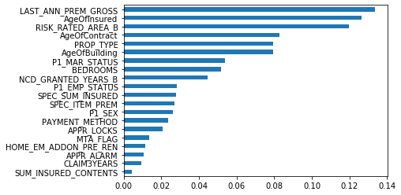

```python
import pandas as pd
import numpy as np

X = train_set_feature_all.iloc[:,0:30]  #independent columns
y = train_set_feature_all.iloc[:,-1]    #target column i.e price range

from sklearn.ensemble import ExtraTreesClassifier
import matplotlib.pyplot as plt

model = ExtraTreesClassifier()
model.fit(X,y)

print(model.feature_importances_) #use inbuilt class feature_importances of tree based classifiers

#plot graph of feature importances for better visualization
feat_importances = pd.Series(model.feature_importances_, index=X.columns)
feat_importances.nlargest(20).sort_values(ascending=True).plot(kind='barh')
plt.show()
```

#### 3. Correlation Matrix with Heatmap

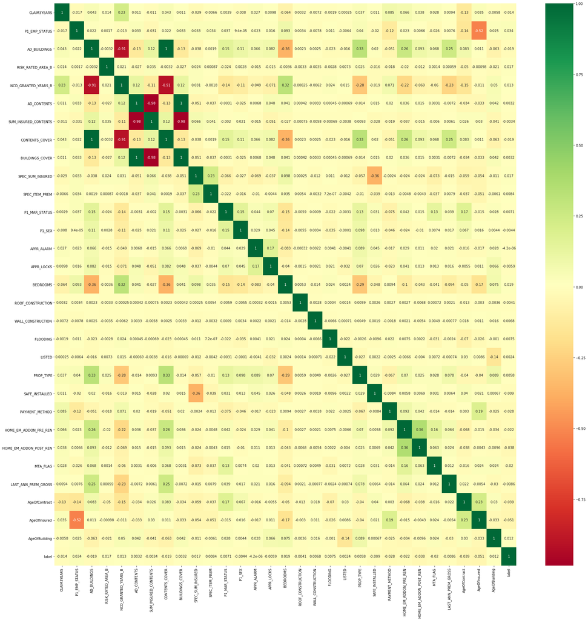

```python
import pandas as pd
import numpy as np
import seaborn as sns

train_set_fs_all = pd.read_excel("train_set_feature_all.xlsx")

X = train_set_fs_all.iloc[:,0:30]  #independent columns
y = train_set_fs_all.iloc[:,-1]    #target column i.e price range

#get correlations of each features in dataset
corrmat = train_set_fs_all.corr()
top_corr_features = corrmat.index
plt.figure(figsize=(31,31))

#plot heat map
g=sns.heatmap(train_set_fs_all[top_corr_features].corr(),annot=True,cmap="RdYlGn")


#svm = sn.heatmap(df_cm, annot=True,cmap='coolwarm', linecolor='white', linewidths=1)

figure_export = g.get_figure()
figure_export.savefig('Correlation Matrix with Heatmap_all.png', dpi=400)
```

## Used variables

#### Preparation of data

```python
train_set_feature_all.head(3)
```

|  | CLAIM3YEARS | P1_EMP_STATUS | AD_BUILDINGS | RISK_RATED_AREA_B | NCD_GRANTED_YEARS_B | AD_CONTENTS | SUM_INSURED_CONTENTS | CONTENTS_COVER | BUILDINGS_COVER | SPEC_SUM_INSURED | SPEC_ITEM_PREM | P1_MAR_STATUS | P1_SEX | APPR_ALARM | APPR_LOCKS | BEDROOMS | ROOF_CONSTRUCTION | WALL_CONSTRUCTION | FLOODING | LISTED | PROP_TYPE | SAFE_INSTALLED | PAYMENT_METHOD | HOME_EM_ADDON_PRE_REN | HOME_EM_ADDON_POST_REN | MTA_FLAG | LAST_ANN_PREM_GROSS | AgeOfContract | AgeOfInsured | … |
| --- | --- | --- | --- | --- | --- | --- | --- | --- | --- | --- | --- | --- | --- | --- | --- | --- | --- | --- | --- | --- | --- | --- | --- | --- | --- | --- | --- | --- | --- | --- |
| 188331 | 1 | 1 | 1 | 5.0 | 3.0 | 1 | 50000.0 | 1 | 1 | 0.0 | 0.0 | 1 | 1 | 2 | 1 | 2.0 | 11 | 15 | 1 | 3 | 9 | 2 | 1 | 2 | 2 | 2 | 185.28 | 14 | 68 | … |
| 58551 | 2 | 1 | 1 | 7.0 | 6.0 | 2 | 0.0 | 1 | 2 | 0.0 | 0.0 | 2 | 2 | 2 | 2 | 3.0 | 11 | 15 | 1 | 3 | 1 | 2 | 2 | 2 | 2 | 1 | 144.53 | 12 | 76 | … |
| 112870 | 2 | 1 | 1 | 10.0 | 6.0 | 1 | 50000.0 | 1 | 1 | 0.0 | 0.0 | 1 | 1 | 1 | 1 | 3.0 | 11 | 15 | 1 | 3 | 1 | 2 | 2 | 2 | 2 | 1 | 175.60 | 5 | 62 | … |

```python
train_set_feature_all.shape
```

```
(95518, 31)
```

#TOP 15 VARIABLES: LAST_ANN_PREM_GROSS AgeOfInsured RISK_RATED_AREA_B AgeOfContract AgeOfBuilding PROP_TYPE P1_MAR_STATUS BEDROOMS NCD_GRANTED_YEARS_B P1_EMP_STATUS SPEC_SUM_INSURED SPEC_ITEM_PREM P1_SEX PAYMENT_METHOD APPR_LOCKS + BEDROOMS_NEW APPR_ALARM CLAIM3YEARS

```python
train_set_feature_final = train_set_feature_all[["LAST_ANN_PREM_GROSS","AgeOfInsured","RISK_RATED_AREA_B","AgeOfContract","AgeOfBuilding","PROP_TYPE","P1_MAR_STATUS","BEDROOMS","NCD_GRANTED_YEARS_B","P1_EMP_STATUS","SPEC_SUM_INSURED","SPEC_ITEM_PREM","P1_SEX","PAYMENT_METHOD","APPR_LOCKS","label"]]
```

```python
train_set_feature_final.head(3)
```

|  | LAST_ANN_PREM_GROSS | AgeOfInsured | RISK_RATED_AREA_B | AgeOfContract | AgeOfBuilding | PROP_TYPE | P1_MAR_STATUS | BEDROOMS | NCD_GRANTED_YEARS_B | P1_EMP_STATUS | SPEC_SUM_INSURED | SPEC_ITEM_PREM | P1_SEX | PAYMENT_METHOD | APPR_LOCKS | label |
| --- | --- | --- | --- | --- | --- | --- | --- | --- | --- | --- | --- | --- | --- | --- | --- | --- |
| 188331 | 185.28 | 68 | 5.0 | 14 | 67 | 9 | 1 | 2.0 | 3.0 | 1 | 0.0 | 0.0 | 1 | 1 | 1 | 0.0 |
| 58551 | 144.53 | 76 | 7.0 | 12 | 13 | 1 | 2 | 3.0 | 6.0 | 1 | 0.0 | 0.0 | 2 | 2 | 2 | 0.0 |
| 112870 | 175.60 | 62 | 10.0 | 5 | 33 | 1 | 1 | 3.0 | 6.0 | 1 | 0.0 | 0.0 | 1 | 2 | 1 | 0.0 |

```python
train_set_feature_final.dtypes
```

```
LAST_ANN_PREM_GROSS    float64
AgeOfInsured             int64
RISK_RATED_AREA_B      float64
AgeOfContract            int64
AgeOfBuilding            int64
PROP_TYPE               object
P1_MAR_STATUS           object
BEDROOMS               float64
NCD_GRANTED_YEARS_B    float64
P1_EMP_STATUS           object
SPEC_SUM_INSURED       float64
SPEC_ITEM_PREM         float64
P1_SEX                  object
PAYMENT_METHOD          object
APPR_LOCKS              object
label                  float64
dtype: object
```

```python
train_set_feature_final.shape
```

```
(95518, 16)
```

```python
#train_set_feature_final.to_excel("train_set_feature_final.xlsx", index = False)
```

#### 1. Univariate Selection

```python
import pandas as pd
import numpy as np
from sklearn.feature_selection import SelectKBest
from sklearn.feature_selection import chi2


X = train_set_feature_final.iloc[:,0:15]  #independent columns
y = train_set_feature_final.iloc[:,-1]    #target column i.e price range
#apply SelectKBest class to extract top 10 best features

bestfeatures = SelectKBest(score_func=chi2, k=15)
fit = bestfeatures.fit(X,y)
dfscores = pd.DataFrame(fit.scores_)
dfcolumns = pd.DataFrame(X.columns)

#concat two dataframes for better visualization
featureScores = pd.concat([dfcolumns,dfscores],axis=1)
featureScores.columns = ['Specs','Score']  #naming the dataframe columns
print(featureScores.nlargest(15,'Score'))  #print 10 best features
```

```
                  Specs          Score
11       SPEC_ITEM_PREM  282679.685561
0   LAST_ANN_PREM_GROSS  144508.790195
10     SPEC_SUM_INSURED  137661.466195
3         AgeOfContract     438.534781
1          AgeOfInsured     411.703067
2     RISK_RATED_AREA_B     170.064435
4         AgeOfBuilding     168.426976
9         P1_EMP_STATUS      40.882379
8   NCD_GRANTED_YEARS_B      28.348587
5             PROP_TYPE      24.050815
13       PAYMENT_METHOD      16.755548
7              BEDROOMS       8.373053
6         P1_MAR_STATUS       3.307031
14           APPR_LOCKS       0.535550
12               P1_SEX       0.314380
```

#### 2. Feature Importance

```
[0.16178694 0.1455768  0.13937103 0.08670972 0.08011685 0.08134076
 0.05784894 0.04858351 0.05533838 0.02703997 0.02903901 0.02891343
 0.02153519 0.02114258 0.01565689]
```

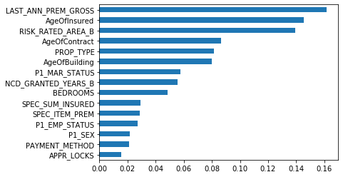

```python
import pandas as pd
import numpy as np


X = train_set_feature_final.iloc[:,0:15]  #independent columns
y = train_set_feature_final.iloc[:,-1]    #target column i.e price range

from sklearn.ensemble import ExtraTreesClassifier
import matplotlib.pyplot as plt

model = ExtraTreesClassifier()
model.fit(X,y)

print(model.feature_importances_) #use inbuilt class feature_importances of tree based classifiers

#plot graph of feature importances for better visualization
feat_importances = pd.Series(model.feature_importances_, index=X.columns)
feat_importances.nlargest(15).sort_values(ascending=True).plot(kind='barh')
plt.show()
```

#### 3. Correlation Matrix with Heatmap

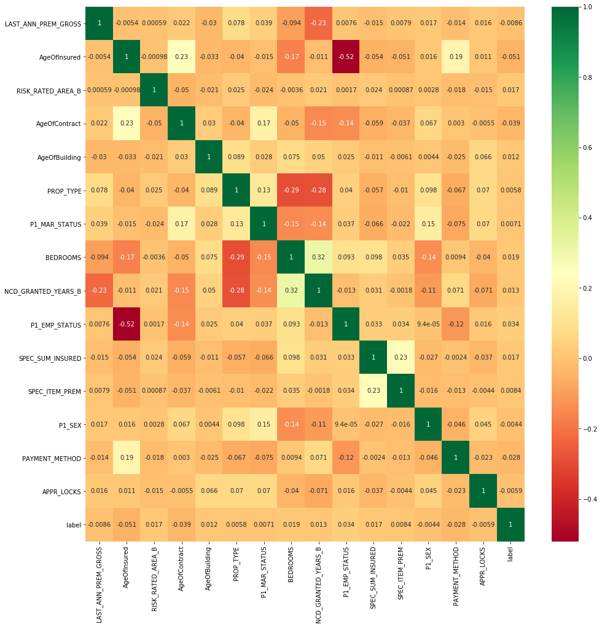

```python
import pandas as pd
import numpy as np
import seaborn as sns

train_set_fs_final = pd.read_excel("train_set_feature_final.xlsx")

X = train_set_fs_final.iloc[:,0:15]  #independent columns
y = train_set_fs_final.iloc[:,-1]    #target column i.e price range

#get correlations of each features in dataset
corrmat = train_set_fs_final.corr()
top_corr_features = corrmat.index
plt.figure(figsize=(16,16))

#plot heat map
g=sns.heatmap(train_set_fs_final[top_corr_features].corr(),annot=True,cmap="RdYlGn")

#svm = sn.heatmap(df_cm, annot=True,cmap='coolwarm', linecolor='white', linewidths=1)

figure_export = g.get_figure()
figure_export.savefig('Correlation Matrix with Heatmap_final.png', dpi=400)
```

## Binning with Decistion Tree Classifier

#### Data Preparation

```python
train_set.head(3)
```

|  | COVER_START | CLAIM3YEARS | P1_EMP_STATUS | AD_BUILDINGS | RISK_RATED_AREA_B | NCD_GRANTED_YEARS_B | AD_CONTENTS | SUM_INSURED_CONTENTS | CONTENTS_COVER | BUILDINGS_COVER | SPEC_SUM_INSURED | SPEC_ITEM_PREM | P1_DOB | P1_MAR_STATUS | P1_SEX | APPR_ALARM | APPR_LOCKS | BEDROOMS | ROOF_CONSTRUCTION | WALL_CONSTRUCTION | FLOODING | LISTED | PROP_TYPE | SAFE_INSTALLED | YEARBUILT | PAYMENT_METHOD | HOME_EM_ADDON_PRE_REN | HOME_EM_ADDON_POST_REN | MTA_FLAG | … |
| --- | --- | --- | --- | --- | --- | --- | --- | --- | --- | --- | --- | --- | --- | --- | --- | --- | --- | --- | --- | --- | --- | --- | --- | --- | --- | --- | --- | --- | --- | --- |
| 188331 | 1999-01-03 | Y | R | Y | 5 | 3.0 | Y | 50000.0 | Y | Y | 0.0 | 0.0 | 1944-06-25 | O | M | N | Y | 2.0 | 11 | 15 | Y | 3 | 9 | N | 1946-01-01 | PureDD | N | N | N | … |
| 58551 | 2000-10-12 | N | R | Y | 7 | 6.0 | N | 0.0 | Y | N | 0.0 | 0.0 | 1936-03-20 | M | F | N | N | 3.0 | 11 | 15 | Y | 3 | 1 | N | 2000-01-01 | NonDD | N | N | Y | … |
| 112870 | 2007-01-29 | N | R | Y | 10 | 6.0 | Y | 50000.0 | Y | Y | 0.0 | 0.0 | 1950-06-30 | O | M | Y | Y | 3.0 | 11 | 15 | Y | 3 | 1 | N | 1980-01-01 | NonDD | N | N | Y | … |

```python
test_set.head(3)
```

|  | COVER_START | CLAIM3YEARS | P1_EMP_STATUS | AD_BUILDINGS | RISK_RATED_AREA_B | NCD_GRANTED_YEARS_B | AD_CONTENTS | SUM_INSURED_CONTENTS | CONTENTS_COVER | BUILDINGS_COVER | SPEC_SUM_INSURED | SPEC_ITEM_PREM | P1_DOB | P1_MAR_STATUS | P1_SEX | APPR_ALARM | APPR_LOCKS | BEDROOMS | ROOF_CONSTRUCTION | WALL_CONSTRUCTION | FLOODING | LISTED | PROP_TYPE | SAFE_INSTALLED | YEARBUILT | PAYMENT_METHOD | HOME_EM_ADDON_PRE_REN | HOME_EM_ADDON_POST_REN | MTA_FLAG | … |
| --- | --- | --- | --- | --- | --- | --- | --- | --- | --- | --- | --- | --- | --- | --- | --- | --- | --- | --- | --- | --- | --- | --- | --- | --- | --- | --- | --- | --- | --- | --- |
| 232876 | 2010-01-01 | N | R | Y | 11 | 6.0 | Y | 50000.0 | Y | Y | 2000.0 | 9.84 | 1939-08-22 | M | F | N | N | 3.0 | 11 | 15 | Y | 3 | 2 | N | 1960-01-01 | DD-Other | Y | N | Y | … |
| 96835 | 2006-01-03 | N | R | Y | NaN | 6.0 | Y | 50000.0 | Y | Y | 0.0 | 0.00 | 1920-02-16 | P | F | N | Y | 2.0 | 11 | 15 | Y | 3 | 1 | N | 1946-01-01 | PureDD | Y | N | N | … |
| 21222 | 2010-05-01 | N | R | Y | 13 | 6.0 | Y | 50000.0 | Y | Y | 0.0 | 0.00 | 1933-09-13 | M | M | N | Y | 3.0 | 11 | 15 | Y | 3 | 19 | N | 1920-01-01 | PureDD | Y | N | Y | … |

```python
train_set.shape
```

```
(95529, 37)
```

```python
test_set.shape
```

```
(40942, 37)
```

#TOP 15 VARIABLES: LAST_ANN_PREM_GROSS AgeOfInsured RISK_RATED_AREA_B AgeOfContract AgeOfBuilding PROP_TYPE P1_MAR_STATUS BEDROOMS NCD_GRANTED_YEARS_B P1_EMP_STATUS SPEC_SUM_INSURED SPEC_ITEM_PREM P1_SEX PAYMENT_METHOD APPR_LOCKS + BEDROOMS_NEW APPR_ALARM CLAIM3YEARS

```python
#dropping unimportant columns

train_set = train_set.drop(columns=['COVER_START','AD_BUILDINGS','AD_CONTENTS','SUM_INSURED_CONTENTS','BUILDINGS_COVER','P1_DOB','ROOF_CONSTRUCTION','WALL_CONSTRUCTION','FLOODING','LISTED','SAFE_INSTALLED','YEARBUILT','HOME_EM_ADDON_PRE_REN','HOME_EM_ADDON_POST_REN','MTA_FLAG','POL_STATUS'])
```

```python
train_set.head(3)
```

|  | CLAIM3YEARS | P1_EMP_STATUS | RISK_RATED_AREA_B | NCD_GRANTED_YEARS_B | CONTENTS_COVER | SPEC_SUM_INSURED | SPEC_ITEM_PREM | P1_MAR_STATUS | P1_SEX | APPR_ALARM | APPR_LOCKS | BEDROOMS | PROP_TYPE | PAYMENT_METHOD | LAST_ANN_PREM_GROSS | Police | label | AgeOfContract | AgeOfInsured | AgeOfBuilding | BEDROOMS_NEW |
| --- | --- | --- | --- | --- | --- | --- | --- | --- | --- | --- | --- | --- | --- | --- | --- | --- | --- | --- | --- | --- | --- |
| 188331 | Y | R | 5 | 3.0 | Y | 0.0 | 0.0 | O | M | N | Y | 2.0 | 9 | PureDD | 185.28 | P188332 | 0.0 | 14 | 68 | 67 | 2 |
| 58551 | N | R | 7 | 6.0 | Y | 0.0 | 0.0 | M | F | N | N | 3.0 | 1 | NonDD | 144.53 | P058552 | 0.0 | 12 | 76 | 13 | 3 |
| 112870 | N | R | 10 | 6.0 | Y | 0.0 | 0.0 | O | M | Y | Y | 3.0 | 1 | NonDD | 175.60 | P112871 | 0.0 | 5 | 62 | 33 | 3 |

```python
train_set.dtypes
```

```
CLAIM3YEARS             object
P1_EMP_STATUS           object
RISK_RATED_AREA_B       object
NCD_GRANTED_YEARS_B    float64
CONTENTS_COVER          object
SPEC_SUM_INSURED       float64
SPEC_ITEM_PREM         float64
P1_MAR_STATUS           object
P1_SEX                  object
APPR_ALARM              object
APPR_LOCKS              object
BEDROOMS               float64
PROP_TYPE               object
PAYMENT_METHOD          object
LAST_ANN_PREM_GROSS    float64
Police                  object
label                  float64
AgeOfContract            int64
AgeOfInsured             int64
AgeOfBuilding            int64
BEDROOMS_NEW            object
dtype: object
```

```python
#reordering our dataset: policyID, numerical, categorical and dummy varianles, then target

train_set = train_set[["Police","LAST_ANN_PREM_GROSS","AgeOfInsured","AgeOfContract","AgeOfBuilding","BEDROOMS","BEDROOMS_NEW","NCD_GRANTED_YEARS_B","SPEC_SUM_INSURED","SPEC_ITEM_PREM","P1_EMP_STATUS","RISK_RATED_AREA_B","P1_MAR_STATUS","P1_SEX","PROP_TYPE","PAYMENT_METHOD","CLAIM3YEARS","APPR_LOCKS","APPR_ALARM","CONTENTS_COVER","label"]]
```

```python
train_set.head(3)
```

|  | Police | LAST_ANN_PREM_GROSS | AgeOfInsured | AgeOfContract | AgeOfBuilding | BEDROOMS | BEDROOMS_NEW | NCD_GRANTED_YEARS_B | SPEC_SUM_INSURED | SPEC_ITEM_PREM | P1_EMP_STATUS | RISK_RATED_AREA_B | P1_MAR_STATUS | P1_SEX | PROP_TYPE | PAYMENT_METHOD | CLAIM3YEARS | APPR_LOCKS | APPR_ALARM | CONTENTS_COVER | label |
| --- | --- | --- | --- | --- | --- | --- | --- | --- | --- | --- | --- | --- | --- | --- | --- | --- | --- | --- | --- | --- | --- |
| 188331 | P188332 | 185.28 | 68 | 14 | 67 | 2.0 | 2 | 3.0 | 0.0 | 0.0 | R | 5 | O | M | 9 | PureDD | Y | Y | N | Y | 0.0 |
| 58551 | P058552 | 144.53 | 76 | 12 | 13 | 3.0 | 3 | 6.0 | 0.0 | 0.0 | R | 7 | M | F | 1 | NonDD | N | N | N | Y | 0.0 |
| 112870 | P112871 | 175.60 | 62 | 5 | 33 | 3.0 | 3 | 6.0 | 0.0 | 0.0 | R | 10 | O | M | 1 | NonDD | N | Y | Y | Y | 0.0 |

```python
#dropping unimportant columns

test_set = test_set.drop(columns=['COVER_START','AD_BUILDINGS','AD_CONTENTS','SUM_INSURED_CONTENTS','BUILDINGS_COVER','P1_DOB','ROOF_CONSTRUCTION','WALL_CONSTRUCTION','FLOODING','LISTED','SAFE_INSTALLED','YEARBUILT','HOME_EM_ADDON_PRE_REN','HOME_EM_ADDON_POST_REN','MTA_FLAG','POL_STATUS'])
```

```python
test_set.head(3)
```

|  | CLAIM3YEARS | P1_EMP_STATUS | RISK_RATED_AREA_B | NCD_GRANTED_YEARS_B | CONTENTS_COVER | SPEC_SUM_INSURED | SPEC_ITEM_PREM | P1_MAR_STATUS | P1_SEX | APPR_ALARM | APPR_LOCKS | BEDROOMS | PROP_TYPE | PAYMENT_METHOD | LAST_ANN_PREM_GROSS | Police | label | AgeOfContract | AgeOfInsured | AgeOfBuilding | BEDROOMS_NEW |
| --- | --- | --- | --- | --- | --- | --- | --- | --- | --- | --- | --- | --- | --- | --- | --- | --- | --- | --- | --- | --- | --- |
| 232876 | N | R | 11 | 6.0 | Y | 2000.0 | 9.84 | M | F | N | N | 3.0 | 2 | DD-Other | 215.40 | P232877 | 0.0 | 3 | 73 | 53 | 3 |
| 96835 | N | R | NaN | 6.0 | Y | 0.0 | 0.00 | P | F | N | Y | 2.0 | 1 | PureDD | 209.95 | P096836 | 0.0 | 6 | 92 | 67 | 2 |
| 21222 | N | R | 13 | 6.0 | Y | 0.0 | 0.00 | M | M | N | Y | 3.0 | 19 | PureDD | 228.66 | P021223 | 0.0 | 2 | 79 | 93 | 3 |

```python
test_set.dtypes
```

```
CLAIM3YEARS             object
P1_EMP_STATUS           object
RISK_RATED_AREA_B       object
NCD_GRANTED_YEARS_B    float64
CONTENTS_COVER          object
SPEC_SUM_INSURED       float64
SPEC_ITEM_PREM         float64
P1_MAR_STATUS           object
P1_SEX                  object
APPR_ALARM              object
APPR_LOCKS              object
BEDROOMS               float64
PROP_TYPE               object
PAYMENT_METHOD          object
LAST_ANN_PREM_GROSS    float64
Police                  object
label                  float64
AgeOfContract            int64
AgeOfInsured             int64
AgeOfBuilding            int64
BEDROOMS_NEW            object
dtype: object
```

```python
#reordering our dataset: policyID, numerical, categorical and dummy varianles, then target

test_set = test_set[["Police","LAST_ANN_PREM_GROSS","AgeOfInsured","AgeOfContract","AgeOfBuilding","BEDROOMS","BEDROOMS_NEW","NCD_GRANTED_YEARS_B","SPEC_SUM_INSURED","SPEC_ITEM_PREM","P1_EMP_STATUS","RISK_RATED_AREA_B","P1_MAR_STATUS","P1_SEX","PROP_TYPE","PAYMENT_METHOD","CLAIM3YEARS","APPR_LOCKS","APPR_ALARM","CONTENTS_COVER","label"]]
```

```python
test_set.head(3)
```

|  | Police | LAST_ANN_PREM_GROSS | AgeOfInsured | AgeOfContract | AgeOfBuilding | BEDROOMS | BEDROOMS_NEW | NCD_GRANTED_YEARS_B | SPEC_SUM_INSURED | SPEC_ITEM_PREM | P1_EMP_STATUS | RISK_RATED_AREA_B | P1_MAR_STATUS | P1_SEX | PROP_TYPE | PAYMENT_METHOD | CLAIM3YEARS | APPR_LOCKS | APPR_ALARM | CONTENTS_COVER | label |
| --- | --- | --- | --- | --- | --- | --- | --- | --- | --- | --- | --- | --- | --- | --- | --- | --- | --- | --- | --- | --- | --- |
| 232876 | P232877 | 215.40 | 73 | 3 | 53 | 3.0 | 3 | 6.0 | 2000.0 | 9.84 | R | 11 | M | F | 2 | DD-Other | N | N | N | Y | 0.0 |
| 96835 | P096836 | 209.95 | 92 | 6 | 67 | 2.0 | 2 | 6.0 | 0.0 | 0.00 | R | NaN | P | F | 1 | PureDD | N | Y | N | Y | 0.0 |
| 21222 | P021223 | 228.66 | 79 | 2 | 93 | 3.0 | 3 | 6.0 | 0.0 | 0.00 | R | 13 | M | M | 19 | PureDD | N | Y | N | Y | 0.0 |

#### fill NaN values in RISK_RATED_AREA_B for both data, train_set and test_set

```python
data.shape
```

```
(136471, 37)
```

```python
data.isnull().sum()
```

```
COVER_START                   0
CLAIM3YEARS                   0
P1_EMP_STATUS                 0
AD_BUILDINGS                  0
RISK_RATED_AREA_B         39148
NCD_GRANTED_YEARS_B           0
AD_CONTENTS                   0
SUM_INSURED_CONTENTS          0
CONTENTS_COVER                0
BUILDINGS_COVER               0
SPEC_SUM_INSURED              0
SPEC_ITEM_PREM                0
P1_DOB                        0
P1_MAR_STATUS                 0
P1_SEX                        0
APPR_ALARM                    0
APPR_LOCKS                    0
BEDROOMS                      0
ROOF_CONSTRUCTION             0
WALL_CONSTRUCTION             0
FLOODING                      0
LISTED                        0
PROP_TYPE                     0
SAFE_INSTALLED                0
YEARBUILT                     0
PAYMENT_METHOD                0
HOME_EM_ADDON_PRE_REN         0
HOME_EM_ADDON_POST_REN        0
MTA_FLAG                      0
LAST_ANN_PREM_GROSS           0
POL_STATUS                    0
Police                        0
label                         0
AgeOfContract                 0
AgeOfInsured                  0
AgeOfBuilding                 0
BEDROOMS_NEW                  0
dtype: int64
```

```python
data['RISK_RATED_AREA_B'].fillna(method = 'ffill', inplace = True)
```

```python
data['RISK_RATED_AREA_B'].fillna(method = 'bfill', inplace = True)
```

```python
data.isnull().sum()
```

```
COVER_START               0
CLAIM3YEARS               0
P1_EMP_STATUS             0
AD_BUILDINGS              0
RISK_RATED_AREA_B         0
NCD_GRANTED_YEARS_B       0
AD_CONTENTS               0
SUM_INSURED_CONTENTS      0
CONTENTS_COVER            0
BUILDINGS_COVER           0
SPEC_SUM_INSURED          0
SPEC_ITEM_PREM            0
P1_DOB                    0
P1_MAR_STATUS             0
P1_SEX                    0
APPR_ALARM                0
APPR_LOCKS                0
BEDROOMS                  0
ROOF_CONSTRUCTION         0
WALL_CONSTRUCTION         0
FLOODING                  0
LISTED                    0
PROP_TYPE                 0
SAFE_INSTALLED            0
YEARBUILT                 0
PAYMENT_METHOD            0
HOME_EM_ADDON_PRE_REN     0
HOME_EM_ADDON_POST_REN    0
MTA_FLAG                  0
LAST_ANN_PREM_GROSS       0
POL_STATUS                0
Police                    0
label                     0
AgeOfContract             0
AgeOfInsured              0
AgeOfBuilding             0
BEDROOMS_NEW              0
dtype: int64
```

```python
train_set.shape
```

```
(95529, 21)
```

```python
train_set.isnull().sum()
```

```
Police                     0
LAST_ANN_PREM_GROSS        0
AgeOfInsured               0
AgeOfContract              0
AgeOfBuilding              0
BEDROOMS                   0
BEDROOMS_NEW               0
NCD_GRANTED_YEARS_B        0
SPEC_SUM_INSURED           0
SPEC_ITEM_PREM             0
P1_EMP_STATUS              0
RISK_RATED_AREA_B      27473
P1_MAR_STATUS              0
P1_SEX                     0
PROP_TYPE                  0
PAYMENT_METHOD             0
CLAIM3YEARS                0
APPR_LOCKS                 0
APPR_ALARM                 0
CONTENTS_COVER             0
label                      0
dtype: int64
```

```python
train_set['RISK_RATED_AREA_B'].fillna(method = 'ffill', inplace = True)
```

```python
train_set['RISK_RATED_AREA_B'].fillna(method = 'bfill', inplace = True)
```

```python
train_set.isnull().sum()
```

```
Police                 0
LAST_ANN_PREM_GROSS    0
AgeOfInsured           0
AgeOfContract          0
AgeOfBuilding          0
BEDROOMS               0
BEDROOMS_NEW           0
NCD_GRANTED_YEARS_B    0
SPEC_SUM_INSURED       0
SPEC_ITEM_PREM         0
P1_EMP_STATUS          0
RISK_RATED_AREA_B      0
P1_MAR_STATUS          0
P1_SEX                 0
PROP_TYPE              0
PAYMENT_METHOD         0
CLAIM3YEARS            0
APPR_LOCKS             0
APPR_ALARM             0
CONTENTS_COVER         0
label                  0
dtype: int64
```

```python
test_set.shape
```

```
(40942, 21)
```

```python
test_set.isnull().sum()
```

```
Police                     0
LAST_ANN_PREM_GROSS        0
AgeOfInsured               0
AgeOfContract              0
AgeOfBuilding              0
BEDROOMS                   0
BEDROOMS_NEW               0
NCD_GRANTED_YEARS_B        0
SPEC_SUM_INSURED           0
SPEC_ITEM_PREM             0
P1_EMP_STATUS              0
RISK_RATED_AREA_B      11675
P1_MAR_STATUS              0
P1_SEX                     0
PROP_TYPE                  0
PAYMENT_METHOD             0
CLAIM3YEARS                0
APPR_LOCKS                 0
APPR_ALARM                 0
CONTENTS_COVER             0
label                      0
dtype: int64
```

```python
test_set['RISK_RATED_AREA_B'].fillna(method = 'ffill', inplace = True)
```

```python
test_set['RISK_RATED_AREA_B'].fillna(method = 'bfill', inplace = True)
```

```python
test_set.isnull().sum()
```

```
Police                 0
LAST_ANN_PREM_GROSS    0
AgeOfInsured           0
AgeOfContract          0
AgeOfBuilding          0
BEDROOMS               0
BEDROOMS_NEW           0
NCD_GRANTED_YEARS_B    0
SPEC_SUM_INSURED       0
SPEC_ITEM_PREM         0
P1_EMP_STATUS          0
RISK_RATED_AREA_B      0
P1_MAR_STATUS          0
P1_SEX                 0
PROP_TYPE              0
PAYMENT_METHOD         0
CLAIM3YEARS            0
APPR_LOCKS             0
APPR_ALARM             0
CONTENTS_COVER         0
label                  0
dtype: int64
```

```python
train_set.head(3)
```

|  | Police | LAST_ANN_PREM_GROSS | AgeOfInsured | AgeOfContract | AgeOfBuilding | BEDROOMS | BEDROOMS_NEW | NCD_GRANTED_YEARS_B | SPEC_SUM_INSURED | SPEC_ITEM_PREM | P1_EMP_STATUS | RISK_RATED_AREA_B | P1_MAR_STATUS | P1_SEX | PROP_TYPE | PAYMENT_METHOD | CLAIM3YEARS | APPR_LOCKS | APPR_ALARM | CONTENTS_COVER | label |
| --- | --- | --- | --- | --- | --- | --- | --- | --- | --- | --- | --- | --- | --- | --- | --- | --- | --- | --- | --- | --- | --- |
| 188331 | P188332 | 185.28 | 68 | 14 | 67 | 2.0 | 2 | 3.0 | 0.0 | 0.0 | R | 5.0 | O | M | 9 | PureDD | Y | Y | N | Y | 0.0 |
| 58551 | P058552 | 144.53 | 76 | 12 | 13 | 3.0 | 3 | 6.0 | 0.0 | 0.0 | R | 7.0 | M | F | 1 | NonDD | N | N | N | Y | 0.0 |
| 112870 | P112871 | 175.60 | 62 | 5 | 33 | 3.0 | 3 | 6.0 | 0.0 | 0.0 | R | 10.0 | O | M | 1 | NonDD | N | Y | Y | Y | 0.0 |

```python
test_set.head(3)
```

|  | Police | LAST_ANN_PREM_GROSS | AgeOfInsured | AgeOfContract | AgeOfBuilding | BEDROOMS | BEDROOMS_NEW | NCD_GRANTED_YEARS_B | SPEC_SUM_INSURED | SPEC_ITEM_PREM | P1_EMP_STATUS | RISK_RATED_AREA_B | P1_MAR_STATUS | P1_SEX | PROP_TYPE | PAYMENT_METHOD | CLAIM3YEARS | APPR_LOCKS | APPR_ALARM | CONTENTS_COVER | label |
| --- | --- | --- | --- | --- | --- | --- | --- | --- | --- | --- | --- | --- | --- | --- | --- | --- | --- | --- | --- | --- | --- |
| 232876 | P232877 | 215.40 | 73 | 3 | 53 | 3.0 | 3 | 6.0 | 2000.0 | 9.84 | R | 11.0 | M | F | 2 | DD-Other | N | N | N | Y | 0.0 |
| 96835 | P096836 | 209.95 | 92 | 6 | 67 | 2.0 | 2 | 6.0 | 0.0 | 0.00 | R | 11.0 | P | F | 1 | PureDD | N | Y | N | Y | 0.0 |
| 21222 | P021223 | 228.66 | 79 | 2 | 93 | 3.0 | 3 | 6.0 | 0.0 | 0.00 | R | 13.0 | M | M | 19 | PureDD | N | Y | N | Y | 0.0 |

```python
train_set['RISK_RATED_AREA_B'].mode()
```

```
0    0.0
dtype: float64
```

### We could also replace the NA values with e.g. the mode of RISK_RATED_AREA_B train_set = train_set.copy() test_set = test_set.copy() data['RISK_RATED_AREA_B'].fillna((data['RISK_RATED_AREA_B'].mode()), inplace=True) train_set['RISK_RATED_AREA_B'].fillna((train_set['RISK_RATED_AREA_B'].mode()), inplace=True) test_set['RISK_RATED_AREA_B'].fillna((test_set['RISK_RATED_AREA_B'].mode()), inplace=True) print(data['RISK_RATED_AREA_B'].describe()) print('\n') print('# of Missing values in column = ',data['RISK_RATED_AREA_B'].isnull().sum())

#### Decision Tree - LAST_ANN_PREM_GROSS

```python
print(data['LAST_ANN_PREM_GROSS'].describe())
```

```
count    136471.000000
mean        930.535728
std        4378.452162
min        -329.730000
25%         125.310000
50%         181.400000
75%         242.315000
max       44191.000000
Name: LAST_ANN_PREM_GROSS, dtype: float64
```

```python
negatives = len(data.loc[(data.LAST_ANN_PREM_GROSS < 0)])
```

```python
print(negatives)
```

```
14
```

```python
#removing negative premium contracts on all used datasets: data, train_set, test_set

data = data[~(data['LAST_ANN_PREM_GROSS'] < 0)]
```

```python
train_set = train_set[~(train_set['LAST_ANN_PREM_GROSS'] < 0)]
```

```python
test_set = test_set[~(test_set['LAST_ANN_PREM_GROSS'] < 0)]
```

```python
print(data['LAST_ANN_PREM_GROSS'].describe())
```

```
count    136457.000000
mean        930.636159
std        4378.665462
min           0.000000
25%         125.320000
50%         181.410000
75%         242.320000
max       44191.000000
Name: LAST_ANN_PREM_GROSS, dtype: float64
```

```python
print(train_set['LAST_ANN_PREM_GROSS'].describe())
```

```
count    95518.000000
mean       942.342314
std       4409.685284
min          0.330000
25%        125.000000
50%        181.170000
75%        242.450000
max      44191.000000
Name: LAST_ANN_PREM_GROSS, dtype: float64
```

```python
print(test_set['LAST_ANN_PREM_GROSS'].describe())
```

```
count    40939.000000
mean       903.323609
std       4305.351316
min          0.000000
25%        126.150000
50%        181.990000
75%        242.060000
max      44168.000000
Name: LAST_ANN_PREM_GROSS, dtype: float64
```

```
[Text(502.20000000000005, 428.08500000000004, 'X[0] <= 273.325\ngini = 0.061\nsamples = 95518\nvalue = [92497, 3021]'),
```

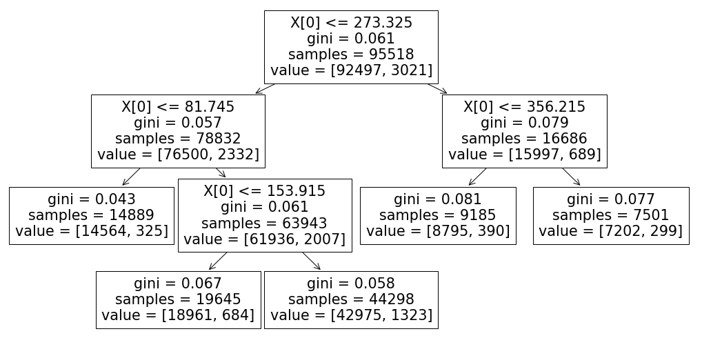

```python
# Decision Tree Classifier
from sklearn import tree

X_CL = train_set.dropna(axis=0, subset=['LAST_ANN_PREM_GROSS'])[['LAST_ANN_PREM_GROSS']]
Y_CL = train_set.dropna(axis=0, subset=['LAST_ANN_PREM_GROSS'])['label']

fig, ax = plt.subplots(figsize=(18, 9))  # whatever size you want
clf = tree.DecisionTreeClassifier(min_samples_leaf=7500, max_depth=3)
clf = clf.fit(X_CL, Y_CL)

tree.plot_tree(clf)
```

```
                      label
                  Contracts Targets Cancellation rate
LAPG_Cat
[0,81.745]            14889   325.0          0.021828
[81.745,153.915]      19645   684.0          0.034818
[153.915,273.325]     44298  1323.0          0.029866
[273.325,356.215]      9185   390.0          0.042461
[356.215,44191]        7501   299.0          0.039861
```

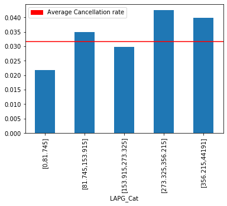

```python
# Define edges for binning (from Decision tree)

train_set = train_set.copy()
test_set = test_set.copy()

cuts = [0,81.745,153.915,273.325,356.215,44191]
labels = ['[0,81.745]','[81.745,153.915]','[153.915,273.325]','[273.325,356.215]','[356.215,44191]']

# Create new binned variable (in both Train and Test sets)
train_set['LAPG_Cat'] = pd.cut(train_set['LAST_ANN_PREM_GROSS'], bins=cuts, labels=labels)
test_set['LAPG_Cat'] = pd.cut(test_set['LAST_ANN_PREM_GROSS'], bins=cuts, labels=labels)

# Pivot table showing cancellation rates for all bins
print(train_set.groupby('LAPG_Cat').agg({'label':['count','sum','mean']}).rename(columns={'count':'Contracts','sum':'Targets','mean':'Cancellation rate'}))

age_Cancellation = train_set.pivot_table(index="LAPG_Cat",values="label")
age_Cancellation.plot.bar()
label = mpatches.Patch(color='red', label='Average Cancellation rate')
plt.legend(handles=[label])
plt.axhline(y=len(train_set[train_set['label']==1])/len(train_set), color='red')

plt.show()
```

#### Decision Tree - AgeOfInsured

```python
print(data['AgeOfInsured'].describe())
```

```
count    136457.000000
mean         73.064966
std          11.077990
min          21.000000
25%          65.000000
50%          74.000000
75%          81.000000
max         123.000000
Name: AgeOfInsured, dtype: float64
```

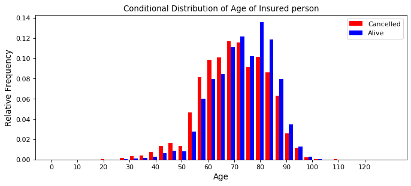

```python
### Inspect AgeOfInsured
# Distribution of Age of Insured conditional on Target

train_set = train_set.copy()
test_set = test_set.copy()

x1 = data.loc[data['label']==1, 'AgeOfInsured'] #Cancelled
x0 = data.loc[data['label']==0, 'AgeOfInsured'] #Alive

bins = np.linspace(0, 130, 36)
figure(num=None, figsize=(10, 4), dpi=80, facecolor='w', edgecolor='k')

x1_w = np.empty(x1.shape)
x1_w.fill(1/x1.shape[0])
x0_w = np.empty(x0.shape)
x0_w.fill(1/x0.shape[0])

plt.hist([x1, x0], bins, weights=[x1_w, x0_w], label=['Cancelled', 'Alive'], color=['red','blue'])
plt.legend(loc='upper right')
plt.xlabel('Age', fontsize=12)
plt.ylabel('Relative Frequency', fontsize=12)
plt.title('Conditional Distribution of Age of Insured person')
plt.xticks(np.arange(0, 130, step=10))

plt.show()
```

```
[Text(502.20000000000005, 428.08500000000004, 'X[0] <= 68.5\ngini = 0.061\nsamples = 95518\nvalue = [92497, 3021]'),
```

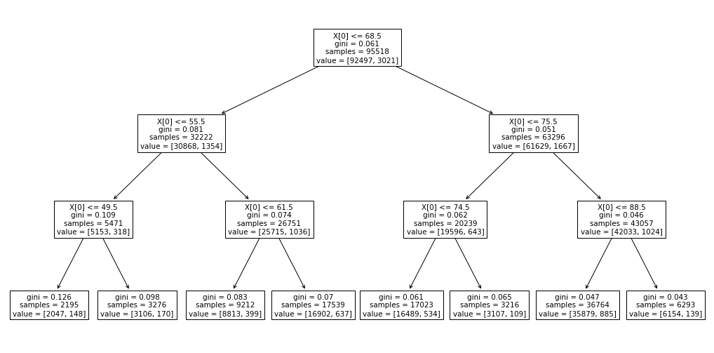

```python
# Decision Tree Classifier
from sklearn import tree

X_CL = train_set.dropna(axis=0, subset=['AgeOfInsured'])[['AgeOfInsured']]
Y_CL = train_set.dropna(axis=0, subset=['AgeOfInsured'])['label']

fig, ax = plt.subplots(figsize=(18, 9))  # whatever size you want
clf = tree.DecisionTreeClassifier(min_samples_leaf=2000, max_depth=3)
clf = clf.fit(X_CL, Y_CL)

tree.plot_tree(clf)
```

```
                label
            Contracts Targets Cancellation rate
AOI_Cat
[0,49.5]         2195   148.0          0.067426
[49.5,55.5]      3276   170.0          0.051893
[55.5,61.5]      9212   399.0          0.043313
[61.5,68.5]     17539   637.0          0.036319
[68.5,74.5]     17023   534.0          0.031369
[74.5,75.5]      3216   109.0          0.033893
[75.5,88.5]     36764   885.0          0.024072
[88.5,123]       6293   139.0          0.022088
```

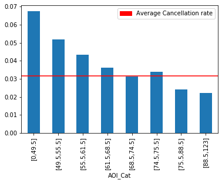

```python
# Define edges for binning (from Decision tree)

train_set = train_set.copy()
test_set = test_set.copy()

cuts = [0,49.5,55.5,61.5,68.5,74.5,75.5,88.5,123]
labels = ['[0,49.5]','[49.5,55.5]','[55.5,61.5]','[61.5,68.5]','[68.5,74.5]','[74.5,75.5]','[75.5,88.5]','[88.5,123]']

# Create new binned variable (in both Train and Test sets)
train_set['AOI_Cat'] = pd.cut(train_set['AgeOfInsured'], bins=cuts, labels=labels)
test_set['AOI_Cat'] = pd.cut(test_set['AgeOfInsured'], bins=cuts, labels=labels)

# Pivot table showing cancellation rates for all bins
print(train_set.groupby('AOI_Cat').agg({'label':['count','sum','mean']}).rename(columns={'count':'Contracts','sum':'Targets','mean':'Cancellation rate'}))

age_Cancellation = train_set.pivot_table(index="AOI_Cat",values="label")
age_Cancellation.plot.bar()
label = mpatches.Patch(color='red', label='Average Cancellation rate')
plt.legend(handles=[label])
plt.axhline(y=len(train_set[train_set['label']==1])/len(train_set), color='red')

plt.show()
```

#### Decision Tree - AgeOfContract

```python
print(data['AgeOfContract'].describe())
```

```
count    136457.000000
mean          5.500568
std           4.086959
min           0.000000
25%           2.000000
50%           4.000000
75%           8.000000
max          20.000000
Name: AgeOfContract, dtype: float64
```

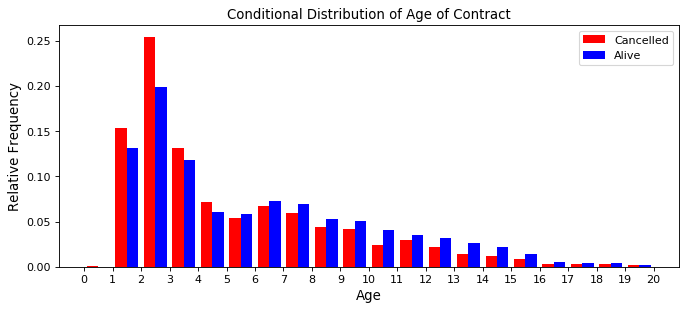

```python
### Inspect AgeofContract
# Distribution of Age of Contract conditional on Target

x1 = data.loc[data['label']==1, 'AgeOfContract'] #Cancelled
x0 = data.loc[data['label']==0, 'AgeOfContract'] #Alive

bins = np.linspace(0, 20, 21)
figure(num=None, figsize=(10, 4), dpi=80, facecolor='w', edgecolor='k')

x1_w = np.empty(x1.shape)
x1_w.fill(1/x1.shape[0])
x0_w = np.empty(x0.shape)
x0_w.fill(1/x0.shape[0])

plt.hist([x1, x0], bins, weights=[x1_w, x0_w], label=['Cancelled', 'Alive'], color=['red','blue'])
plt.legend(loc='upper right')
plt.xlabel('Age', fontsize=12)
plt.ylabel('Relative Frequency', fontsize=12)
plt.title('Conditional Distribution of Age of Contract')
plt.xticks(np.arange(0, 21, step=1))

plt.show()
```

##### Decision Tree #1 (minimum leaf size + max. depth) - "Strong Restrictions"

```
[Text(502.20000000000005, 428.08500000000004, 'X[0] <= 5.5\ngini = 0.061\nsamples = 95518\nvalue = [92497, 3021]'),
```

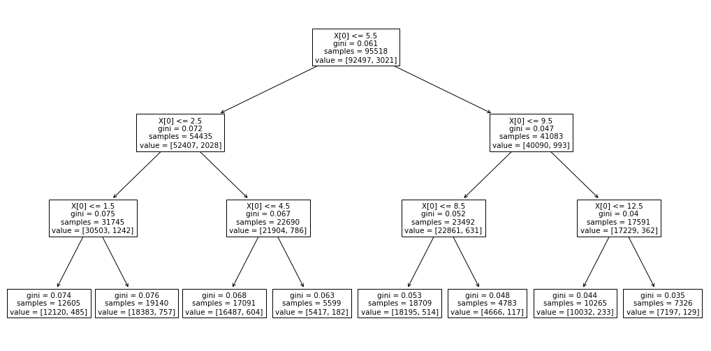

```python
# Decision Tree Classifier
from sklearn import tree

X_CL = train_set.dropna(axis=0, subset=['AgeOfContract'])[['AgeOfContract']]
Y_CL = train_set.dropna(axis=0, subset=['AgeOfContract'])['label']

fig, ax = plt.subplots(figsize=(18, 9))  # whatever size you want
clf = tree.DecisionTreeClassifier(min_samples_leaf=2000, max_depth=3)
clf = clf.fit(X_CL, Y_CL)

tree.plot_tree(clf)
```

```
               label
           Contracts Targets Cancellation rate
AOC_Cat_SR
[0,1.5]        12604   484.0          0.038401
[1.5,2.5]      19140   757.0          0.039551
[2.5,4.5]      17091   604.0          0.035340
[4.5,5.5]       5599   182.0          0.032506
[5.5,8.5]      18709   514.0          0.027473
[8.5,9.5]       4783   117.0          0.024462
[9.5,12.5]     10265   233.0          0.022698
[12.5,20]       7326   129.0          0.017609
```

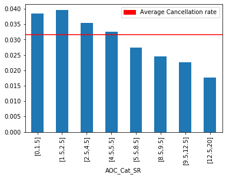

```python
# Define edges for binning (from Decision tree)

train_set = train_set.copy()
test_set = test_set.copy()

cuts = [0,1.5,2.5,4.5,5.5,8.5,9.5,12.5,20]
labels = ['[0,1.5]','[1.5,2.5]','[2.5,4.5]','[4.5,5.5]','[5.5,8.5]','[8.5,9.5]','[9.5,12.5]','[12.5,20]']

# Create new binned variable (in both Train and Test sets)
train_set['AOC_Cat_SR'] = pd.cut(train_set['AgeOfContract'], bins=cuts, labels=labels)
test_set['AOC_Cat_SR'] = pd.cut(test_set['AgeOfContract'], bins=cuts, labels=labels)

# Pivot table showing cancellation rates for all bins
print(train_set.groupby('AOC_Cat_SR').agg({'label':['count','sum','mean']}).rename(columns={'count':'Contracts','sum':'Targets','mean':'Cancellation rate'}))

age_Cancellation = train_set.pivot_table(index="AOC_Cat_SR",values="label")
age_Cancellation.plot.bar()
label = mpatches.Patch(color='red', label='Average Cancellation rate')
plt.legend(handles=[label])
plt.axhline(y=len(train_set[train_set['label']==1])/len(train_set), color='red')

plt.show()
```

##### Decision Tree #2 (maximum number of leaves, max. depth and minimum leaf size) - "Weak restriction"

```
[Text(436.12105263157895, 440.31600000000003, 'X[0] <= 5.5\ngini = 0.061\nsamples = 95518\nvalue = [92497, 3021]'),
```

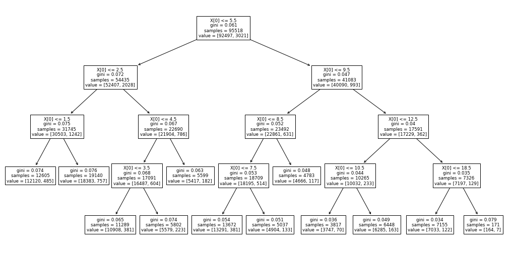

```python
# Decision Tree Classifier
from sklearn import tree

X_CL = train_set.dropna(axis=0, subset=['AgeOfContract'])[['AgeOfContract']]
Y_CL = train_set.dropna(axis=0, subset=['AgeOfContract'])['label']

fig, ax = plt.subplots(figsize=(18, 9))  # whatever size you want
clf = tree.DecisionTreeClassifier(max_leaf_nodes=12, max_depth=4, min_samples_leaf=100)
clf = clf.fit(X_CL, Y_CL)

tree.plot_tree(clf)
```

```
                label
            Contracts Targets Cancellation rate
AOC_Cat_WR
[0,1.5]         12604   484.0          0.038401
[1.5,2.5]       19140   757.0          0.039551
[2.5,3.5]       11289   381.0          0.033750
[3.5,4.5]        5802   223.0          0.038435
[4.5,5.5]        5599   182.0          0.032506
[5.5,7.5]       13672   381.0          0.027867
[7.5,8.5]        5037   133.0          0.026405
[8.5,9.5]        4783   117.0          0.024462
[9.5,10.5]       3817    70.0          0.018339
[10.5,12.5]      6448   163.0          0.025279
[12.5,18.5]      7155   122.0          0.017051
[18.5,20]         171     7.0          0.040936
```

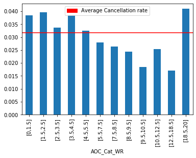

```python
# Define edges for binning (from Decision tree)

train_set = train_set.copy()
test_set = test_set.copy()

cuts = [0,1.5,2.5,3.5,4.5,5.5,7.5,8.5,9.5,10.5,12.5,18.5,20]
labels = ['[0,1.5]','[1.5,2.5]','[2.5,3.5]','[3.5,4.5]','[4.5,5.5]','[5.5,7.5]','[7.5,8.5]','[8.5,9.5]','[9.5,10.5]','[10.5,12.5]','[12.5,18.5]','[18.5,20]']

# Create new binned variable (in both Train and Test sets)
train_set['AOC_Cat_WR'] = pd.cut(train_set['AgeOfContract'], bins=cuts, labels=labels)
test_set['AOC_Cat_WR'] = pd.cut(test_set['AgeOfContract'], bins=cuts, labels=labels)

# Pivot table showing cancellation rates for all bins
print(train_set.groupby('AOC_Cat_WR').agg({'label':['count','sum','mean']}).rename(columns={'count':'Contracts','sum':'Targets','mean':'Cancellation rate'}))

age_Cancellation = train_set.pivot_table(index="AOC_Cat_WR",values="label")
age_Cancellation.plot.bar()
label = mpatches.Patch(color='red', label='Average Cancellation rate')
plt.legend(handles=[label])
plt.axhline(y=len(train_set[train_set['label']==1])/len(train_set), color='red')

plt.show()
```

```
[Text(406.5428571428572, 454.2942857142857, 'X[0] <= 5.5\ngini = 0.061\nsamples = 95518\nvalue = [92497, 3021]'),
```

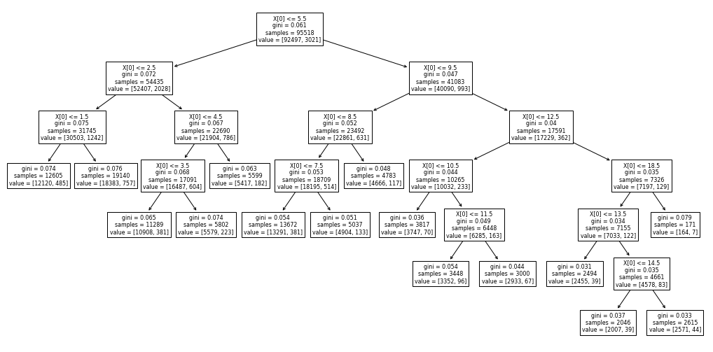

```python
# Decision Tree Classifier
from sklearn import tree

X_CL = train_set.dropna(axis=0, subset=['AgeOfContract'])[['AgeOfContract']]
Y_CL = train_set.dropna(axis=0, subset=['AgeOfContract'])['label']

fig, ax = plt.subplots(figsize=(18, 9))  # whatever size you want
clf = tree.DecisionTreeClassifier(max_leaf_nodes=15, min_samples_leaf=100)
clf = clf.fit(X_CL, Y_CL)

tree.plot_tree(clf)
```

```
                label
            Contracts Targets Cancellation rate
AOC_Cat_OF
[0,1.5]         12604   484.0          0.038401
[1.5,2.5]       19140   757.0          0.039551
[2.5,3.5]       11289   381.0          0.033750
[3.5,4.5]        5802   223.0          0.038435
[4.5,5.5]        5599   182.0          0.032506
[5.5,7.5]       13672   381.0          0.027867
[7.5,8.5]        5037   133.0          0.026405
[8.5,9.5]        4783   117.0          0.024462
[9.5,10.5]       3817    70.0          0.018339
[10.5,11.5]      3448    96.0          0.027842
[11.5,12.5]      3000    67.0          0.022333
[12.5,13.5]      2494    39.0          0.015638
[13.5,14.5]      2046    39.0          0.019062
[14.5,18.5]      2615    44.0          0.016826
[18.5,20]         171     7.0          0.040936
```

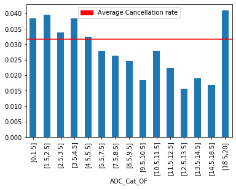

```python
# Define edges for binning (from Decision tree)

train_set = train_set.copy()
test_set = test_set.copy()

cuts = [0,1.5,2.5,3.5,4.5,5.5,7.5,8.5,9.5,10.5,11.5,12.5,13.5,14.5,18.5,20]
labels = ['[0,1.5]','[1.5,2.5]','[2.5,3.5]','[3.5,4.5]','[4.5,5.5]','[5.5,7.5]','[7.5,8.5]','[8.5,9.5]','[9.5,10.5]','[10.5,11.5]','[11.5,12.5]','[12.5,13.5]','[13.5,14.5]','[14.5,18.5]','[18.5,20]']

# Create new binned variable (in both Train and Test sets)
train_set['AOC_Cat_OF'] = pd.cut(train_set['AgeOfContract'], bins=cuts, labels=labels)
test_set['AOC_Cat_OF'] = pd.cut(test_set['AgeOfContract'], bins=cuts, labels=labels)

# Pivot table showing cancellation rates for all bins
print(train_set.groupby('AOC_Cat_OF').agg({'label':['count','sum','mean']}).rename(columns={'count':'Contracts','sum':'Targets','mean':'Cancellation rate'}))

age_Cancellation = train_set.pivot_table(index="AOC_Cat_OF",values="label")
age_Cancellation.plot.bar()
label = mpatches.Patch(color='red', label='Average Cancellation rate')
plt.legend(handles=[label])
plt.axhline(y=len(train_set[train_set['label']==1])/len(train_set), color='red')

plt.show()
```

#### Decision Tree - AgeOfBuilding

```python
print(data['AgeOfBuilding'].describe())
```

```
count    136457.000000
mean         67.671772
std          28.251568
min          13.000000
25%          53.000000
50%          67.000000
75%          93.000000
max         264.000000
Name: AgeOfBuilding, dtype: float64
```

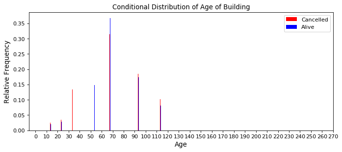

```python
### Inspect AgeOfBuilding
# Distribution of Age of Building conditional on Target

x1 = data.loc[data['label']==1, 'AgeOfBuilding'] #Cancelled
x0 = data.loc[data['label']==0, 'AgeOfBuilding'] #Alive

bins = np.linspace(0, 122, 123)
figure(num=None, figsize=(10, 4), dpi=80, facecolor='w', edgecolor='k')

x1_w = np.empty(x1.shape)
x1_w.fill(1/x1.shape[0])
x0_w = np.empty(x0.shape)
x0_w.fill(1/x0.shape[0])

plt.hist([x1, x0], bins, weights=[x1_w, x0_w], label=['Cancelled', 'Alive'], color=['red','blue'])
plt.legend(loc='upper right')
plt.xlabel('Age', fontsize=12)
plt.ylabel('Relative Frequency', fontsize=12)
plt.title('Conditional Distribution of Age of Building')
plt.xticks(np.arange(0, 271, step=10))

plt.show()
```

```
[Text(602.6400000000001, 407.7, 'X[0] <= 88.0\ngini = 0.061\nsamples = 95518\nvalue = [92497, 3021]'),
```

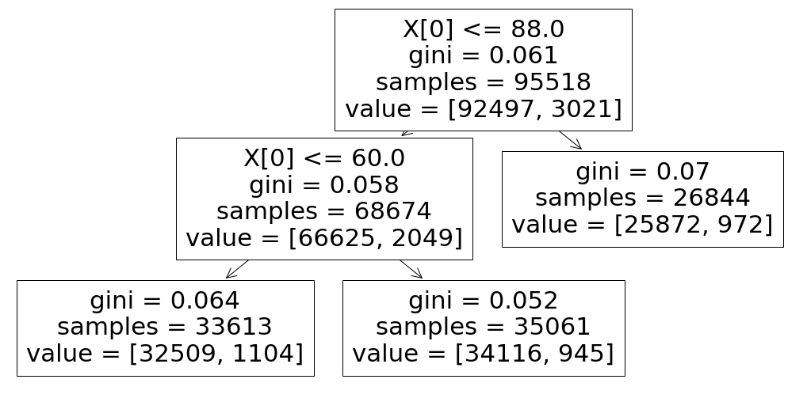

```python
# Decision Tree Classifier
from sklearn import tree

X_CL = train_set.dropna(axis=0, subset=['AgeOfBuilding'])[['AgeOfBuilding']]
Y_CL = train_set.dropna(axis=0, subset=['AgeOfBuilding'])['label']

fig, ax = plt.subplots(figsize=(18, 9))  # whatever size you want
clf = tree.DecisionTreeClassifier(min_samples_leaf=15000, max_depth=3)
clf = clf.fit(X_CL, Y_CL)

tree.plot_tree(clf)
```

```
             label
         Contracts Targets Cancellation rate
AOB_Cat
[0,60]       33613  1104.0          0.032844
[60,88]      35061   945.0          0.026953
[88,264]     26844   972.0          0.036209
```

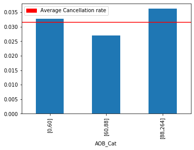

```python
# Define edges for binning (from Decision tree)

train_set = train_set.copy()
test_set = test_set.copy()

cuts = [0,60,88,264]
labels = ['[0,60]','[60,88]','[88,264]']

# Create new binned variable (in both Train and Test sets)
train_set['AOB_Cat'] = pd.cut(train_set['AgeOfBuilding'], bins=cuts, labels=labels)
test_set['AOB_Cat'] = pd.cut(test_set['AgeOfBuilding'], bins=cuts, labels=labels)

# Pivot table showing cancellation rates for all bins
print(train_set.groupby('AOB_Cat').agg({'label':['count','sum','mean']}).rename(columns={'count':'Contracts','sum':'Targets','mean':'Cancellation rate'}))

age_Cancellation = train_set.pivot_table(index="AOB_Cat",values="label")
age_Cancellation.plot.bar()
label = mpatches.Patch(color='red', label='Average Cancellation rate')
plt.legend(handles=[label])
plt.axhline(y=len(train_set[train_set['label']==1])/len(train_set), color='red')

plt.show()
```

#### Decision Tree - SPEC_SUM_INSURED

```python
print(data['SPEC_SUM_INSURED'].describe())
```

```
count    136457.000000
mean        288.301311
std        1205.684852
min           0.000000
25%           0.000000
50%           0.000000
75%           0.000000
max       35000.000000
Name: SPEC_SUM_INSURED, dtype: float64
```

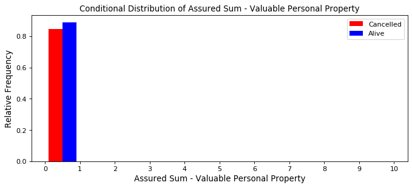

```python
### Inspect SPEC_SUM_INSURED
# Distribution of Assured Sum - Valuable Personal Property conditional on Target

x1 = data.loc[data['label']==1, 'SPEC_SUM_INSURED'] #Cancelled
x0 = data.loc[data['label']==0, 'SPEC_SUM_INSURED'] #Alive

bins = np.linspace(0, 10, 11)
figure(num=None, figsize=(10, 4), dpi=80, facecolor='w', edgecolor='k')

x1_w = np.empty(x1.shape)
x1_w.fill(1/x1.shape[0])
x0_w = np.empty(x0.shape)
x0_w.fill(1/x0.shape[0])

plt.hist([x1, x0], bins, weights=[x1_w, x0_w], label=['Cancelled', 'Alive'], color=['red','blue'])
plt.legend(loc='upper right')
plt.xlabel('Assured Sum - Valuable Personal Property', fontsize=12)
plt.ylabel('Relative Frequency', fontsize=12)
plt.title('Conditional Distribution of Assured Sum - Valuable Personal Property')
plt.xticks(np.arange(0, 11, step=1))

plt.show()
```

```
[Text(334.8, 428.08500000000004, 'X[0] <= 119.5\ngini = 0.1\nsamples = 95518\nvalue = [92497, 3021]'),
```

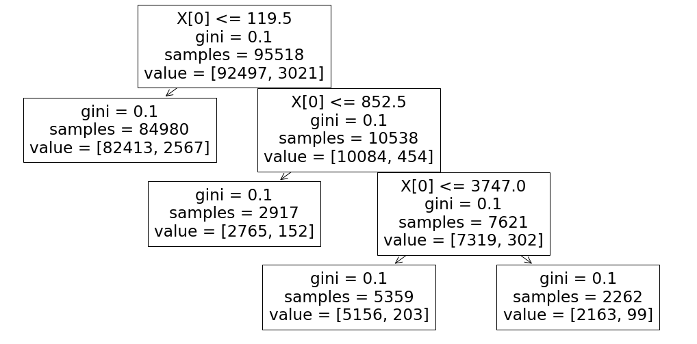

```python
# Decision Tree Classifier
from sklearn import tree

X_CL = train_set.dropna(axis=0, subset=['SPEC_SUM_INSURED'])[['SPEC_SUM_INSURED']]
Y_CL = train_set.dropna(axis=0, subset=['SPEC_SUM_INSURED'])['label']

fig, ax = plt.subplots(figsize=(18, 9))  # whatever size you want
clf = tree.DecisionTreeClassifier(min_samples_leaf=2000, max_depth=3)
clf = clf.fit(X_CL, Y_CL)

tree.plot_tree(clf, precision=1)
```

```
                  label
              Contracts Targets Cancellation rate
SSI_Cat
[0,119.5]         84980  2567.0          0.030207
[119.5,852.5]      2917   152.0          0.052108
[852.5,3747]       5359   203.0          0.037880
[3747,35000]       2262    99.0          0.043767
```

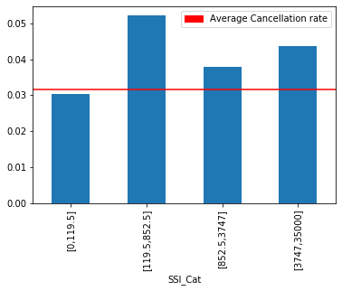

```python
# Define edges for binning (from Decision tree)

train_set = train_set.copy()
test_set = test_set.copy()

cuts = [-np.inf,119.5,852.5,3747,35000]
labels = ['[0,119.5]','[119.5,852.5]','[852.5,3747]','[3747,35000]']

# Create new binned variable (in both Train and Test sets)
train_set['SSI_Cat'] = pd.cut(train_set['SPEC_SUM_INSURED'], bins=cuts, labels=labels)
test_set['SSI_Cat'] = pd.cut(test_set['SPEC_SUM_INSURED'], bins=cuts, labels=labels)

# Pivot table showing cancellation rates for all bins
print(train_set.groupby('SSI_Cat').agg({'label':['count','sum','mean']}).rename(columns={'count':'Contracts','sum':'Targets','mean':'Cancellation rate'}))

age_Cancellation = train_set.pivot_table(index="SSI_Cat",values="label")
age_Cancellation.plot.bar()
label = mpatches.Patch(color='red', label='Average Cancellation rate')
plt.legend(handles=[label])
plt.axhline(y=len(train_set[train_set['label']==1])/len(train_set), color='red')

plt.show()
```

#### Decision Tree - SPEC_ITEM_PREM

```python
print(data['SPEC_ITEM_PREM'].describe())
```

```
count    136457.000000
mean       1212.827752
std        7097.100549
min           0.000000
25%           0.000000
50%           0.000000
75%           0.000000
max       44196.000000
Name: SPEC_ITEM_PREM, dtype: float64
```

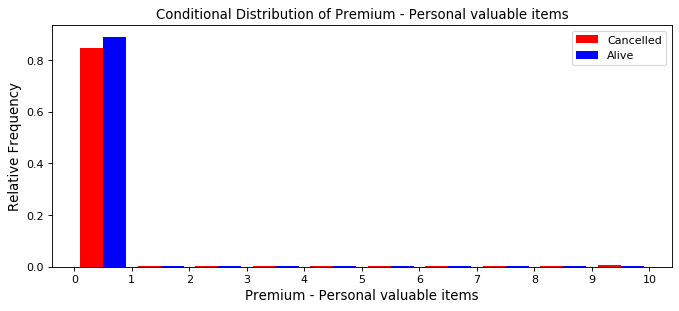

```python
### Inspect SPEC_ITEM_PREM
# Distribution of Premium - Personal valuable items conditional on Target

x1 = data.loc[data['label']==1, 'SPEC_ITEM_PREM'] #Cancelled
x0 = data.loc[data['label']==0, 'SPEC_ITEM_PREM'] #Alive

bins = np.linspace(0, 10, 11)
figure(num=None, figsize=(10, 4), dpi=80, facecolor='w', edgecolor='k')

x1_w = np.empty(x1.shape)
x1_w.fill(1/x1.shape[0])
x0_w = np.empty(x0.shape)
x0_w.fill(1/x0.shape[0])

plt.hist([x1, x0], bins, weights=[x1_w, x0_w], label=['Cancelled', 'Alive'], color=['red','blue'])
plt.legend(loc='upper right')
plt.xlabel('Premium - Personal valuable items', fontsize=12)
plt.ylabel('Relative Frequency', fontsize=12)
plt.title('Conditional Distribution of Premium - Personal valuable items')
plt.xticks(np.arange(0, 11, step=1))

plt.show()
```

```
[Text(334.8, 428.08500000000004, 'X[0] <= 2.6\ngini = 0.1\nsamples = 95518\nvalue = [92497, 3021]'),
```

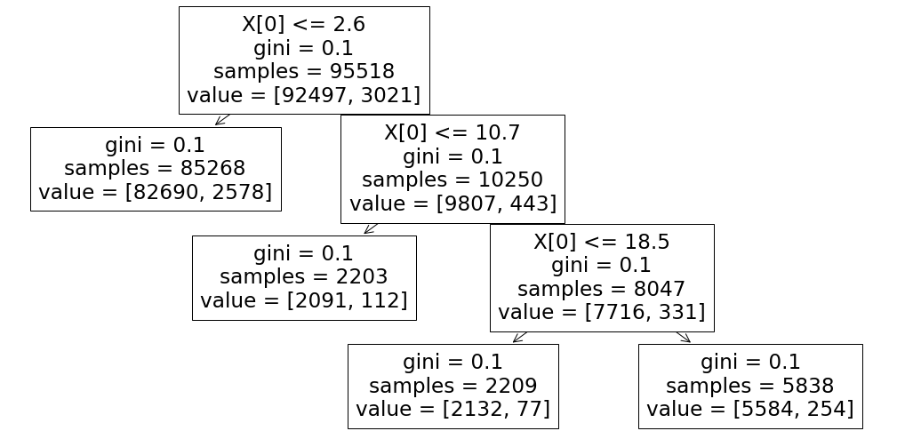

```python
# Decision Tree Classifier
from sklearn import tree

X_CL = train_set.dropna(axis=0, subset=['SPEC_ITEM_PREM'])[['SPEC_ITEM_PREM']]
Y_CL = train_set.dropna(axis=0, subset=['SPEC_ITEM_PREM'])['label']

fig, ax = plt.subplots(figsize=(18, 9))  # whatever size you want
clf = tree.DecisionTreeClassifier(min_samples_leaf=2000, max_depth=3)
clf = clf.fit(X_CL, Y_CL)

tree.plot_tree(clf, precision=1)
```

```
                 label
             Contracts Targets Cancellation rate
SIP_Cat
[0,2.6]          85257  2578.0          0.030238
[2.6,10.7]        2219   112.0          0.050473
[10.7,18.5]       2167    77.0          0.035533
[18.5,44196]      5875   254.0          0.043234
```

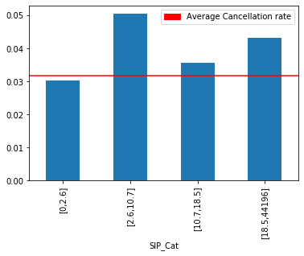

```python
# Define edges for binning (from Decision tree)

train_set = train_set.copy()
test_set = test_set.copy()

cuts = [-np.inf,2.6,10.7,18.5,44196]
labels = ['[0,2.6]','[2.6,10.7]','[10.7,18.5]','[18.5,44196]']

# Create new binned variable (in both Train and Test sets)
train_set['SIP_Cat'] = pd.cut(train_set['SPEC_ITEM_PREM'], bins=cuts, labels=labels)
test_set['SIP_Cat'] = pd.cut(test_set['SPEC_ITEM_PREM'], bins=cuts, labels=labels)

# Pivot table showing cancellation rates for all bins
print(train_set.groupby('SIP_Cat').agg({'label':['count','sum','mean']}).rename(columns={'count':'Contracts','sum':'Targets','mean':'Cancellation rate'}))

age_Cancellation = train_set.pivot_table(index="SIP_Cat",values="label")
age_Cancellation.plot.bar()
label = mpatches.Patch(color='red', label='Average Cancellation rate')
plt.legend(handles=[label])
plt.axhline(y=len(train_set[train_set['label']==1])/len(train_set), color='red')

plt.show()
```

```python
train_set.head()
```

|  | Police | LAST_ANN_PREM_GROSS | AgeOfInsured | AgeOfContract | AgeOfBuilding | BEDROOMS | BEDROOMS_NEW | NCD_GRANTED_YEARS_B | SPEC_SUM_INSURED | SPEC_ITEM_PREM | P1_EMP_STATUS | RISK_RATED_AREA_B | P1_MAR_STATUS | P1_SEX | PROP_TYPE | PAYMENT_METHOD | CLAIM3YEARS | APPR_LOCKS | APPR_ALARM | CONTENTS_COVER | label | LAPG_Cat | AOI_Cat | AOC_Cat_SR | AOC_Cat_WR | AOC_Cat_OF | AOB_Cat | SSI_Cat | SIP_Cat |
| --- | --- | --- | --- | --- | --- | --- | --- | --- | --- | --- | --- | --- | --- | --- | --- | --- | --- | --- | --- | --- | --- | --- | --- | --- | --- | --- | --- | --- | --- |
| 188331 | P188332 | 185.28 | 68 | 14 | 67 | 2.0 | 2 | 3.0 | 0.0 | 0.0 | R | 5.0 | O | M | 9 | PureDD | Y | Y | N | Y | 0.0 | [153.915,273.325] | [61.5,68.5] | [12.5,20] | [12.5,18.5] | [13.5,14.5] | [60,88] | [0,119.5] | [0,2.6] |
| 58551 | P058552 | 144.53 | 76 | 12 | 13 | 3.0 | 3 | 6.0 | 0.0 | 0.0 | R | 7.0 | M | F | 1 | NonDD | N | N | N | Y | 0.0 | [81.745,153.915] | [75.5,88.5] | [9.5,12.5] | [10.5,12.5] | [11.5,12.5] | [0,60] | [0,119.5] | [0,2.6] |
| 112870 | P112871 | 175.60 | 62 | 5 | 33 | 3.0 | 3 | 6.0 | 0.0 | 0.0 | R | 10.0 | O | M | 1 | NonDD | N | Y | Y | Y | 0.0 | [153.915,273.325] | [61.5,68.5] | [4.5,5.5] | [4.5,5.5] | [4.5,5.5] | [0,60] | [0,119.5] | [0,2.6] |
| 130441 | P130442 | 162.14 | 67 | 1 | 53 | 3.0 | 3 | 6.0 | 800.0 | 43953.0 | R | 9.0 | M | M | 51 | NonDD | N | Y | Y | Y | 0.0 | [153.915,273.325] | [61.5,68.5] | [0,1.5] | [0,1.5] | [0,1.5] | [0,60] | [119.5,852.5] | [18.5,44196] |
| 102081 | P102082 | 127.29 | 91 | 1 | 33 | 3.0 | 3 | 7.0 | 0.0 | 0.0 | R | 17.0 | O | F | 2 | NonDD | N | N | N | Y | 0.0 | [81.745,153.915] | [88.5,123] | [0,1.5] | [0,1.5] | [0,1.5] | [0,60] | [0,119.5] | [0,2.6] |

```python
data['P1_EMP_STATUS'].unique()
```

```
array(['E', 'R', 'S', 'N', 'U', 'A', 'H', 'I', 'V', 'F', 'C'],
      dtype=object)
```

```python
data['RISK_RATED_AREA_B'].unique()
```

```
array([25.,  5.,  1.,  0.,  8., 17.,  7., 32., 15., 12., 13.,  3., 14.,
       19., 18., 10.,  9., 23.,  4.,  2., 11., 28., 26.,  6., 29., 16.,
       35., 27., 31., 20., 22., 24., 21., 37., 42., 34., 39., 33., 30.,
       96., 44., 46., 36., 45., 38., 43., 92., 41., 91., 40., 47., 97.])
```

```python
data['P1_MAR_STATUS'].unique()
```

```
array(['M', 'S', 'W', 'D', 'P', 'O', 'A', 'C', 'B', 'N'], dtype=object)
```

```python
data['P1_SEX'].unique()
```

```
array(['M', 'F', 'N'], dtype=object)
```

```python
data['PROP_TYPE'].unique()
```

```
array([2.0, 9.0, 19.0, 1.0, 7.0, 10.0, 25.0, 26.0, 18.0, 48.0, 32.0, 16.0,
       17.0, 4.0, 47.0, 3.0, 29.0, 22.0, 53.0, 52.0, 37.0, 40.0, 45.0,
       30.0, 51.0, 27.0, 23.0, 24.0, 38.0, 20.0, 31.0, 39.0, 44.0, 21.0,
       8.0, 28.0], dtype=object)
```

```python
data['PAYMENT_METHOD'].unique()
```

```
array(['PureDD', 'NonDD', 'DD-Other'], dtype=object)
```

```python
data['APPR_LOCKS'].unique()
```

```
array(['N', 'Y'], dtype=object)
```

```python
data['BEDROOMS'].unique()
```

```
array([3., 2., 1., 4., 5., 6., 7.])
```

```python
data['BEDROOMS_NEW'].unique()
```

```
array([3.0, 2.0, 1.0], dtype=object)
```

```python
data['NCD_GRANTED_YEARS_B'].unique()
```

```
array([6., 0., 7., 3., 4., 2., 1., 5., 8., 9.])
```

```python
data['APPR_ALARM'].unique()
```

```
array(['N', 'Y'], dtype=object)
```

```python
data['CLAIM3YEARS'].unique()
```

```
array(['N', 'Y'], dtype=object)
```

```python
data['CONTENTS_COVER'].unique()
```

```
array(['Y', 'N'], dtype=object)
```

## Logistic regression

#### Finalize Data Structure for Logistic Regression in Python

```python
train_set['P1_EMP_STATUS_Orig']=train_set['P1_EMP_STATUS']
train_set = pd.get_dummies(train_set, prefix='ES_', prefix_sep='_', columns=['P1_EMP_STATUS'], drop_first=True)
train_set = pd.get_dummies(train_set, prefix='RRA_', prefix_sep='_', columns=['RISK_RATED_AREA_B'], drop_first=True) #not used in Logistic Regression
train_set = pd.get_dummies(train_set, prefix='MS_', prefix_sep='_', columns=['P1_MAR_STATUS'], drop_first=True)
train_set = pd.get_dummies(train_set, prefix='SE_', prefix_sep='_', columns=['P1_SEX'], drop_first=True)
train_set = pd.get_dummies(train_set, prefix='PT_', prefix_sep='_', columns=['PROP_TYPE'], drop_first=True) #not used in Logistic Regression
train_set = pd.get_dummies(train_set, prefix='PM_', prefix_sep='_', columns=['PAYMENT_METHOD'], drop_first=True)
train_set = pd.get_dummies(train_set, prefix='AL_', prefix_sep='_', columns=['APPR_LOCKS'], drop_first=True)
train_set = pd.get_dummies(train_set, prefix='BR_', prefix_sep='_', columns=['BEDROOMS'], drop_first=True)
train_set = pd.get_dummies(train_set, prefix='BRN_', prefix_sep='_', columns=['BEDROOMS_NEW'], drop_first=True)
train_set = pd.get_dummies(train_set, prefix='NCD_', prefix_sep='_', columns=['NCD_GRANTED_YEARS_B'], drop_first=True)
train_set = pd.get_dummies(train_set, prefix='AA_', prefix_sep='_', columns=['APPR_ALARM'], drop_first=True)
train_set = pd.get_dummies(train_set, prefix='CL_', prefix_sep='_', columns=['CLAIM3YEARS'], drop_first=True)
train_set = pd.get_dummies(train_set, prefix='CC_', prefix_sep='_', columns=['CONTENTS_COVER'], drop_first=True)
train_set = pd.get_dummies(train_set, columns=['LAPG_Cat'], drop_first=True)
train_set = pd.get_dummies(train_set, columns=['AOI_Cat'], drop_first=True)
train_set = pd.get_dummies(train_set, columns=['AOC_Cat_SR'], drop_first=True)
train_set = pd.get_dummies(train_set, columns=['AOC_Cat_WR'], drop_first=True)
train_set = pd.get_dummies(train_set, columns=['AOC_Cat_OF'], drop_first=True)
train_set = pd.get_dummies(train_set, columns=['AOB_Cat'], drop_first=True)
train_set = pd.get_dummies(train_set, columns=['SSI_Cat'], drop_first=True) #not used in Logistic Regression
train_set = pd.get_dummies(train_set, columns=['SIP_Cat'], drop_first=True) #not used in Logistic Regression

test_set['P1_EMP_STATUS_Orig']=test_set['P1_EMP_STATUS']
test_set = pd.get_dummies(test_set, prefix='ES_', prefix_sep='_', columns=['P1_EMP_STATUS'], drop_first=True)
test_set = pd.get_dummies(test_set, prefix='RRA_', prefix_sep='_', columns=['RISK_RATED_AREA_B'], drop_first=True) #not used in Logistic Regression
test_set = pd.get_dummies(test_set, prefix='MS_', prefix_sep='_', columns=['P1_MAR_STATUS'], drop_first=True)
test_set = pd.get_dummies(test_set, prefix='SE_', prefix_sep='_', columns=['P1_SEX'], drop_first=True)
test_set = pd.get_dummies(test_set, prefix='PT_', prefix_sep='_', columns=['PROP_TYPE'], drop_first=True) #not used in Logistic Regression
test_set = pd.get_dummies(test_set, prefix='PM_', prefix_sep='_', columns=['PAYMENT_METHOD'], drop_first=True)
test_set = pd.get_dummies(test_set, prefix='AL_', prefix_sep='_', columns=['APPR_LOCKS'], drop_first=True)
test_set = pd.get_dummies(test_set, prefix='BR_', prefix_sep='_', columns=['BEDROOMS'], drop_first=True)
test_set = pd.get_dummies(test_set, prefix='BRN_', prefix_sep='_', columns=['BEDROOMS_NEW'], drop_first=True)
test_set = pd.get_dummies(test_set, prefix='NCD_', prefix_sep='_', columns=['NCD_GRANTED_YEARS_B'], drop_first=True)
test_set = pd.get_dummies(test_set, prefix='AA_', prefix_sep='_', columns=['APPR_ALARM'], drop_first=True)
test_set = pd.get_dummies(test_set, prefix='CL_', prefix_sep='_', columns=['CLAIM3YEARS'], drop_first=True)
test_set = pd.get_dummies(test_set, prefix='CC_', prefix_sep='_', columns=['CONTENTS_COVER'], drop_first=True)
test_set = pd.get_dummies(test_set, columns=['LAPG_Cat'], drop_first=True)
test_set = pd.get_dummies(test_set, columns=['AOI_Cat'], drop_first=True)
test_set = pd.get_dummies(test_set, columns=['AOC_Cat_SR'], drop_first=True)
test_set = pd.get_dummies(test_set, columns=['AOC_Cat_WR'], drop_first=True)
test_set = pd.get_dummies(test_set, columns=['AOC_Cat_OF'], drop_first=True)
test_set = pd.get_dummies(test_set, columns=['AOB_Cat'], drop_first=True)
test_set = pd.get_dummies(test_set, columns=['SSI_Cat'], drop_first=True) #not used in Logistic Regression
test_set = pd.get_dummies(test_set, columns=['SIP_Cat'], drop_first=True) #not used in Logistic Regression

train_set['Intercept']=1
test_set['Intercept']=1
```

```python
categorized_var_list1=list(train_set.filter(regex='^PM_'))+list(train_set.filter(regex='^AL_'))+list(train_set.filter(regex='^NCD_'))+list(train_set.filter(regex='^LAPG_Cat'))+list(train_set.filter(regex='^AOI_Cat'))+list(train_set.filter(regex='^AOC_Cat_SR'))+list(train_set.filter(regex='^AOB_Cat'))

#+list(train_set.filter(regex='^ES_'))
#+list(train_set.filter(regex='^RRA_'))
#+list(train_set.filter(regex='^MS_'))
#+list(train_set.filter(regex='^SE_'))
#+list(train_set.filter(regex='^PT_'))
#+list(train_set.filter(regex='^BR_'))
#+list(train_set.filter(regex='^SSI_Cat'))
#+list(train_set.filter(regex='^SIP_Cat'))
```

```python
categorized_var_list2=list(train_set.filter(regex='^PM_'))+list(train_set.filter(regex='^AL_'))+list(train_set.filter(regex='^NCD_'))+list(train_set.filter(regex='^LAPG_Cat'))+list(train_set.filter(regex='^AOI_Cat'))+list(train_set.filter(regex='^AOC_Cat_WR'))+list(train_set.filter(regex='^AOB_Cat'))

#+list(train_set.filter(regex='^ES_'))
#+list(train_set.filter(regex='^RRA_'))
#+list(train_set.filter(regex='^MS_'))
#+list(train_set.filter(regex='^SE_'))
#+list(train_set.filter(regex='^PT_'))
#+list(train_set.filter(regex='^BR_'))
#+list(train_set.filter(regex='^SSI_Cat'))
#+list(train_set.filter(regex='^SIP_Cat'))
```

```python
categorized_var_list3=list(train_set.filter(regex='^PM_'))+list(train_set.filter(regex='^AL_'))+list(train_set.filter(regex='^NCD_'))+list(train_set.filter(regex='^LAPG_Cat'))+list(train_set.filter(regex='^AOI_Cat'))+list(train_set.filter(regex='^AOC_Cat_OF'))+list(train_set.filter(regex='^AOB_Cat'))

#+list(train_set.filter(regex='^ES_'))
#+list(train_set.filter(regex='^RRA_'))
#+list(train_set.filter(regex='^MS_'))
#list(train_set.filter(regex='^SE_'))
#+list(train_set.filter(regex='^PT_'))
#+list(train_set.filter(regex='^BR_'))
#+list(train_set.filter(regex='^SSI_Cat'))
#+list(train_set.filter(regex='^SIP_Cat'))
```

```python
categorized_var_list_tuned=list(train_set.filter(regex='^PM_'))+list(train_set.filter(regex='^AL_'))+list(train_set.filter(regex='^NCD_'))+list(train_set.filter(regex='^LAPG_Cat'))+list(train_set.filter(regex='^AOI_Cat'))+list(train_set.filter(regex='^AOC_Cat_SR'))+list(train_set.filter(regex='^AOB_Cat'))+list(train_set.filter(regex='^BRN_'))+list(train_set.filter(regex='^CC_'))

#+list(train_set.filter(regex='^ES_')) - singular matrix
#+list(train_set.filter(regex='^RRA_'))
#+list(train_set.filter(regex='^MS_'))
#+list(train_set.filter(regex='^SE_'))
#+list(train_set.filter(regex='^PT_')) - singular matrix
#+list(train_set.filter(regex='^BR_')) - BRN is used instead
#+list(train_set.filter(regex='^SSI_Cat'))
#+list(train_set.filter(regex='^SIP_Cat'))
#+list(train_set.filter(regex='^AA_')) - not significant
#+list(train_set.filter(regex='^CL_')) - not significant
```

```python
X1 = ['Intercept'] + categorized_var_list1
X2 = ['Intercept'] + categorized_var_list2
X3 = ['Intercept'] + categorized_var_list3
X4 = ['Intercept'] + categorized_var_list_tuned
```

```python
train_set[X1].head(5)
```

|  | Intercept | PM__NonDD | PM__PureDD | AL__Y | NCD__1.0 | NCD__2.0 | NCD__3.0 | NCD__4.0 | NCD__5.0 | NCD__6.0 | NCD__7.0 | NCD__8.0 | NCD__9.0 | LAPG_Cat_[81.745,153.915] | LAPG_Cat_[153.915,273.325] | LAPG_Cat_[273.325,356.215] | LAPG_Cat_[356.215,44191] | AOI_Cat_[49.5,55.5] | AOI_Cat_[55.5,61.5] | AOI_Cat_[61.5,68.5] | AOI_Cat_[68.5,74.5] | AOI_Cat_[74.5,75.5] | AOI_Cat_[75.5,88.5] | AOI_Cat_[88.5,123] | AOC_Cat_SR_[1.5,2.5] | AOC_Cat_SR_[2.5,4.5] | AOC_Cat_SR_[4.5,5.5] | AOC_Cat_SR_[5.5,8.5] | AOC_Cat_SR_[8.5,9.5] | … |
| --- | --- | --- | --- | --- | --- | --- | --- | --- | --- | --- | --- | --- | --- | --- | --- | --- | --- | --- | --- | --- | --- | --- | --- | --- | --- | --- | --- | --- | --- | --- |
| 188331 | 1 | 0 | 1 | 1 | 0 | 0 | 1 | 0 | 0 | 0 | 0 | 0 | 0 | 0 | 1 | 0 | 0 | 0 | 0 | 1 | 0 | 0 | 0 | 0 | 0 | 0 | 0 | 0 | 0 | … |
| 58551 | 1 | 1 | 0 | 0 | 0 | 0 | 0 | 0 | 0 | 1 | 0 | 0 | 0 | 1 | 0 | 0 | 0 | 0 | 0 | 0 | 0 | 0 | 1 | 0 | 0 | 0 | 0 | 0 | 0 | … |
| 112870 | 1 | 1 | 0 | 1 | 0 | 0 | 0 | 0 | 0 | 1 | 0 | 0 | 0 | 0 | 1 | 0 | 0 | 0 | 0 | 1 | 0 | 0 | 0 | 0 | 0 | 0 | 1 | 0 | 0 | … |
| 130441 | 1 | 1 | 0 | 1 | 0 | 0 | 0 | 0 | 0 | 1 | 0 | 0 | 0 | 0 | 1 | 0 | 0 | 0 | 0 | 1 | 0 | 0 | 0 | 0 | 0 | 0 | 0 | 0 | 0 | … |
| 102081 | 1 | 1 | 0 | 0 | 0 | 0 | 0 | 0 | 0 | 0 | 1 | 0 | 0 | 1 | 0 | 0 | 0 | 0 | 0 | 0 | 0 | 0 | 0 | 1 | 0 | 0 | 0 | 0 | 0 | … |

## Fitting Logistic Regression

#### Fitting it 3 times for 3 different Decision Tree Binnings to see the differences

#### Finally, fitting it the 4th time as the final model

```python
import statsmodels.api as sm
from scipy import stats

glm = sm.GLM(train_set['label'], train_set[X1].astype(float),family=sm.families.Binomial())
#logit = sm.Logit(train_set['label'], train_set[X1].astype(float)) - we could use this also, which would result in the same model output as the version above


# fit the model
model_fitted = glm.fit(maxiter = 200)
print(model_fitted.summary())
```

```
                 Generalized Linear Model Regression Results
==============================================================================
Dep. Variable:                  label   No. Observations:                95518
Model:                            GLM   Df Residuals:                    95485
Model Family:                Binomial   Df Model:                           32
Link Function:                  logit   Scale:                          1.0000
Method:                          IRLS   Log-Likelihood:                -12603.
Date:                Thu, 29 Oct 2020   Deviance:                       25206.
Time:                        19:13:41   Pearson chi2:                 9.61e+04
No. Iterations:                     7
Covariance Type:            nonrobust
==============================================================================================
                                 coef    std err          z      P>|z|      [0.025      0.975]
----------------------------------------------------------------------------------------------
Intercept                     -1.8102      0.132    -13.766      0.000      -2.068      -1.553
PM__NonDD                     -2.1342      0.068    -31.277      0.000      -2.268      -2.001
PM__PureDD                    -0.9123      0.057    -15.936      0.000      -1.025      -0.800
AL__Y                          0.0892      0.042      2.140      0.032       0.007       0.171
NCD__1.0                       0.7340      0.238      3.079      0.002       0.267       1.201
NCD__2.0                       0.2845      0.167      1.700      0.089      -0.044       0.612
NCD__3.0                       0.0928      0.097      0.953      0.341      -0.098       0.284
NCD__4.0                       0.1499      0.145      1.036      0.300      -0.134       0.433
NCD__5.0                      -0.0020      0.105     -0.019      0.985      -0.208       0.204
NCD__6.0                       0.1423      0.067      2.128      0.033       0.011       0.273
NCD__7.0                      -0.0669      0.081     -0.826      0.409      -0.226       0.092
NCD__8.0                       0.4170      0.250      1.668      0.095      -0.073       0.907
NCD__9.0                       0.2756      0.170      1.622      0.105      -0.057       0.609
LAPG_Cat_[81.745,153.915]      0.2501      0.082      3.051      0.002       0.089       0.411
LAPG_Cat_[153.915,273.325]     0.1180      0.088      1.335      0.182      -0.055       0.291
LAPG_Cat_[273.325,356.215]     0.3682      0.102      3.625      0.000       0.169       0.567
LAPG_Cat_[356.215,44191]       0.2917      0.096      3.044      0.002       0.104       0.480
AOI_Cat_[49.5,55.5]           -0.2143      0.118     -1.820      0.069      -0.445       0.016
AOI_Cat_[55.5,61.5]           -0.3463      0.101     -3.413      0.001      -0.545      -0.147
AOI_Cat_[61.5,68.5]           -0.4630      0.097     -4.781      0.000      -0.653      -0.273
AOI_Cat_[68.5,74.5]           -0.5397      0.099     -5.454      0.000      -0.734      -0.346
AOI_Cat_[74.5,75.5]           -0.3869      0.133     -2.918      0.004      -0.647      -0.127
AOI_Cat_[75.5,88.5]           -0.6126      0.096     -6.399      0.000      -0.800      -0.425
AOI_Cat_[88.5,123]            -0.5887      0.125     -4.715      0.000      -0.833      -0.344
AOC_Cat_SR_[1.5,2.5]           0.0378      0.061      0.623      0.533      -0.081       0.157
AOC_Cat_SR_[2.5,4.5]          -0.1703      0.065     -2.617      0.009      -0.298      -0.043
AOC_Cat_SR_[4.5,5.5]          -0.3101      0.091     -3.400      0.001      -0.489      -0.131
AOC_Cat_SR_[5.5,8.5]          -0.4546      0.067     -6.767      0.000      -0.586      -0.323
AOC_Cat_SR_[8.5,9.5]          -0.4962      0.107     -4.637      0.000      -0.706      -0.286
AOC_Cat_SR_[9.5,12.5]         -0.5453      0.085     -6.449      0.000      -0.711      -0.380
AOC_Cat_SR_[12.5,20]          -0.6798      0.106     -6.435      0.000      -0.887      -0.473
AOB_Cat_[60,88]               -0.0311      0.048     -0.649      0.516      -0.125       0.063
AOB_Cat_[88,264]               0.1024      0.047      2.182      0.029       0.010       0.194
==============================================================================================
```

```python
import statsmodels.api as sm
from scipy import stats

glm = sm.GLM(train_set['label'], train_set[X2].astype(float),family=sm.families.Binomial())


# fit the model
model_fitted = glm.fit(maxiter = 200)
print(model_fitted.summary())
```

```
                 Generalized Linear Model Regression Results
==============================================================================
Dep. Variable:                  label   No. Observations:                95518
Model:                            GLM   Df Residuals:                    95481
Model Family:                Binomial   Df Model:                           36
Link Function:                  logit   Scale:                          1.0000
Method:                          IRLS   Log-Likelihood:                -12598.
Date:                Thu, 29 Oct 2020   Deviance:                       25196.
Time:                        19:13:44   Pearson chi2:                 9.59e+04
No. Iterations:                     7
Covariance Type:            nonrobust
==============================================================================================
                                 coef    std err          z      P>|z|      [0.025      0.975]
----------------------------------------------------------------------------------------------
Intercept                     -1.8097      0.132    -13.758      0.000      -2.068      -1.552
PM__NonDD                     -2.1337      0.068    -31.232      0.000      -2.268      -2.000
PM__PureDD                    -0.9122      0.057    -15.922      0.000      -1.024      -0.800
AL__Y                          0.0909      0.042      2.179      0.029       0.009       0.173
NCD__1.0                       0.7333      0.238      3.076      0.002       0.266       1.201
NCD__2.0                       0.2822      0.167      1.685      0.092      -0.046       0.610
NCD__3.0                       0.0828      0.098      0.848      0.396      -0.108       0.274
NCD__4.0                       0.1505      0.145      1.040      0.298      -0.133       0.434
NCD__5.0                       0.0003      0.105      0.003      0.998      -0.206       0.207
NCD__6.0                       0.1437      0.067      2.148      0.032       0.013       0.275
NCD__7.0                      -0.0666      0.081     -0.821      0.412      -0.226       0.092
NCD__8.0                       0.4205      0.250      1.681      0.093      -0.070       0.911
NCD__9.0                       0.2757      0.170      1.622      0.105      -0.058       0.609
LAPG_Cat_[81.745,153.915]      0.2494      0.082      3.043      0.002       0.089       0.410
LAPG_Cat_[153.915,273.325]     0.1177      0.088      1.331      0.183      -0.056       0.291
LAPG_Cat_[273.325,356.215]     0.3666      0.102      3.606      0.000       0.167       0.566
LAPG_Cat_[356.215,44191]       0.2912      0.096      3.036      0.002       0.103       0.479
AOI_Cat_[49.5,55.5]           -0.2144      0.118     -1.821      0.069      -0.445       0.016
AOI_Cat_[55.5,61.5]           -0.3473      0.102     -3.421      0.001      -0.546      -0.148
AOI_Cat_[61.5,68.5]           -0.4641      0.097     -4.790      0.000      -0.654      -0.274
AOI_Cat_[68.5,74.5]           -0.5417      0.099     -5.471      0.000      -0.736      -0.348
AOI_Cat_[74.5,75.5]           -0.3860      0.133     -2.910      0.004      -0.646      -0.126
AOI_Cat_[75.5,88.5]           -0.6171      0.096     -6.441      0.000      -0.805      -0.429
AOI_Cat_[88.5,123]            -0.5942      0.125     -4.756      0.000      -0.839      -0.349
AOC_Cat_WR_[1.5,2.5]           0.0381      0.061      0.627      0.531      -0.081       0.157
AOC_Cat_WR_[2.5,3.5]          -0.1698      0.073     -2.342      0.019      -0.312      -0.028
AOC_Cat_WR_[3.5,4.5]          -0.1694      0.085     -1.988      0.047      -0.336      -0.002
AOC_Cat_WR_[4.5,5.5]          -0.3091      0.091     -3.389      0.001      -0.488      -0.130
AOC_Cat_WR_[5.5,7.5]          -0.4528      0.072     -6.268      0.000      -0.594      -0.311
AOC_Cat_WR_[7.5,8.5]          -0.4554      0.102     -4.478      0.000      -0.655      -0.256
AOC_Cat_WR_[8.5,9.5]          -0.4950      0.107     -4.626      0.000      -0.705      -0.285
AOC_Cat_WR_[9.5,10.5]         -0.7707      0.132     -5.855      0.000      -1.029      -0.513
AOC_Cat_WR_[10.5,12.5]        -0.4273      0.096     -4.465      0.000      -0.615      -0.240
AOC_Cat_WR_[12.5,18.5]        -0.7074      0.108     -6.570      0.000      -0.918      -0.496
AOC_Cat_WR_[18.5,20]           0.1446      0.395      0.366      0.714      -0.630       0.919
AOB_Cat_[60,88]               -0.0315      0.048     -0.656      0.512      -0.125       0.063
AOB_Cat_[88,264]               0.1024      0.047      2.181      0.029       0.010       0.194
==============================================================================================
```

```python
import statsmodels.api as sm
from scipy import stats

glm = sm.GLM(train_set['label'], train_set[X3].astype(float),family=sm.families.Binomial())


# fit the model
model_fitted = glm.fit(maxiter = 200)
print(model_fitted.summary())
```

```
                 Generalized Linear Model Regression Results
==============================================================================
Dep. Variable:                  label   No. Observations:                95518
Model:                            GLM   Df Residuals:                    95478
Model Family:                Binomial   Df Model:                           39
Link Function:                  logit   Scale:                          1.0000
Method:                          IRLS   Log-Likelihood:                -12597.
Date:                Thu, 29 Oct 2020   Deviance:                       25194.
Time:                        19:13:46   Pearson chi2:                 9.58e+04
No. Iterations:                     7
Covariance Type:            nonrobust
==============================================================================================
                                 coef    std err          z      P>|z|      [0.025      0.975]
----------------------------------------------------------------------------------------------
Intercept                     -1.8109      0.132    -13.766      0.000      -2.069      -1.553
PM__NonDD                     -2.1340      0.068    -31.234      0.000      -2.268      -2.000
PM__PureDD                    -0.9124      0.057    -15.924      0.000      -1.025      -0.800
AL__Y                          0.0910      0.042      2.182      0.029       0.009       0.173
NCD__1.0                       0.7340      0.238      3.079      0.002       0.267       1.201
NCD__2.0                       0.2826      0.168      1.687      0.092      -0.046       0.611
NCD__3.0                       0.0840      0.098      0.861      0.390      -0.107       0.275
NCD__4.0                       0.1497      0.145      1.034      0.301      -0.134       0.433
NCD__5.0                      -0.0005      0.105     -0.004      0.997      -0.207       0.206
NCD__6.0                       0.1431      0.067      2.139      0.032       0.012       0.274
NCD__7.0                      -0.0672      0.081     -0.828      0.407      -0.226       0.092
NCD__8.0                       0.4159      0.250      1.662      0.096      -0.074       0.906
NCD__9.0                       0.2752      0.170      1.619      0.106      -0.058       0.608
LAPG_Cat_[81.745,153.915]      0.2501      0.082      3.051      0.002       0.089       0.411
LAPG_Cat_[153.915,273.325]     0.1182      0.088      1.337      0.181      -0.055       0.292
LAPG_Cat_[273.325,356.215]     0.3676      0.102      3.616      0.000       0.168       0.567
LAPG_Cat_[356.215,44191]       0.2918      0.096      3.043      0.002       0.104       0.480
AOI_Cat_[49.5,55.5]           -0.2140      0.118     -1.817      0.069      -0.445       0.017
AOI_Cat_[55.5,61.5]           -0.3465      0.102     -3.412      0.001      -0.546      -0.147
AOI_Cat_[61.5,68.5]           -0.4635      0.097     -4.783      0.000      -0.653      -0.274
AOI_Cat_[68.5,74.5]           -0.5411      0.099     -5.465      0.000      -0.735      -0.347
AOI_Cat_[74.5,75.5]           -0.3843      0.133     -2.897      0.004      -0.644      -0.124
AOI_Cat_[75.5,88.5]           -0.6150      0.096     -6.417      0.000      -0.803      -0.427
AOI_Cat_[88.5,123]            -0.5920      0.125     -4.737      0.000      -0.837      -0.347
AOC_Cat_OF_[1.5,2.5]           0.0381      0.061      0.627      0.531      -0.081       0.157
AOC_Cat_OF_[2.5,3.5]          -0.1699      0.073     -2.343      0.019      -0.312      -0.028
AOC_Cat_OF_[3.5,4.5]          -0.1695      0.085     -1.989      0.047      -0.337      -0.003
AOC_Cat_OF_[4.5,5.5]          -0.3093      0.091     -3.391      0.001      -0.488      -0.131
AOC_Cat_OF_[5.5,7.5]          -0.4530      0.072     -6.271      0.000      -0.595      -0.311
AOC_Cat_OF_[7.5,8.5]          -0.4557      0.102     -4.481      0.000      -0.655      -0.256
AOC_Cat_OF_[8.5,9.5]          -0.4953      0.107     -4.629      0.000      -0.705      -0.286
AOC_Cat_OF_[9.5,10.5]         -0.7710      0.132     -5.857      0.000      -1.029      -0.513
AOC_Cat_OF_[10.5,11.5]        -0.3513      0.117     -3.012      0.003      -0.580      -0.123
AOC_Cat_OF_[11.5,12.5]        -0.5282      0.135     -3.900      0.000      -0.794      -0.263
AOC_Cat_OF_[12.5,13.5]        -0.7959      0.171     -4.650      0.000      -1.131      -0.460
AOC_Cat_OF_[13.5,14.5]        -0.5517      0.172     -3.208      0.001      -0.889      -0.215
AOC_Cat_OF_[14.5,18.5]        -0.7550      0.164     -4.613      0.000      -1.076      -0.434
AOC_Cat_OF_[18.5,20]           0.1430      0.395      0.362      0.717      -0.631       0.917
AOB_Cat_[60,88]               -0.0315      0.048     -0.658      0.511      -0.125       0.062
AOB_Cat_[88,264]               0.1027      0.047      2.187      0.029       0.011       0.195
==============================================================================================
```

```python
import statsmodels.api as sm
from scipy import stats

glm = sm.GLM(train_set['label'], train_set[X4].astype(float),family=sm.families.Binomial())


# fit the model
model_fitted = glm.fit(maxiter = 200)
print(model_fitted.summary())
```

```
                 Generalized Linear Model Regression Results
==============================================================================
Dep. Variable:                  label   No. Observations:                95518
Model:                            GLM   Df Residuals:                    95482
Model Family:                Binomial   Df Model:                           35
Link Function:                  logit   Scale:                          1.0000
Method:                          IRLS   Log-Likelihood:                -12591.
Date:                Thu, 29 Oct 2020   Deviance:                       25182.
Time:                        19:13:49   Pearson chi2:                 9.61e+04
No. Iterations:                     7
Covariance Type:            nonrobust
==============================================================================================
                                 coef    std err          z      P>|z|      [0.025      0.975]
----------------------------------------------------------------------------------------------
Intercept                     -1.6946      0.149    -11.377      0.000      -1.987      -1.403
PM__NonDD                     -2.1302      0.068    -31.196      0.000      -2.264      -1.996
PM__PureDD                    -0.9049      0.057    -15.788      0.000      -1.017      -0.793
AL__Y                          0.0896      0.042      2.148      0.032       0.008       0.171
NCD__1.0                       0.1224      0.277      0.442      0.658      -0.420       0.665
NCD__2.0                      -0.3297      0.219     -1.507      0.132      -0.758       0.099
NCD__3.0                      -0.5200      0.171     -3.033      0.002      -0.856      -0.184
NCD__4.0                      -0.4643      0.202     -2.303      0.021      -0.859      -0.069
NCD__5.0                      -0.6162      0.176     -3.506      0.000      -0.961      -0.272
NCD__6.0                      -0.4720      0.156     -3.018      0.003      -0.779      -0.165
NCD__7.0                      -0.6812      0.163     -4.182      0.000      -1.000      -0.362
NCD__8.0                      -0.2027      0.288     -0.704      0.481      -0.767       0.361
NCD__9.0                      -0.3427      0.221     -1.551      0.121      -0.776       0.090
LAPG_Cat_[81.745,153.915]      0.2035      0.085      2.401      0.016       0.037       0.370
LAPG_Cat_[153.915,273.325]     0.0279      0.093      0.301      0.763      -0.154       0.210
LAPG_Cat_[273.325,356.215]     0.2534      0.106      2.381      0.017       0.045       0.462
LAPG_Cat_[356.215,44191]       0.1967      0.100      1.963      0.050       0.000       0.393
AOI_Cat_[49.5,55.5]           -0.2266      0.118     -1.924      0.054      -0.458       0.004
AOI_Cat_[55.5,61.5]           -0.3608      0.102     -3.552      0.000      -0.560      -0.162
AOI_Cat_[61.5,68.5]           -0.4767      0.097     -4.915      0.000      -0.667      -0.287
AOI_Cat_[68.5,74.5]           -0.5533      0.099     -5.581      0.000      -0.748      -0.359
AOI_Cat_[74.5,75.5]           -0.4009      0.133     -3.019      0.003      -0.661      -0.141
AOI_Cat_[75.5,88.5]           -0.6236      0.096     -6.494      0.000      -0.812      -0.435
AOI_Cat_[88.5,123]            -0.5956      0.125     -4.755      0.000      -0.841      -0.350
AOC_Cat_SR_[1.5,2.5]           0.0356      0.061      0.586      0.558      -0.083       0.155
AOC_Cat_SR_[2.5,4.5]          -0.1623      0.065     -2.492      0.013      -0.290      -0.035
AOC_Cat_SR_[4.5,5.5]          -0.3009      0.091     -3.296      0.001      -0.480      -0.122
AOC_Cat_SR_[5.5,8.5]          -0.4475      0.067     -6.652      0.000      -0.579      -0.316
AOC_Cat_SR_[8.5,9.5]          -0.4909      0.107     -4.584      0.000      -0.701      -0.281
AOC_Cat_SR_[9.5,12.5]         -0.5336      0.085     -6.303      0.000      -0.700      -0.368
AOC_Cat_SR_[12.5,20]          -0.6610      0.106     -6.251      0.000      -0.868      -0.454
AOB_Cat_[60,88]               -0.0268      0.048     -0.558      0.577      -0.121       0.067
AOB_Cat_[88,264]               0.1094      0.047      2.324      0.020       0.017       0.202
BRN__2.0                      -0.2103      0.095     -2.213      0.027      -0.396      -0.024
BRN__3.0                      -0.0942      0.094     -1.001      0.317      -0.279       0.090
CC__Y                          0.7015      0.167      4.198      0.000       0.374       1.029
==============================================================================================
```

```python
#Fit them all one more time with different package that is more handy for predictions

from sklearn.linear_model import LogisticRegression

clf1 = LogisticRegression(fit_intercept = False, max_iter=200)
clf2 = LogisticRegression(fit_intercept = False, max_iter=200)
clf3 = LogisticRegression(fit_intercept = False, max_iter=200)
clf4 = LogisticRegression(fit_intercept = False, max_iter=200)


clf1.fit(train_set[X1],train_set['label'])
clf2.fit(train_set[X2],train_set['label'])
clf3.fit(train_set[X3],train_set['label'])
clf4.fit(train_set[X4],train_set['label'])
```

```
LogisticRegression(C=1.0, class_weight=None, dual=False, fit_intercept=False,
                   intercept_scaling=1, l1_ratio=None, max_iter=200,
                   multi_class='auto', n_jobs=None, penalty='l2',
                   random_state=None, solver='lbfgs', tol=0.0001, verbose=0,
                   warm_start=False)
```

## Predictions

```python
#Threshold is important to classify 0/1 from probability -> affects some evaluation metrices (check different setups)

Threshold = len(train_set[train_set['label']==1])/len(train_set) #Common setup following cancellation rate in our dataset
#Threshold=0.25
#Threshold=0.0316 - Cancellation rate of the portfolio

train_set['pred_SR']= np.where(clf1.predict_proba(train_set[X1])[:,1] > Threshold, 1, 0)
train_set['prob_pred_SR']= clf1.predict_proba(train_set[X1])[:,1]
train_set['true_value'] =train_set['label']

train_set['pred_WR']= np.where(clf2.predict_proba(train_set[X2])[:,1] > Threshold, 1, 0)
train_set['prob_pred_WR']= clf2.predict_proba(train_set[X2])[:,1]

train_set['pred_OF']= np.where(clf3.predict_proba(train_set[X3])[:,1] > Threshold, 1, 0)
train_set['prob_pred_OF']= clf3.predict_proba(train_set[X3])[:,1]

train_set['pred_tuned']= np.where(clf4.predict_proba(train_set[X4])[:,1] > Threshold, 1, 0)
train_set['prob_pred_tuned']= clf4.predict_proba(train_set[X4])[:,1]

test_set['pred_SR']= np.where(clf1.predict_proba(test_set[X1])[:,1] > Threshold, 1, 0)
test_set['prob_pred_SR']= clf1.predict_proba(test_set[X1])[:,1]
test_set['true_value']=test_set['label']

test_set['pred_WR']= np.where(clf2.predict_proba(test_set[X2])[:,1] > Threshold, 1, 0)
test_set['prob_pred_WR']= clf2.predict_proba(test_set[X2])[:,1]

test_set['pred_OF']= np.where(clf3.predict_proba(test_set[X3])[:,1] > Threshold, 1, 0)
test_set['prob_pred_OF']= clf3.predict_proba(test_set[X3])[:,1]

test_set['pred_tuned']= np.where(clf4.predict_proba(test_set[X4])[:,1] > Threshold, 1, 0)
test_set['prob_pred_tuned']= clf4.predict_proba(test_set[X4])[:,1]

test_set.head(5)

#test_set.sort_values(by='prob_pred_SR', ascending=False).head(25)
```

|  | Police | LAST_ANN_PREM_GROSS | AgeOfInsured | AgeOfContract | AgeOfBuilding | SPEC_SUM_INSURED | SPEC_ITEM_PREM | label | P1_EMP_STATUS_Orig | ES__C | ES__E | ES__F | ES__H | ES__I | ES__N | ES__R | ES__S | ES__U | ES__V | RRA__1.0 | RRA__2.0 | RRA__3.0 | RRA__4.0 | RRA__5.0 | RRA__6.0 | RRA__7.0 | RRA__8.0 | RRA__9.0 | RRA__10.0 | … |
| --- | --- | --- | --- | --- | --- | --- | --- | --- | --- | --- | --- | --- | --- | --- | --- | --- | --- | --- | --- | --- | --- | --- | --- | --- | --- | --- | --- | --- | --- | --- |
| 232876 | P232877 | 215.40 | 73 | 3 | 53 | 2000.0 | 9.84 | 0.0 | R | 0 | 0 | 0 | 0 | 0 | 0 | 1 | 0 | 0 | 0 | 0 | 0 | 0 | 0 | 0 | 0 | 0 | 0 | 0 | 0 | … |
| 96835 | P096836 | 209.95 | 92 | 6 | 67 | 0.0 | 0.00 | 0.0 | R | 0 | 0 | 0 | 0 | 0 | 0 | 1 | 0 | 0 | 0 | 0 | 0 | 0 | 0 | 0 | 0 | 0 | 0 | 0 | 0 | … |
| 21222 | P021223 | 228.66 | 79 | 2 | 93 | 0.0 | 0.00 | 0.0 | R | 0 | 0 | 0 | 0 | 0 | 0 | 1 | 0 | 0 | 0 | 0 | 0 | 0 | 0 | 0 | 0 | 0 | 0 | 0 | 0 | … |
| 6720 | P006721 | 80.25 | 71 | 7 | 67 | 0.0 | 0.00 | 0.0 | R | 0 | 0 | 0 | 0 | 0 | 0 | 1 | 0 | 0 | 0 | 0 | 0 | 0 | 0 | 0 | 0 | 0 | 0 | 0 | 0 | … |
| 111851 | P111852 | 299.54 | 85 | 9 | 93 | 1500.0 | 11.94 | 0.0 | R | 0 | 0 | 0 | 0 | 0 | 0 | 1 | 0 | 0 | 0 | 1 | 0 | 0 | 0 | 0 | 0 | 0 | 0 | 0 | 0 | … |

```python
test_set['pred_SR']= np.where(clf1.predict_proba(test_set[X1])[:,1] > Threshold, 1, 0)
test_set['prob_pred_SR']= clf1.predict_proba(test_set[X1])[:,1]
test_set['true_value']=test_set['label']

test_set['pred_WR']= np.where(clf2.predict_proba(test_set[X2])[:,1] > Threshold, 1, 0)
test_set['prob_pred_WR']= clf2.predict_proba(test_set[X2])[:,1]

test_set['pred_OF']= np.where(clf3.predict_proba(test_set[X3])[:,1] > Threshold, 1, 0)
test_set['prob_pred_OF']= clf3.predict_proba(test_set[X3])[:,1]

test_set['pred_tuned']= np.where(clf4.predict_proba(test_set[X4])[:,1] > Threshold, 1, 0)
test_set['prob_pred_tuned']= clf4.predict_proba(test_set[X4])[:,1]

test_set.head(5)

#test_set.sort_values(by='prob_pred_SR', ascending=False).head(25)
```

|  | Police | LAST_ANN_PREM_GROSS | AgeOfInsured | AgeOfContract | AgeOfBuilding | SPEC_SUM_INSURED | SPEC_ITEM_PREM | label | P1_EMP_STATUS_Orig | ES__C | ES__E | ES__F | ES__H | ES__I | ES__N | ES__R | ES__S | ES__U | ES__V | RRA__1.0 | RRA__2.0 | RRA__3.0 | RRA__4.0 | RRA__5.0 | RRA__6.0 | RRA__7.0 | RRA__8.0 | RRA__9.0 | RRA__10.0 | … |
| --- | --- | --- | --- | --- | --- | --- | --- | --- | --- | --- | --- | --- | --- | --- | --- | --- | --- | --- | --- | --- | --- | --- | --- | --- | --- | --- | --- | --- | --- | --- |
| 232876 | P232877 | 215.40 | 73 | 3 | 53 | 2000.0 | 9.84 | 0.0 | R | 0 | 0 | 0 | 0 | 0 | 0 | 1 | 0 | 0 | 0 | 0 | 0 | 0 | 0 | 0 | 0 | 0 | 0 | 0 | 0 | … |
| 96835 | P096836 | 209.95 | 92 | 6 | 67 | 0.0 | 0.00 | 0.0 | R | 0 | 0 | 0 | 0 | 0 | 0 | 1 | 0 | 0 | 0 | 0 | 0 | 0 | 0 | 0 | 0 | 0 | 0 | 0 | 0 | … |
| 21222 | P021223 | 228.66 | 79 | 2 | 93 | 0.0 | 0.00 | 0.0 | R | 0 | 0 | 0 | 0 | 0 | 0 | 1 | 0 | 0 | 0 | 0 | 0 | 0 | 0 | 0 | 0 | 0 | 0 | 0 | 0 | … |
| 6720 | P006721 | 80.25 | 71 | 7 | 67 | 0.0 | 0.00 | 0.0 | R | 0 | 0 | 0 | 0 | 0 | 0 | 1 | 0 | 0 | 0 | 0 | 0 | 0 | 0 | 0 | 0 | 0 | 0 | 0 | 0 | … |
| 111851 | P111852 | 299.54 | 85 | 9 | 93 | 1500.0 | 11.94 | 0.0 | R | 0 | 0 | 0 | 0 | 0 | 0 | 1 | 0 | 0 | 0 | 1 | 0 | 0 | 0 | 0 | 0 | 0 | 0 | 0 | 0 | … |

```python
#train_set[['Police','pred','prob_pred_SR','true_value']].to_excel("Predictions - train set.xlsx", index = False)
```

```python
#test_set[['Police','pred','prob_pred_SR','true_value']].to_excel("Predictions - test set.xlsx", index = False)
```